# modling_forDSM

```r
map_RF <- predict(covStack, RF_model, paste(result_tif_folder,mn,".tif",sep=""),
                  format = "GTiff", datatype = "FLT4S", overwrite = TRUE)

rm("mn","shpPoint","sampData","RF_model","map_RF")
```

SNA Slope ns5 30

```r
mn="All_pSNA_Slope_NS5_pen30"

shpPoint<-readOGR(paste(point_shp_folder,mn,".shp",sep = "")) ###
sampData <- extract(covStack, shpPoint, sp = TRUE,method = "simple")

sampData<-sampData@data

sampData<-sampData[sampData$soilID %in% soil_type,]

sampData<-na.omit(sampData)

print(dim(sampData))
```

```
## [1] 636  10
```

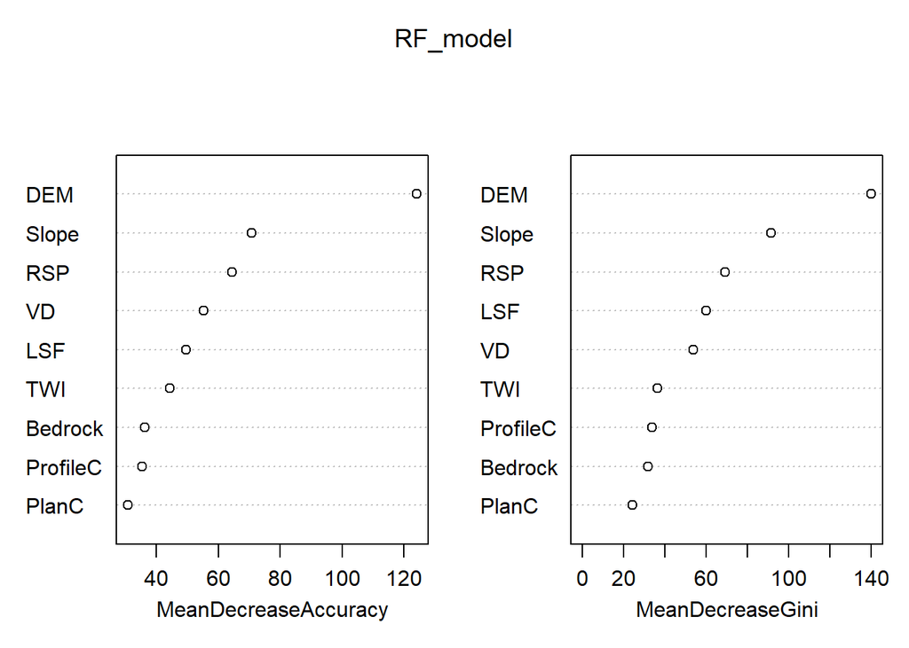

```r
sampleNum_dict[mn]<-nrow(sampData)

sampData$Bedrock<- droplevels(as.factor(sampData$Bedrock))
sampData$soilID<- droplevels(as.factor(sampData$soilID))

RF_model<-randomForest(soilID ~.,data = sampData,
                       importance = TRUE, proximity = FALSE,
                       ntree=1000,type="classification")

varImpPlot(RF_model)
```

```r
print(RF_model)
```

```
##
## Call:
##  randomForest(formula = soilID ~ ., data = sampData, importance = TRUE,      proximity = FALSE, ntree = 1000, type = "classification")
##                Type of random forest: classification
##                      Number of trees: 1000
## No. of variables tried at each split: 3
##
##         OOB estimate of  error rate: 19.81%
## Confusion matrix:
##     1 20 21 23  3 30 31 501 502 503  7 class.error
## 1   3  0  0  0  1  0  0   0   0   0  0  0.25000000
## 20  0 55  5  0  0  0  0   2   0  12 12  0.36046512
## 21  0 10 21  0  0  0  0   1   0   1  0  0.36363636
## 23  0  0  0 42  0  3  2   0   0   6  1  0.22222222
## 3   1  0  0  0 29  0  0   7   0   0  0  0.21621622
## 30  0  0  0  4  0 11  1   0   0   0  0  0.31250000
## 31  0  0  0  1  0  0 24   0   0   0  0  0.04000000
## 501 0  1  0  0  7  0  0 110   0   0  3  0.09090909
## 502 0  2  1  0  0  0  0   0   9   0  2  0.35714286
## 503 0 10  0  4  0  0  0   0   0 134  3  0.11258278
## 7   0 11  0  0  0  1  0   4   0   7 72  0.24210526
```

```r
map_RF <- predict(covStack, RF_model, paste(result_tif_folder,mn,".tif",sep=""),
                  format = "GTiff", datatype = "FLT4S", overwrite = TRUE)

rm("mn","shpPoint","sampData","RF_model","map_RF")
```

RAN Slope ns5 30

```r
mn="All_pRAN_Slope_NS5_pen30"

shpPoint<-readOGR(paste(point_shp_folder,mn,".shp",sep = "")) ###
sampData <- extract(covStack, shpPoint, sp = TRUE,method = "simple")

sampData<-sampData@data

sampData<-sampData[sampData$soilID %in% soil_type,]

sampData<-na.omit(sampData)

print(dim(sampData))
```

```
## [1] 636  10
```

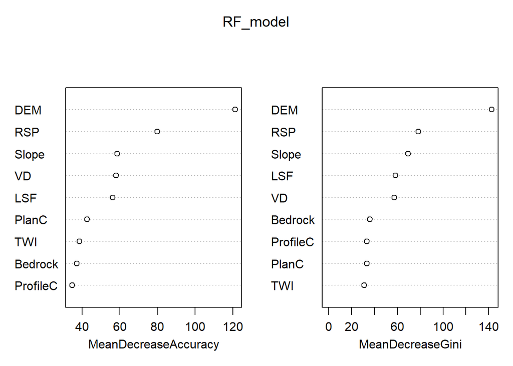

```r
sampleNum_dict[mn]<-nrow(sampData)

sampData$Bedrock<- droplevels(as.factor(sampData$Bedrock))
sampData$soilID<- droplevels(as.factor(sampData$soilID))

RF_model<-randomForest(soilID ~.,data = sampData,
                       importance = TRUE, proximity = FALSE,
                       ntree=1000,type="classification")

varImpPlot(RF_model)
```

```r
print(RF_model)
```

```
##
## Call:
##  randomForest(formula = soilID ~ ., data = sampData, importance = TRUE,      proximity = FALSE, ntree = 1000, type = "classification")
##                Type of random forest: classification
##                      Number of trees: 1000
## No. of variables tried at each split: 3
##
##         OOB estimate of  error rate: 21.54%
## Confusion matrix:
##     1 20 21 23  3 30 31 501 502 503  7 class.error
## 1   4  0  0  0  0  0  0   0   0   0  0  0.00000000
## 20  0 56 10  0  0  0  0   1   2   9  8  0.34883721
## 21  0 18 13  0  0  0  0   0   0   2  0  0.60606061
## 23  0  0  0 38  0  5  2   0   0   6  3  0.29629630
## 3   1  0  0  0 28  0  0   8   0   0  0  0.24324324
## 30  0  0  0  5  0 10  0   0   0   0  1  0.37500000
## 31  0  0  0  3  0  0 22   0   0   0  0  0.12000000
## 501 0  1  0  0  6  0  0 110   1   0  3  0.09090909
## 502 0  3  0  0  0  0  0   3   6   0  2  0.57142857
## 503 0  5  1  4  0  0  0   0   0 136  5  0.09933775
## 7   0  7  0  3  0  0  0   4   0   5 76  0.20000000
```

```r
map_RF <- predict(covStack, RF_model, paste(result_tif_folder,mn,".tif",sep=""),
                  format = "GTiff", datatype = "FLT4S", overwrite = TRUE)

rm("mn","shpPoint","sampData","RF_model","map_RF")
```

SNA Slope ns5 45

```r
mn="All_pSNA_Slope_NS5_pen45"

shpPoint<-readOGR(paste(point_shp_folder,mn,".shp",sep = "")) ###
sampData <- extract(covStack, shpPoint, sp = TRUE,method = "simple")

sampData<-sampData@data

sampData<-sampData[sampData$soilID %in% soil_type,]

sampData<-na.omit(sampData)

print(dim(sampData))
```

```
## [1] 929  10
```

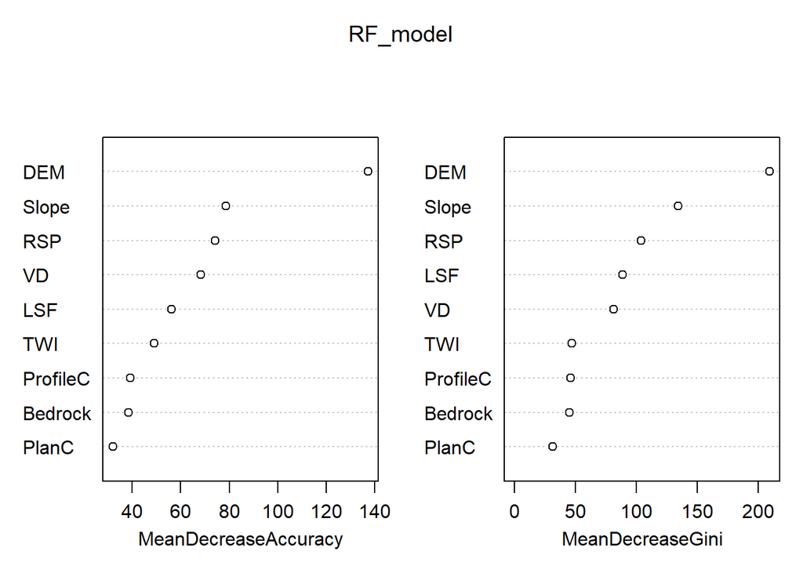

```r
sampleNum_dict[mn]<-nrow(sampData)

sampData$Bedrock<- droplevels(as.factor(sampData$Bedrock))
sampData$soilID<- droplevels(as.factor(sampData$soilID))

RF_model<-randomForest(soilID ~.,data = sampData,
                       importance = TRUE, proximity = FALSE,
                       ntree=1000,type="classification")

varImpPlot(RF_model)
```

```r
print(RF_model)
```

```
##
## Call:
##  randomForest(formula = soilID ~ ., data = sampData, importance = TRUE,      proximity = FALSE, ntree = 1000, type = "classification")
##                Type of random forest: classification
##                      Number of trees: 1000
## No. of variables tried at each split: 3
##
##         OOB estimate of  error rate: 18.51%
## Confusion matrix:
##     1 20 21 23  3 30 31 501 502 503   7 class.error
## 1   1  0  0  0  3  0  0   0   0   0   0  0.75000000
## 20  0 77  8  0  0  0  0   2   0  13  20  0.35833333
## 21  0 12 31  0  0  0  0   1   1   1   1  0.34042553
## 23  0  0  0 61  0  5  2   0   0  10   2  0.23750000
## 3   0  0  0  0 46  0  0   9   0   0   0  0.16363636
## 30  0  0  0  6  0 15  1   0   0   0   0  0.31818182
## 31  0  0  0  1  0  0 36   0   0   0   0  0.02702703
## 501 0  1  0  0  4  0  0 172   0   0   4  0.04972376
## 502 0  4  1  0  0  0  0   0  13   0   2  0.35000000
## 503 0 13  0  8  0  0  0   0   0 197   5  0.11659193
## 7   0 15  0  2  0  1  0   6   0   8 108  0.22857143
```

```r
map_RF <- predict(covStack, RF_model, paste(result_tif_folder,mn,".tif",sep=""),
                  format = "GTiff", datatype = "FLT4S", overwrite = TRUE)

rm("mn","shpPoint","sampData","RF_model","map_RF")
```

RAN Slope ns5 45

```r
mn="All_pRAN_Slope_NS5_pen45"

shpPoint<-readOGR(paste(point_shp_folder,mn,".shp",sep = "")) ###
sampData <- extract(covStack, shpPoint, sp = TRUE,method = "simple")

sampData<-sampData@data

sampData<-sampData[sampData$soilID %in% soil_type,]

sampData<-na.omit(sampData)

print(dim(sampData))
```

```
## [1] 931  10
```

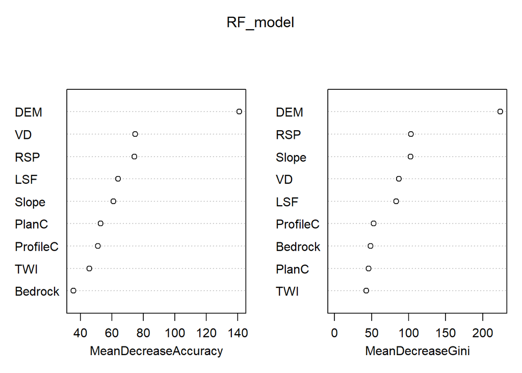

```r
sampleNum_dict[mn]<-nrow(sampData)

sampData$Bedrock<- droplevels(as.factor(sampData$Bedrock))
sampData$soilID<- droplevels(as.factor(sampData$soilID))

RF_model<-randomForest(soilID ~.,data = sampData,
                       importance = TRUE, proximity = FALSE,
                       ntree=1000,type="classification")

varImpPlot(RF_model)
```

```r
print(RF_model)
```

```
##
## Call:
##  randomForest(formula = soilID ~ ., data = sampData, importance = TRUE,      proximity = FALSE, ntree = 1000, type = "classification")
##                Type of random forest: classification
##                      Number of trees: 1000
## No. of variables tried at each split: 3
##
##         OOB estimate of  error rate: 18.05%
## Confusion matrix:
##     1 20 21 23  3 30 31 501 502 503   7 class.error
## 1   3  0  0  0  3  0  0   0   0   0   0  0.50000000
## 20  0 83  6  0  0  0  0   0   3  16  12  0.30833333
## 21  0 17 28  0  0  0  0   0   0   2   0  0.40425532
## 23  0  0  0 54  0  7  3   0   0  13   3  0.32500000
## 3   2  0  0  0 47  0  0   6   0   0   0  0.14545455
## 30  0  0  0  7  0 12  0   0   0   0   3  0.45454545
## 31  0  0  0  2  0  1 34   0   0   0   0  0.08108108
## 501 0  0  0  0  8  0  0 171   0   0   2  0.05524862
## 502 0  3  1  0  0  0  0   4   9   0   3  0.55000000
## 503 0  7  1  8  0  0  0   0   0 201   6  0.09865471
## 7   0  6  0  0  0  1  0   3   1   8 121  0.13571429
```

```r
map_RF <- predict(covStack, RF_model, paste(result_tif_folder,mn,".tif",sep=""),
                  format = "GTiff", datatype = "FLT4S", overwrite = TRUE)

rm("mn","shpPoint","sampData","RF_model","map_RF")
```

SNA Slope ns5 60

```r
mn="All_pSNA_Slope_NS5_pen60"

shpPoint<-readOGR(paste(point_shp_folder,mn,".shp",sep = "")) ###
sampData <- extract(covStack, shpPoint, sp = TRUE,method = "simple")

sampData<-sampData@data

sampData<-sampData[sampData$soilID %in% soil_type,]

sampData<-na.omit(sampData)

print(dim(sampData))
```

```
## [1] 1230   10
```

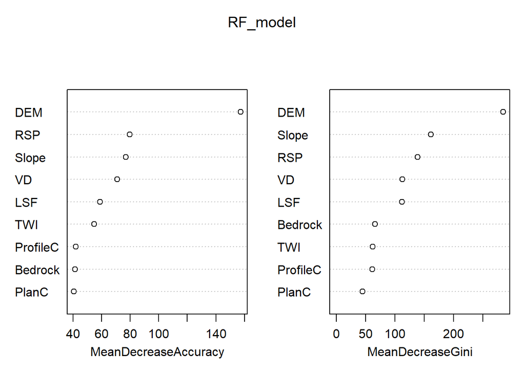

```r
sampleNum_dict[mn]<-nrow(sampData)

sampData$Bedrock<- droplevels(as.factor(sampData$Bedrock))
sampData$soilID<- droplevels(as.factor(sampData$soilID))

RF_model<-randomForest(soilID ~.,data = sampData,
                       importance = TRUE, proximity = FALSE,
                       ntree=1000,type="classification")

varImpPlot(RF_model)
```

```r
print(RF_model)
```

```
##
## Call:
##  randomForest(formula = soilID ~ ., data = sampData, importance = TRUE,      proximity = FALSE, ntree = 1000, type = "classification")
##                Type of random forest: classification
##                      Number of trees: 1000
## No. of variables tried at each split: 3
##
##         OOB estimate of  error rate: 17.15%
## Confusion matrix:
##     1  20 21 23  3 30 31 501 502 503   7 class.error
## 1   4   0  0  0  2  0  0   0   0   0   0  0.33333333
## 20  0 104 12  0  0  0  0   4   0  17  23  0.35000000
## 21  0  22 35  0  0  0  0   1   1   1   0  0.41666667
## 23  0   0  0 83  0  6  2   0   0  12   2  0.20952381
## 3   0   0  0  0 60  0  0  13   0   0   0  0.17808219
## 30  0   0  0  5  0 21  1   0   0   0   2  0.27586207
## 31  0   0  0  0  0  0 50   0   0   0   0  0.00000000
## 501 0   1  0  0  9  0  0 228   0   0   4  0.05785124
## 502 0   2  0  0  0  0  0   0  20   0   4  0.23076923
## 503 0  12  0  7  0  0  0   0   0 268   8  0.09152542
## 7   0  17  0  1  0  1  0   9   0  10 146  0.20652174
```

```r
map_RF <- predict(covStack, RF_model, paste(result_tif_folder,mn,".tif",sep=""),
                  format = "GTiff", datatype = "FLT4S", overwrite = TRUE)

rm("mn","shpPoint","sampData","RF_model","map_RF")
```

RAN Slope ns5 60

```r
mn="All_pRAN_Slope_NS5_pen60"

shpPoint<-readOGR(paste(point_shp_folder,mn,".shp",sep = "")) ###
sampData <- extract(covStack, shpPoint, sp = TRUE,method = "simple")

sampData<-sampData@data

sampData<-sampData[sampData$soilID %in% soil_type,]

sampData<-na.omit(sampData)

print(dim(sampData))
```

```
## [1] 1232   10
```

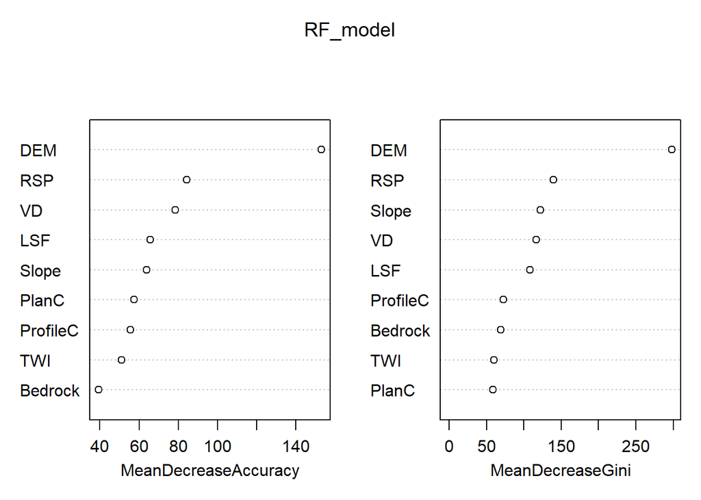

```r
sampleNum_dict[mn]<-nrow(sampData)

sampData$Bedrock<- droplevels(as.factor(sampData$Bedrock))
sampData$soilID<- droplevels(as.factor(sampData$soilID))

RF_model<-randomForest(soilID ~.,data = sampData,
                       importance = TRUE, proximity = FALSE,
                       ntree=1000,type="classification")

varImpPlot(RF_model)
```

```r
print(RF_model)
```

```
##
## Call:
##  randomForest(formula = soilID ~ ., data = sampData, importance = TRUE,      proximity = FALSE, ntree = 1000, type = "classification")
##                Type of random forest: classification
##                      Number of trees: 1000
## No. of variables tried at each split: 3
##
##         OOB estimate of  error rate: 16.15%
## Confusion matrix:
##     1  20 21 23  3 30 31 501 502 503   7 class.error
## 1   6   0  0  0  2  0  0   0   0   0   0  0.25000000
## 20  0 113 10  0  0  0  0   1   3  18  15  0.29375000
## 21  0  22 34  0  0  0  0   0   0   4   0  0.43333333
## 23  0   0  0 79  0  6  3   0   0  10   7  0.24761905
## 3   1   0  0  0 65  0  0   7   0   0   0  0.10958904
## 30  0   0  0  3  0 24  0   0   0   0   2  0.17241379
## 31  0   0  0  1  0  0 49   0   0   0   0  0.02000000
## 501 0   1  0  0 10  0  0 228   0   0   3  0.05785124
## 502 0   6  0  0  0  0  0   3  14   0   3  0.46153846
## 503 0   9  2 10  0  0  0   0   0 268   6  0.09152542
## 7   0  13  0  3  0  1  0   3   1  10 153  0.16847826
```

```r
map_RF <- predict(covStack, RF_model, paste(result_tif_folder,mn,".tif",sep=""),
                  format = "GTiff", datatype = "FLT4S", overwrite = TRUE)

rm("mn","shpPoint","sampData","RF_model","map_RF")
```

SNA Slope ns5 75

```r
mn="All_pSNA_Slope_NS5_pen75"

shpPoint<-readOGR(paste(point_shp_folder,mn,".shp",sep = "")) ###
sampData <- extract(covStack, shpPoint, sp = TRUE,method = "simple")

sampData<-sampData@data

sampData<-sampData[sampData$soilID %in% soil_type,]

sampData<-na.omit(sampData)

print(dim(sampData))
```

```
## [1] 1528   10
```

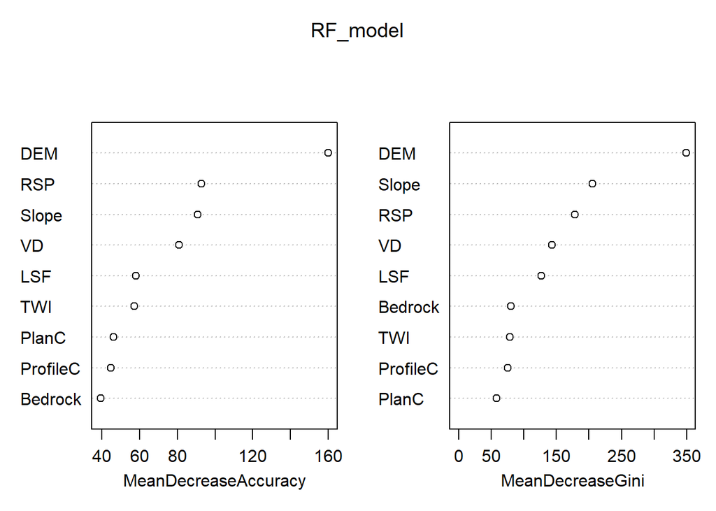

```r
sampleNum_dict[mn]<-nrow(sampData)

sampData$Bedrock<- droplevels(as.factor(sampData$Bedrock))
sampData$soilID<- droplevels(as.factor(sampData$soilID))

RF_model<-randomForest(soilID ~.,data = sampData,
                       importance = TRUE, proximity = FALSE,
                       ntree=1000,type="classification")

varImpPlot(RF_model)
```

```r
print(RF_model)
```

```
##
## Call:
##  randomForest(formula = soilID ~ ., data = sampData, importance = TRUE,      proximity = FALSE, ntree = 1000, type = "classification")
##                Type of random forest: classification
##                      Number of trees: 1000
## No. of variables tried at each split: 3
##
##         OOB estimate of  error rate: 17.74%
## Confusion matrix:
##     1  20 21  23  3 30 31 501 502 503   7 class.error
## 1   6   0  0   0  2  0  0   0   0   0   0  0.25000000
## 20  0 127 17   0  0  0  0   4   0  25  25  0.35858586
## 21  0  26 43   0  0  0  0   1   1   1   0  0.40277778
## 23  0   0  0 101  0  9  2   0   0  15   5  0.23484848
## 3   0   0  0   0 76  0  0  15   0   0   0  0.16483516
## 30  0   0  0   7  0 28  1   0   0   0   1  0.24324324
## 31  0   0  0   2  0  1 59   0   0   0   0  0.04838710
## 501 0   1  0   0 13  0  0 282   0   0   5  0.06312292
## 502 0   5  0   0  0  0  0   0  25   0   2  0.21875000
## 503 0  18  2  10  0  0  0   0   0 329   9  0.10597826
## 7   0  21  0   1  0  1  0   9   0  14 181  0.20264317
```

```r
map_RF <- predict(covStack, RF_model, paste(result_tif_folder,mn,".tif",sep=""),
                  format = "GTiff", datatype = "FLT4S", overwrite = TRUE)

rm("mn","shpPoint","sampData","RF_model","map_RF")
```

RAN Slope ns5 75

```r
mn="All_pRAN_Slope_NS5_pen75"

shpPoint<-readOGR(paste(point_shp_folder,mn,".shp",sep = "")) ###
sampData <- extract(covStack, shpPoint, sp = TRUE,method = "simple")

sampData<-sampData@data

sampData<-sampData[sampData$soilID %in% soil_type,]

sampData<-na.omit(sampData)

print(dim(sampData))
```

```
## [1] 1530   10
```

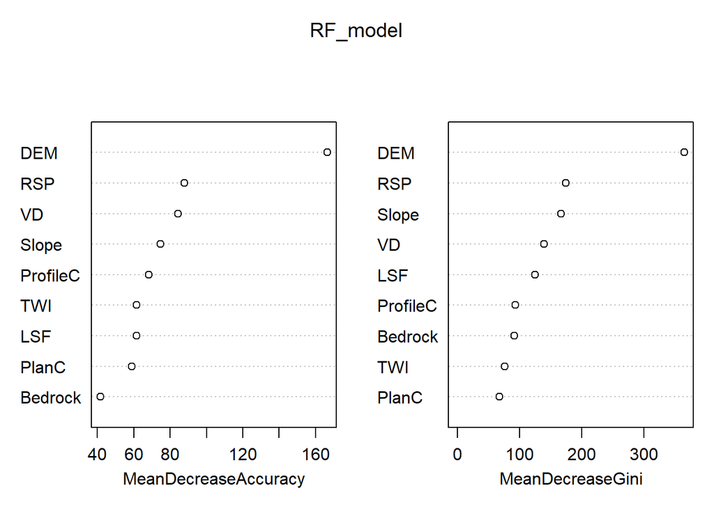

```r
sampleNum_dict[mn]<-nrow(sampData)

sampData$Bedrock<- droplevels(as.factor(sampData$Bedrock))
sampData$soilID<- droplevels(as.factor(sampData$soilID))

RF_model<-randomForest(soilID ~.,data = sampData,
                       importance = TRUE, proximity = FALSE,
                       ntree=1000,type="classification")

varImpPlot(RF_model)
```

```r
print(RF_model)
```

```
##
## Call:
##  randomForest(formula = soilID ~ ., data = sampData, importance = TRUE,      proximity = FALSE, ntree = 1000, type = "classification")
##                Type of random forest: classification
##                      Number of trees: 1000
## No. of variables tried at each split: 3
##
##         OOB estimate of  error rate: 13.79%
## Confusion matrix:
##     1  20 21  23  3 30 31 501 502 503   7 class.error
## 1   9   0  0   0  1  0  0   0   0   0   0  0.10000000
## 20  0 153  3   0  0  0  0   2   1  21  18  0.22727273
## 21  0  21 48   0  0  0  0   0   1   2   0  0.33333333
## 23  0   0  0 107  0  8  2   0   0   9   6  0.18939394
## 3   1   0  0   0 79  0  0  11   0   0   0  0.13186813
## 30  0   0  0   5  0 29  1   0   0   0   2  0.21621622
## 31  0   0  0   3  0  1 58   0   0   0   0  0.06451613
## 501 0   3  0   0 12  0  0 283   0   0   3  0.05980066
## 502 0   5  0   0  0  0  0   2  23   0   2  0.28125000
## 503 0  11  2  10  0  0  0   0   0 336   9  0.08695652
## 7   0   8  0   3  0  2  0   6   2  12 194  0.14537445
```

```r
map_RF <- predict(covStack, RF_model, paste(result_tif_folder,mn,".tif",sep=""),
                  format = "GTiff", datatype = "FLT4S", overwrite = TRUE)

rm("mn","shpPoint","sampData","RF_model","map_RF")
```

# PlanC

SNA PlanC ns3 15

```r
mn="All_pSNA_PlanC_NS3_pen15"

shpPoint<-readOGR(paste(point_shp_folder,mn,".shp",sep = "")) ###
sampData <- extract(covStack, shpPoint, sp = TRUE,method = "simple")

sampData<-sampData@data

sampData<-sampData[sampData$soilID %in% soil_type,]

sampData<-na.omit(sampData)

print(dim(sampData))
```

```
## [1] 1011   10
```

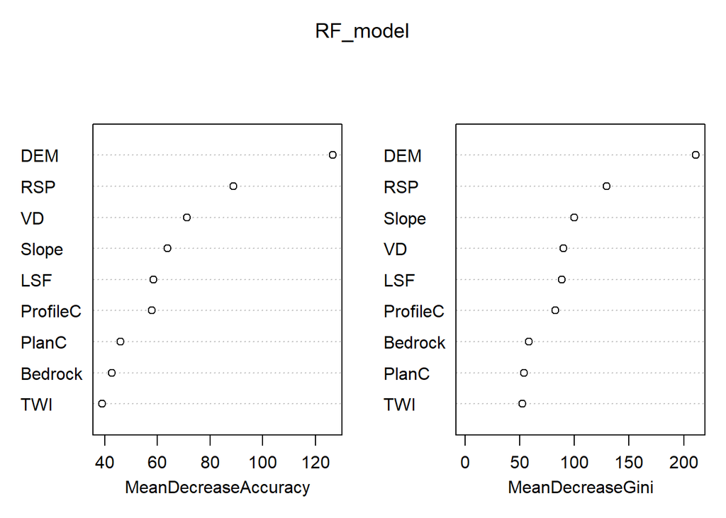

```r
sampleNum_dict[mn]<-nrow(sampData)

sampData$Bedrock<- droplevels(as.factor(sampData$Bedrock))
sampData$soilID<- droplevels(as.factor(sampData$soilID))

RF_model<-randomForest(soilID ~.,data = sampData,
                       importance = TRUE, proximity = FALSE,
                       ntree=1000,type="classification")

varImpPlot(RF_model)
```

```r
print(RF_model)
```

```
##
## Call:
##  randomForest(formula = soilID ~ ., data = sampData, importance = TRUE,      proximity = FALSE, ntree = 1000, type = "classification")
##                Type of random forest: classification
##                      Number of trees: 1000
## No. of variables tried at each split: 3
##
##         OOB estimate of  error rate: 22.16%
## Confusion matrix:
##     1 20 21 23  3 30 31 501 502 503   7 class.error
## 1   4  0  0  0  2  0  0   0   0   0   0  0.33333333
## 20  0 95 17  0  0  0  0   1   0  24  19  0.39102564
## 21  0 26 31  0  0  0  0   0   0   2   0  0.47457627
## 23  0  0  0 88  0  3  1   0   0   8   0  0.12000000
## 3   1  0  0  0 41  0  0   9   0   0   0  0.19607843
## 30  0  0  0  5  0 23  1   0   0   2   2  0.30303030
## 31  0  0  0  7  0  1 34   0   0   0   0  0.19047619
## 501 0  2  0  0  7  0  0 150   0   0   6  0.09090909
## 502 0  2  0  0  0  0  0   2   9   0   8  0.57142857
## 503 0 24  1  7  0  2  0   0   0 193   6  0.17167382
## 7   0 10  0  0  0  2  0   6   3   5 119  0.17931034
```

```r
map_RF <- predict(covStack, RF_model, paste(result_tif_folder,mn,".tif",sep=""),
                  format = "GTiff", datatype = "FLT4S", overwrite = TRUE)

rm("mn","shpPoint","sampData","RF_model","map_RF")
```

RAN PlanC ns3 15

```r
mn="All_pRAN_PlanC_NS3_pen15"

shpPoint<-readOGR(paste(point_shp_folder,mn,".shp",sep = "")) ###
sampData <- extract(covStack, shpPoint, sp = TRUE,method = "simple")

sampData<-sampData@data

sampData<-sampData[sampData$soilID %in% soil_type,]

sampData<-na.omit(sampData)

print(dim(sampData))
```

```
## [1] 1011   10
```

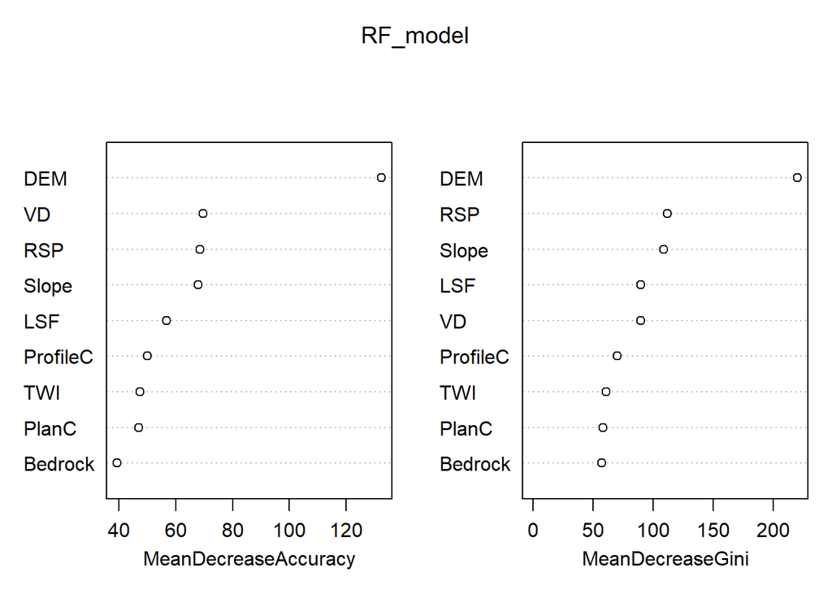

```r
sampleNum_dict[mn]<-nrow(sampData)

sampData$Bedrock<- droplevels(as.factor(sampData$Bedrock))
sampData$soilID<- droplevels(as.factor(sampData$soilID))

RF_model<-randomForest(soilID ~.,data = sampData,
                       importance = TRUE, proximity = FALSE,
                       ntree=1000,type="classification")

varImpPlot(RF_model)
```

```r
print(RF_model)
```

```
##
## Call:
##  randomForest(formula = soilID ~ ., data = sampData, importance = TRUE,      proximity = FALSE, ntree = 1000, type = "classification")
##                Type of random forest: classification
##                      Number of trees: 1000
## No. of variables tried at each split: 3
##
##         OOB estimate of  error rate: 25.52%
## Confusion matrix:
##     1 20 21 23  3 30 31 501 502 503   7 class.error
## 1   5  0  0  0  1  0  0   0   0   0   0   0.1666667
## 20  0 92 19  0  0  1  0   1   0  28  15   0.4102564
## 21  0 18 37  0  0  0  0   0   0   4   0   0.3728814
## 23  0  0  0 75  0  7  3   0   0  12   3   0.2500000
## 3   0  0  0  0 39  0  0  12   0   0   0   0.2352941
## 30  0  0  0 10  0 16  4   0   0   1   2   0.5151515
## 31  0  0  0  6  0  3 33   0   0   0   0   0.2142857
## 501 0  1  0  0 11  0  0 145   0   0   8   0.1212121
## 502 0  4  2  0  0  0  0   3  11   1   0   0.4761905
## 503 0 19  1 10  0  1  0   0   2 192   8   0.1759657
## 7   0 14  0  0  0  1  0   9   1  12 108   0.2551724
```

```r
map_RF <- predict(covStack, RF_model, paste(result_tif_folder,mn,".tif",sep=""),
                  format = "GTiff", datatype = "FLT4S", overwrite = TRUE)

rm("mn","shpPoint","sampData","RF_model","map_RF")
```

SNA PlanC ns3 30

```r
mn="All_pSNA_PlanC_NS3_pen30"

shpPoint<-readOGR(paste(point_shp_folder,mn,".shp",sep = "")) ###
sampData <- extract(covStack, shpPoint, sp = TRUE,method = "simple")

sampData<-sampData@data

sampData<-sampData[sampData$soilID %in% soil_type,]

sampData<-na.omit(sampData)

print(dim(sampData))
```

```
## [1] 1973   10
```

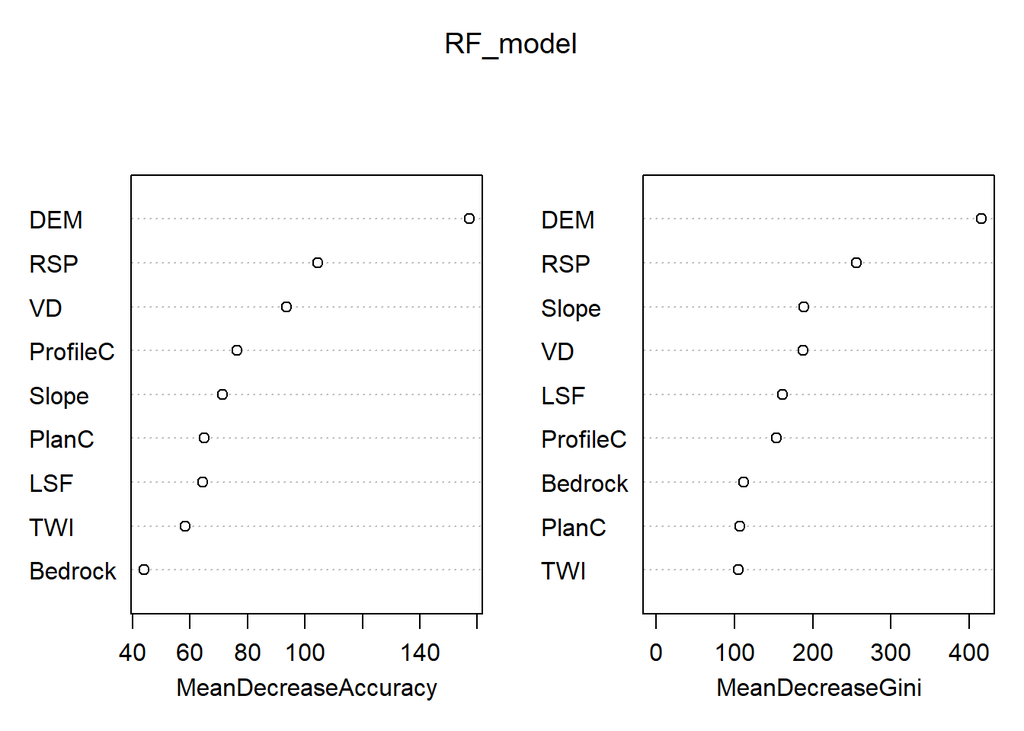

```r
sampleNum_dict[mn]<-nrow(sampData)

sampData$Bedrock<- droplevels(as.factor(sampData$Bedrock))
sampData$soilID<- droplevels(as.factor(sampData$soilID))

RF_model<-randomForest(soilID ~.,data = sampData,
                       importance = TRUE, proximity = FALSE,
                       ntree=1000,type="classification")

varImpPlot(RF_model)
```

```r
print(RF_model)
```

```
##
## Call:
##  randomForest(formula = soilID ~ ., data = sampData, importance = TRUE,      proximity = FALSE, ntree = 1000, type = "classification")
##                Type of random forest: classification
##                      Number of trees: 1000
## No. of variables tried at each split: 3
##
##         OOB estimate of  error rate: 19.67%
## Confusion matrix:
##     1  20 21  23  3 30 31 501 502 503   7 class.error
## 1   9   0  0   0  1  0  0   0   0   0   0  0.10000000
## 20  0 199 26   0  0  0  0   3   2  46  27  0.34323432
## 21  0  42 55   0  0  0  0   2   1  11   1  0.50892857
## 23  0   0  0 156  0  4  5   0   0  23   1  0.17460317
## 3   1   0  0   0 81  0  0  19   0   0   0  0.19801980
## 30  0   0  0   8  0 49  1   0   0   1   4  0.22222222
## 31  0   0  0   6  0  1 77   0   0   0   0  0.08333333
## 501 0   1  1   0 12  0  0 305   1   0  10  0.07575758
## 502 0   4  1   0  0  0  0   2  25   1   7  0.37500000
## 503 0  40  1  15  0  3  0   0   0 392   9  0.14782609
## 7   0  16  0   0  0  2  0  12   1  13 237  0.15658363
```

```r
map_RF <- predict(covStack, RF_model, paste(result_tif_folder,mn,".tif",sep=""),
                  format = "GTiff", datatype = "FLT4S", overwrite = TRUE)

rm("mn","shpPoint","sampData","RF_model","map_RF")
```

RAN PlanC ns3 30

```r
mn="All_pRAN_PlanC_NS3_pen30"

shpPoint<-readOGR(paste(point_shp_folder,mn,".shp",sep = "")) ###
sampData <- extract(covStack, shpPoint, sp = TRUE,method = "simple")

sampData<-sampData@data

sampData<-sampData[sampData$soilID %in% soil_type,]

sampData<-na.omit(sampData)

print(dim(sampData))
```

```
## [1] 1973   10
```

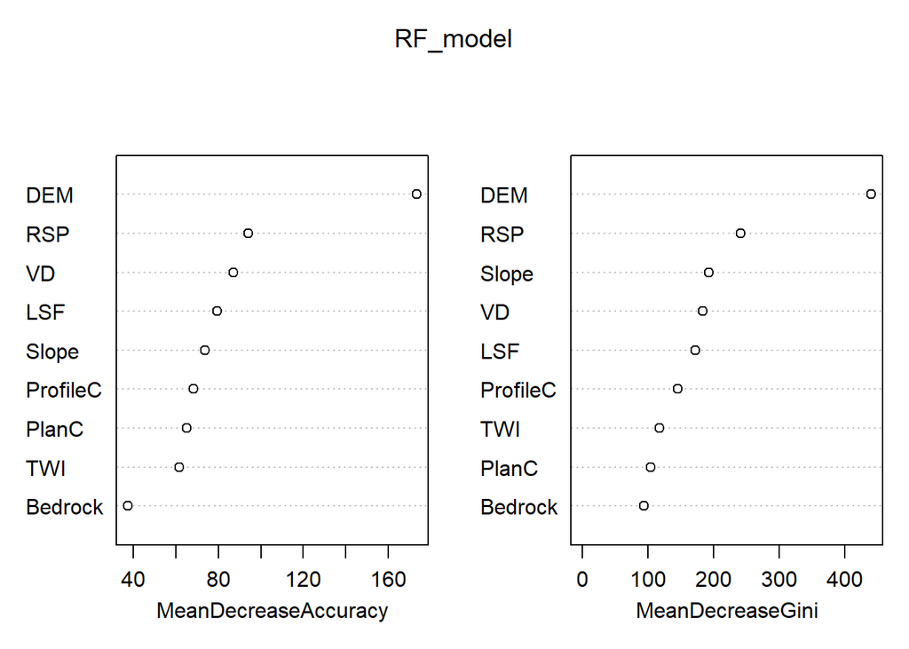

```r
sampleNum_dict[mn]<-nrow(sampData)

sampData$Bedrock<- droplevels(as.factor(sampData$Bedrock))
sampData$soilID<- droplevels(as.factor(sampData$soilID))

RF_model<-randomForest(soilID ~.,data = sampData,
                       importance = TRUE, proximity = FALSE,
                       ntree=1000,type="classification")

varImpPlot(RF_model)
```

```r
print(RF_model)
```

```
##
## Call:
##  randomForest(formula = soilID ~ ., data = sampData, importance = TRUE,      proximity = FALSE, ntree = 1000, type = "classification")
##                Type of random forest: classification
##                      Number of trees: 1000
## No. of variables tried at each split: 3
##
##         OOB estimate of  error rate: 22.05%
## Confusion matrix:
##     1  20 21  23  3 30 31 501 502 503   7 class.error
## 1   9   0  0   0  1  0  0   0   0   0   0  0.10000000
## 20  0 190 34   0  0  0  0   5   0  48  26  0.37293729
## 21  0  43 60   0  0  0  0   0   0   9   0  0.46428571
## 23  0   0  0 137  0 15  3   0   0  27   7  0.27513228
## 3   0   0  0   0 77  0  0  24   0   0   0  0.23762376
## 30  0   0  0  10  0 47  4   0   0   0   2  0.25396825
## 31  0   0  0   8  0  5 70   0   0   1   0  0.16666667
## 501 0   1  0   0 15  0  0 305   1   0   8  0.07575758
## 502 0   4  1   0  0  0  0   5  27   1   2  0.32500000
## 503 0  30  4  20  0  1  1   0   1 394   9  0.14347826
## 7   0  23  0   4  0  1  0  16   1  14 222  0.20996441
```

```r
map_RF <- predict(covStack, RF_model, paste(result_tif_folder,mn,".tif",sep=""),
                  format = "GTiff", datatype = "FLT4S", overwrite = TRUE)

rm("mn","shpPoint","sampData","RF_model","map_RF")
```

SNA PlanC ns3 45

```r
mn="All_pSNA_PlanC_NS3_pen45"

shpPoint<-readOGR(paste(point_shp_folder,mn,".shp",sep = "")) ###
sampData <- extract(covStack, shpPoint, sp = TRUE,method = "simple")

sampData<-sampData@data

sampData<-sampData[sampData$soilID %in% soil_type,]

sampData<-na.omit(sampData)

print(dim(sampData))
```

```
## [1] 2937   10
```

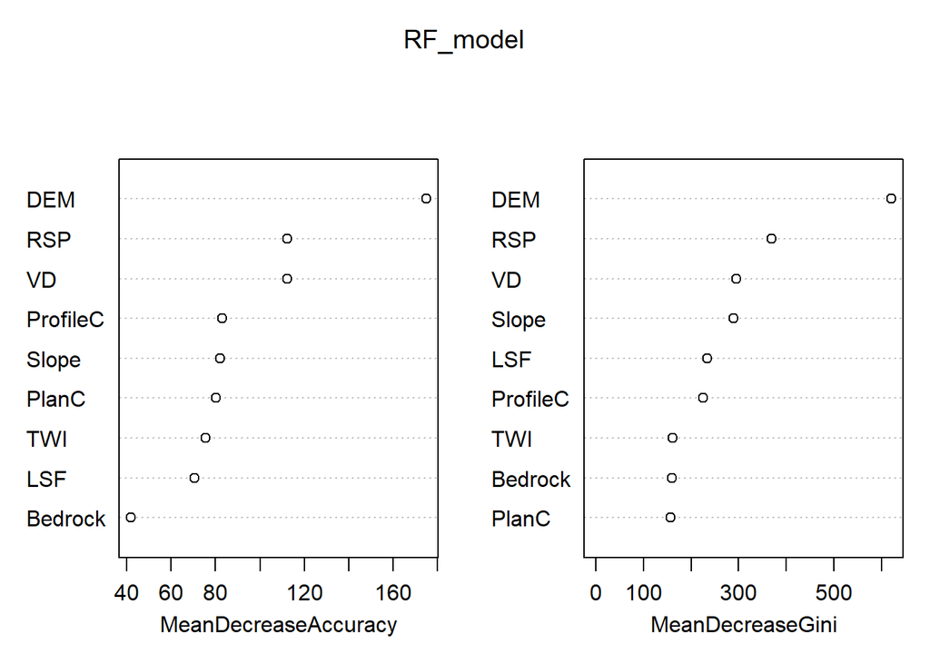

```r
sampleNum_dict[mn]<-nrow(sampData)

sampData$Bedrock<- droplevels(as.factor(sampData$Bedrock))
sampData$soilID<- droplevels(as.factor(sampData$soilID))

RF_model<-randomForest(soilID ~.,data = sampData,
                       importance = TRUE, proximity = FALSE,
                       ntree=1000,type="classification")

varImpPlot(RF_model)
```

```r
print(RF_model)
```

```
##
## Call:
##  randomForest(formula = soilID ~ ., data = sampData, importance = TRUE,      proximity = FALSE, ntree = 1000, type = "classification")
##                Type of random forest: classification
##                      Number of trees: 1000
## No. of variables tried at each split: 3
##
##         OOB estimate of  error rate: 19.78%
## Confusion matrix:
##      1  20 21  23   3 30  31 501 502 503   7 class.error
## 1   13   0  0   0   2  0   0   0   0   0   0  0.13333333
## 20   0 299 27   0   0  0   0   5   2  72  45  0.33555556
## 21   0  63 85   0   0  0   0   2   0  14   1  0.48484848
## 23   0   0  0 224   0 11   6   0   0  36   4  0.20284698
## 3    2   0  0   0 114  0   0  36   0   0   0  0.25000000
## 30   0   0  0   9   0 73   2   0   0   1   6  0.19780220
## 31   0   0  0   5   0  1 119   0   0   0   0  0.04800000
## 501  0   1  1   0  27  0   0 449   1   0  14  0.08924949
## 502  0   2  1   0   0  0   0   2  46   1   6  0.20689655
## 503  0  53  2  20   0  2   0   0   1 593  17  0.13808140
## 7    0  32  0   0   0  3   0  23   1  19 341  0.18615752
```

```r
map_RF <- predict(covStack, RF_model, paste(result_tif_folder,mn,".tif",sep=""),
                  format = "GTiff", datatype = "FLT4S", overwrite = TRUE)

rm("mn","shpPoint","sampData","RF_model","map_RF")
```

RAN PlanC ns3 45

```r
mn="All_pRAN_PlanC_NS3_pen45"

shpPoint<-readOGR(paste(point_shp_folder,mn,".shp",sep = "")) ###
sampData <- extract(covStack, shpPoint, sp = TRUE,method = "simple")

sampData<-sampData@data

sampData<-sampData[sampData$soilID %in% soil_type,]

sampData<-na.omit(sampData)

print(dim(sampData))
```

```
## [1] 2937   10
```

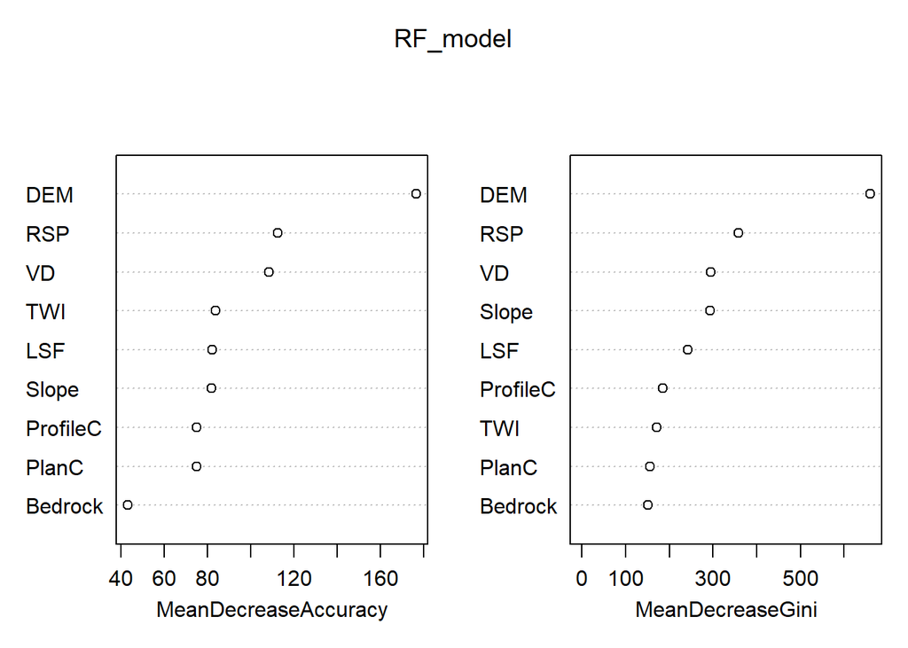

```r
sampleNum_dict[mn]<-nrow(sampData)

sampData$Bedrock<- droplevels(as.factor(sampData$Bedrock))
sampData$soilID<- droplevels(as.factor(sampData$soilID))

RF_model<-randomForest(soilID ~.,data = sampData,
                       importance = TRUE, proximity = FALSE,
                       ntree=1000,type="classification")

varImpPlot(RF_model)
```

```r
print(RF_model)
```

```
##
## Call:
##  randomForest(formula = soilID ~ ., data = sampData, importance = TRUE,      proximity = FALSE, ntree = 1000, type = "classification")
##                Type of random forest: classification
##                      Number of trees: 1000
## No. of variables tried at each split: 3
##
##         OOB estimate of  error rate: 18.05%
## Confusion matrix:
##      1  20  21  23   3 30  31 501 502 503   7 class.error
## 1   14   0   0   0   1  0   0   0   0   0   0  0.06666667
## 20   0 322  28   1   0  0   0   2   3  63  31  0.28444444
## 21   0  42 109   0   0  0   0   0   2  11   1  0.33939394
## 23   0   0   0 220   0 13   7   0   0  33   8  0.21708185
## 3    2   0   0   0 115  0   0  35   0   0   0  0.24342105
## 30   0   0   0  13   0 72   4   0   0   1   1  0.20879121
## 31   0   0   0  11   0  6 107   0   0   1   0  0.14400000
## 501  0   4   0   0  23  0   0 455   1   0  10  0.07707911
## 502  0   0   2   0   0  0   0   2  50   1   3  0.13793103
## 503  0  47   4  29   0  1   1   0   2 587  17  0.14680233
## 7    0  17   1   4   0  3   0  16   2  20 356  0.15035800
```

```r
map_RF <- predict(covStack, RF_model, paste(result_tif_folder,mn,".tif",sep=""),
                  format = "GTiff", datatype = "FLT4S", overwrite = TRUE)

rm("mn","shpPoint","sampData","RF_model","map_RF")
```

SNA PlanC ns3 60

```r
mn="All_pSNA_PlanC_NS3_pen60"

shpPoint<-readOGR(paste(point_shp_folder,mn,".shp",sep = "")) ###
sampData <- extract(covStack, shpPoint, sp = TRUE,method = "simple")

sampData<-sampData@data

sampData<-sampData[sampData$soilID %in% soil_type,]

sampData<-na.omit(sampData)

print(dim(sampData))
```

```
## [1] 3909   10
```

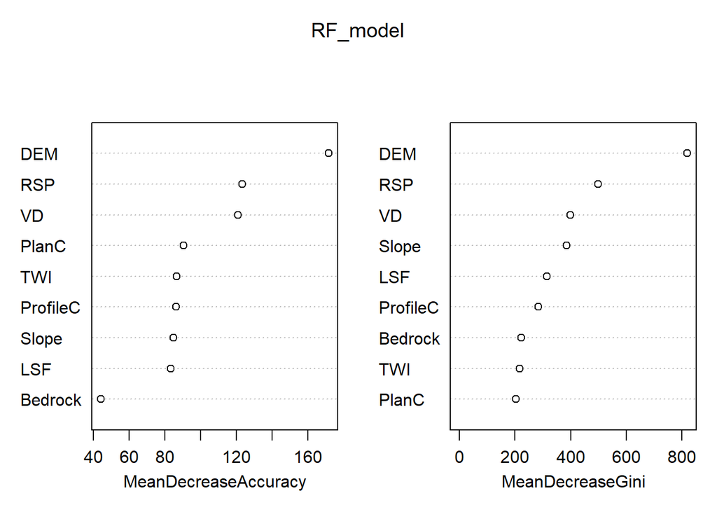

```r
sampleNum_dict[mn]<-nrow(sampData)

sampData$Bedrock<- droplevels(as.factor(sampData$Bedrock))
sampData$soilID<- droplevels(as.factor(sampData$soilID))

RF_model<-randomForest(soilID ~.,data = sampData,
                       importance = TRUE, proximity = FALSE,
                       ntree=1000,type="classification")

varImpPlot(RF_model)
```

```r
print(RF_model)
```

```
##
## Call:
##  randomForest(formula = soilID ~ ., data = sampData, importance = TRUE,      proximity = FALSE, ntree = 1000, type = "classification")
##                Type of random forest: classification
##                      Number of trees: 1000
## No. of variables tried at each split: 3
##
##         OOB estimate of  error rate: 18.73%
## Confusion matrix:
##      1  20  21  23   3 30  31 501 502 503   7 class.error
## 1   17   0   0   0   4  0   0   0   0   0   0  0.19047619
## 20   0 405  28   0   0  0   0   6   2  97  60  0.32274247
## 21   0  73 122   0   0  0   0   1   1  21   0  0.44036697
## 23   0   0   0 301   0 18   6   0   0  39   8  0.19086022
## 3    3   0   0   0 154  0   0  45   0   0   0  0.23762376
## 30   0   0   0  12   0 97   4   0   0   2   7  0.20491803
## 31   0   0   0   7   0  3 157   0   0   0   0  0.05988024
## 501  0   3   1   0  31  0   0 604   1   0  18  0.08206687
## 502  0   3   0   0   0  0   0   2  63   2   7  0.18181818
## 503  0  66   2  22   0  3   0   0   1 800  22  0.12663755
## 7    0  34   0   0   0  5   0  35   1  26 457  0.18100358
```

```r
map_RF <- predict(covStack, RF_model, paste(result_tif_folder,mn,".tif",sep=""),
                  format = "GTiff", datatype = "FLT4S", overwrite = TRUE)

rm("mn","shpPoint","sampData","RF_model","map_RF")
```

RAN PlanC ns3 60

```r
mn="All_pRAN_PlanC_NS3_pen60"

shpPoint<-readOGR(paste(point_shp_folder,mn,".shp",sep = "")) ###
sampData <- extract(covStack, shpPoint, sp = TRUE,method = "simple")

sampData<-sampData@data

sampData<-sampData[sampData$soilID %in% soil_type,]

sampData<-na.omit(sampData)

print(dim(sampData))
```

```
## [1] 3908   10
```

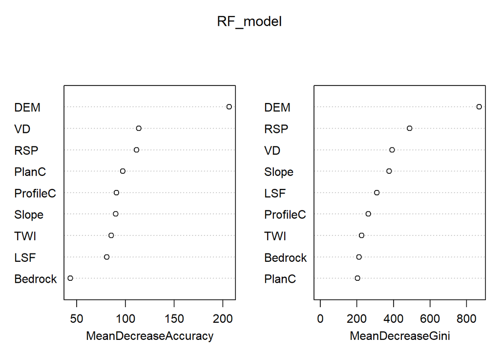

```r
sampleNum_dict[mn]<-nrow(sampData)

sampData$Bedrock<- droplevels(as.factor(sampData$Bedrock))
sampData$soilID<- droplevels(as.factor(sampData$soilID))

RF_model<-randomForest(soilID ~.,data = sampData,
                       importance = TRUE, proximity = FALSE,
                       ntree=1000,type="classification")

varImpPlot(RF_model)
```

```r
print(RF_model)
```

```
##
## Call:
##  randomForest(formula = soilID ~ ., data = sampData, importance = TRUE,      proximity = FALSE, ntree = 1000, type = "classification")
##                Type of random forest: classification
##                      Number of trees: 1000
## No. of variables tried at each split: 3
##
##         OOB estimate of  error rate: 18.4%
## Confusion matrix:
##      1  20  21  23   3 30  31 501 502 503   7 class.error
## 1   18   0   0   0   2  0   0   0   0   0   0  0.10000000
## 20   0 418  35   2   0  0   0   6   4  89  44  0.30100334
## 21   0  67 139   0   0  0   0   1   0   9   2  0.36238532
## 23   0   1   0 297   0 17   7   0   0  39  11  0.20161290
## 3    2   0   0   0 153  0   0  47   0   0   0  0.24257426
## 30   0   0   0  18   0 93   7   0   0   2   2  0.23770492
## 31   0   0   0  19   0  6 142   0   0   0   0  0.14970060
## 501  0   4   0   0  32  0   0 603   0   0  19  0.08358663
## 502  0   4   1   0   0  0   0   1  64   1   6  0.16883117
## 503  0  69   3  29   0  1   0   0   1 797  16  0.12991266
## 7    0  41   0   3   0  4   0  22   4  19 465  0.16666667
```

```r
map_RF <- predict(covStack, RF_model, paste(result_tif_folder,mn,".tif",sep=""),
                  format = "GTiff", datatype = "FLT4S", overwrite = TRUE)

rm("mn","shpPoint","sampData","RF_model","map_RF")
```

SNA PlanC ns3 75

```r
mn="All_pSNA_PlanC_NS3_pen75"

shpPoint<-readOGR(paste(point_shp_folder,mn,".shp",sep = "")) ###
sampData <- extract(covStack, shpPoint, sp = TRUE,method = "simple")

sampData<-sampData@data

sampData<-sampData[sampData$soilID %in% soil_type,]

sampData<-na.omit(sampData)

print(dim(sampData))
```

```
## [1] 4877   10
```

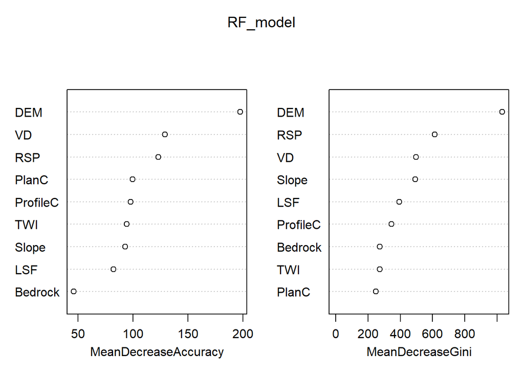

```r
sampleNum_dict[mn]<-nrow(sampData)

sampData$Bedrock<- droplevels(as.factor(sampData$Bedrock))
sampData$soilID<- droplevels(as.factor(sampData$soilID))

RF_model<-randomForest(soilID ~.,data = sampData,
                       importance = TRUE, proximity = FALSE,
                       ntree=1000,type="classification")

varImpPlot(RF_model)
```

```r
print(RF_model)
```

```
##
## Call:
##  randomForest(formula = soilID ~ ., data = sampData, importance = TRUE,      proximity = FALSE, ntree = 1000, type = "classification")
##                Type of random forest: classification
##                      Number of trees: 1000
## No. of variables tried at each split: 3
##
##         OOB estimate of  error rate: 18.95%
## Confusion matrix:
##      1  20  21  23   3  30  31 501 502 503   7 class.error
## 1   22   0   0   0   4   0   0   0   0   0   0  0.15384615
## 20   0 509  48   0   0   0   0   7   2 107  72  0.31677852
## 21   0  86 161   0   0   0   0   2   1  22   1  0.41025641
## 23   0   0   0 364   0  26   7   0   0  54  12  0.21382289
## 3    3   0   0   0 184   0   0  64   0   0   0  0.26693227
## 30   0   0   0  18   0 122   3   0   0   2   6  0.19205298
## 31   0   0   0   9   0   7 191   0   0   1   0  0.08173077
## 501  0   3   0   0  38   0   0 764   1   0  17  0.07168894
## 502  0   4   0   0   0   0   0   3  81   1   7  0.15625000
## 503  0  79   3  34   0   3   0   0   2 995  30  0.13176265
## 7    0  46   1   3   0   6   0  45   3  31 560  0.19424460
```

```r
map_RF <- predict(covStack, RF_model, paste(result_tif_folder,mn,".tif",sep=""),
                  format = "GTiff", datatype = "FLT4S", overwrite = TRUE)

rm("mn","shpPoint","sampData","RF_model","map_RF")
```

RAN PlanC ns3 75

```r
mn="All_pRAN_PlanC_NS3_pen75"

shpPoint<-readOGR(paste(point_shp_folder,mn,".shp",sep = "")) ###
sampData <- extract(covStack, shpPoint, sp = TRUE,method = "simple")

sampData<-sampData@data

sampData<-sampData[sampData$soilID %in% soil_type,]

sampData<-na.omit(sampData)

print(dim(sampData))
```

```
## [1] 4875   10
```

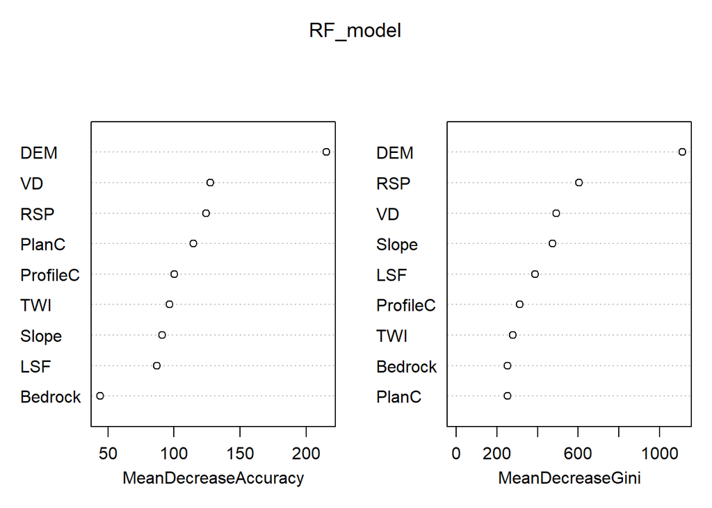

```r
sampleNum_dict[mn]<-nrow(sampData)

sampData$Bedrock<- droplevels(as.factor(sampData$Bedrock))
sampData$soilID<- droplevels(as.factor(sampData$soilID))

RF_model<-randomForest(soilID ~.,data = sampData,
                       importance = TRUE, proximity = FALSE,
                       ntree=1000,type="classification")

varImpPlot(RF_model)
```

```r
print(RF_model)
```

```
##
## Call:
##  randomForest(formula = soilID ~ ., data = sampData, importance = TRUE,      proximity = FALSE, ntree = 1000, type = "classification")
##                Type of random forest: classification
##                      Number of trees: 1000
## No. of variables tried at each split: 3
##
##         OOB estimate of  error rate: 15.73%
## Confusion matrix:
##      1  20  21  23   3  30  31 501 502  503   7 class.error
## 1   20   0   0   0   4   0   0   0   0    0   0  0.16666667
## 20   0 560  40   2   0   0   0   5   3   96  39  0.24832215
## 21   0  65 193   0   0   0   0   2   1   11   1  0.29304029
## 23   0   2   0 373   0  18  10   0   0   45  15  0.19438445
## 3    2   0   0   0 200   0   0  49   0    0   0  0.20318725
## 30   0   0   0  15   0 123   7   0   0    1   5  0.18543046
## 31   0   0   0  16   0   7 184   0   0    1   0  0.11538462
## 501  0   4   0   0  36   0   0 763   2    0  18  0.07290401
## 502  0   2   1   0   0   0   0   1  87    1   4  0.09375000
## 503  0  68   3  29   0   2   0   0   3 1014  27  0.11518325
## 7    0  39   0   2   0   6   0  28   2   27 591  0.14964029
```

```r
map_RF <- predict(covStack, RF_model, paste(result_tif_folder,mn,".tif",sep=""),
                  format = "GTiff", datatype = "FLT4S", overwrite = TRUE)

rm("mn","shpPoint","sampData","RF_model","map_RF")
```

SNA PlanC ns5 15

```r
mn="All_pSNA_PlanC_NS5_pen15"

shpPoint<-readOGR(paste(point_shp_folder,mn,".shp",sep = "")) ###
sampData <- extract(covStack, shpPoint, sp = TRUE,method = "simple")

sampData<-sampData@data

sampData<-sampData[sampData$soilID %in% soil_type,]

sampData<-na.omit(sampData)

print(dim(sampData))
```

```
## [1] 345  10
```

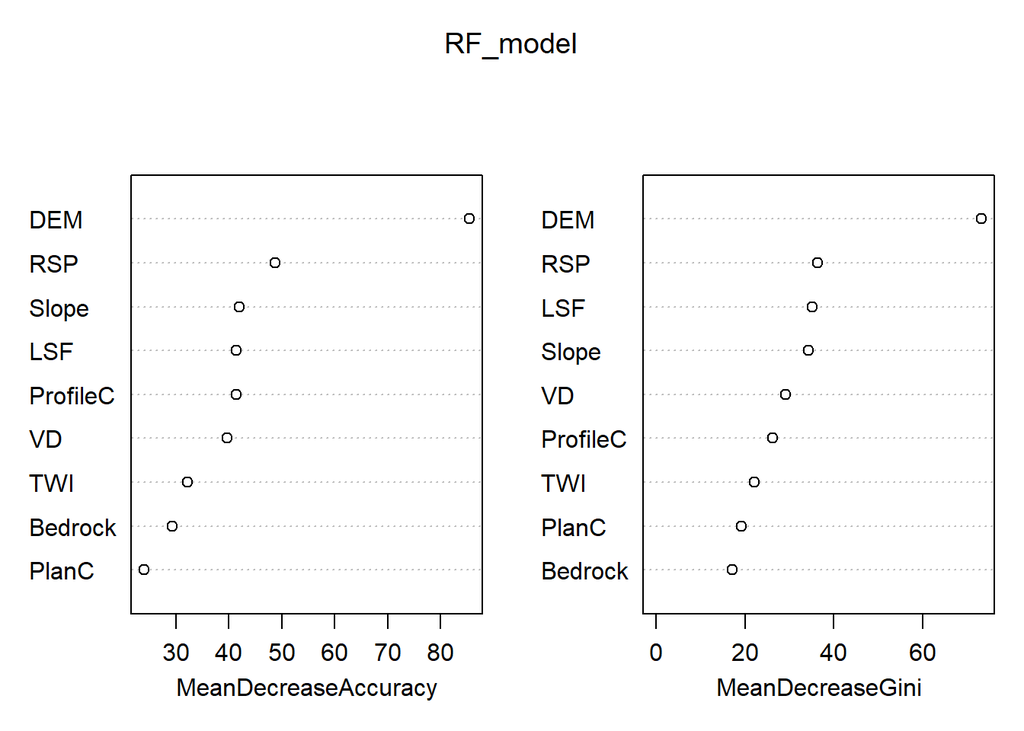

```r
sampleNum_dict[mn]<-nrow(sampData)

sampData$Bedrock<- droplevels(as.factor(sampData$Bedrock))
sampData$soilID<- droplevels(as.factor(sampData$soilID))

RF_model<-randomForest(soilID ~.,data = sampData,
                       importance = TRUE, proximity = FALSE,
                       ntree=1000,type="classification")

varImpPlot(RF_model)
```

```r
print(RF_model)
```

```
##
## Call:
##  randomForest(formula = soilID ~ ., data = sampData, importance = TRUE,      proximity = FALSE, ntree = 1000, type = "classification")
##                Type of random forest: classification
##                      Number of trees: 1000
## No. of variables tried at each split: 3
##
##         OOB estimate of  error rate: 28.12%
## Confusion matrix:
##     1 20 21 23  3 30 31 501 502 503  7 class.error
## 1   0  0  0  0  2  0  0   0   0   0  0   1.0000000
## 20  0 22  6  0  0  0  0   0   0   9  8   0.5111111
## 21  0  7 12  0  0  0  0   0   0   2  1   0.4545455
## 23  0  0  0 21  0  2  1   0   0   5  0   0.2758621
## 3   1  0  0  0 13  0  0   4   0   0  0   0.2777778
## 30  0  0  0  2  0  7  0   0   0   0  0   0.2222222
## 31  0  0  0  2  0  0 12   0   0   0  0   0.1428571
## 501 0  0  0  0  6  0  0  57   0   0  1   0.1093750
## 502 0  3  0  0  0  0  0   2   1   1  0   0.8571429
## 503 0  7  2  5  0  0  0   0   0  64  4   0.2195122
## 7   0  6  0  0  0  1  0   1   0   6 39   0.2641509
```

```r
map_RF <- predict(covStack, RF_model, paste(result_tif_folder,mn,".tif",sep=""),
                  format = "GTiff", datatype = "FLT4S", overwrite = TRUE)

rm("mn","shpPoint","sampData","RF_model","map_RF")
```

RAN PlanC ns5 15

```r
mn="All_pRAN_PlanC_NS5_pen15"

shpPoint<-readOGR(paste(point_shp_folder,mn,".shp",sep = "")) ###
sampData <- extract(covStack, shpPoint, sp = TRUE,method = "simple")

sampData<-sampData@data

sampData<-sampData[sampData$soilID %in% soil_type,]

sampData<-na.omit(sampData)

print(dim(sampData))
```

```
## [1] 345  10
```

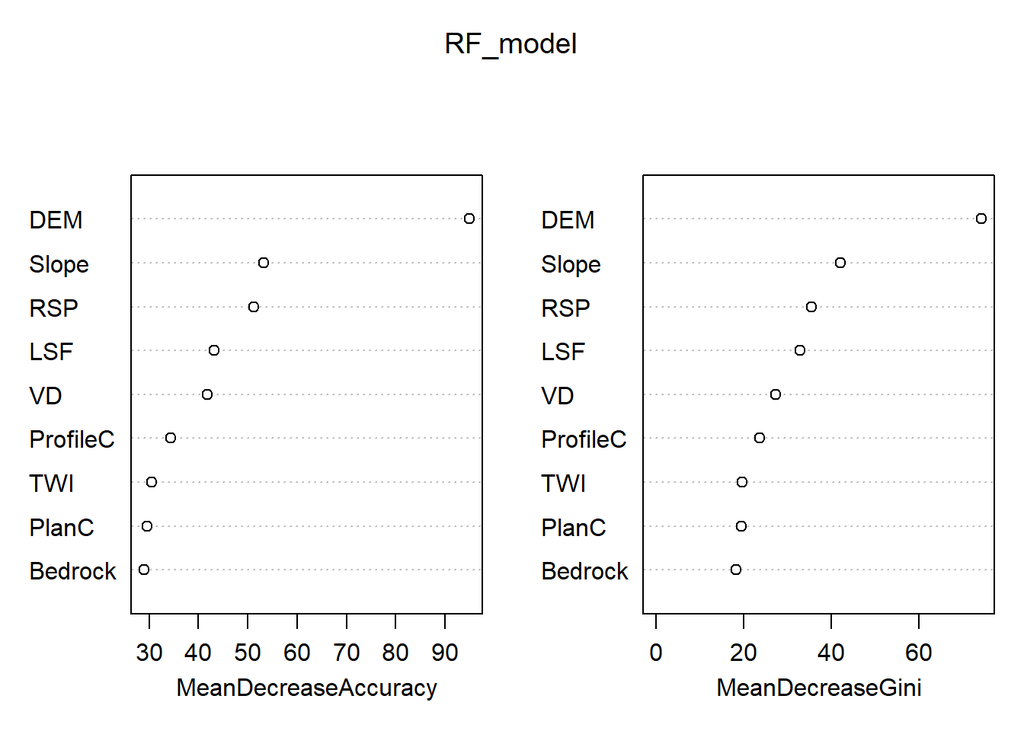

```r
sampleNum_dict[mn]<-nrow(sampData)

sampData$Bedrock<- droplevels(as.factor(sampData$Bedrock))
sampData$soilID<- droplevels(as.factor(sampData$soilID))

RF_model<-randomForest(soilID ~.,data = sampData,
                       importance = TRUE, proximity = FALSE,
                       ntree=1000,type="classification")

varImpPlot(RF_model)
```

```r
print(RF_model)
```

```
##
## Call:
##  randomForest(formula = soilID ~ ., data = sampData, importance = TRUE,      proximity = FALSE, ntree = 1000, type = "classification")
##                Type of random forest: classification
##                      Number of trees: 1000
## No. of variables tried at each split: 3
##
##         OOB estimate of  error rate: 27.54%
## Confusion matrix:
##     1 20 21 23  3 30 31 501 502 503  7 class.error
## 1   0  0  0  0  2  0  0   0   0   0  0  1.00000000
## 20  0 25  6  0  0  0  0   1   0   7  6  0.44444444
## 21  0 13  6  0  0  0  0   0   1   2  0  0.72727273
## 23  0  0  0 21  0  2  0   0   0   3  3  0.27586207
## 3   0  0  0  0 14  0  0   4   0   0  0  0.22222222
## 30  0  0  0  6  0  1  2   0   0   0  0  0.88888889
## 31  0  0  0  1  0  1 11   0   0   0  1  0.21428571
## 501 0  1  0  0  1  0  0  60   0   0  2  0.06250000
## 502 0  3  0  0  0  0  0   1   2   1  0  0.71428571
## 503 0  2  1  2  0  0  0   0   0  74  3  0.09756098
## 7   0  5  0  1  0  1  0   5   0   5 36  0.32075472
```

```r
map_RF <- predict(covStack, RF_model, paste(result_tif_folder,mn,".tif",sep=""),
                  format = "GTiff", datatype = "FLT4S", overwrite = TRUE)

rm("mn","shpPoint","sampData","RF_model","map_RF")
```

SNA PlanC ns5 30

```r
mn="All_pSNA_PlanC_NS5_pen30"

shpPoint<-readOGR(paste(point_shp_folder,mn,".shp",sep = "")) ###
sampData <- extract(covStack, shpPoint, sp = TRUE,method = "simple")

sampData<-sampData@data

sampData<-sampData[sampData$soilID %in% soil_type,]

sampData<-na.omit(sampData)

print(dim(sampData))
```

```
## [1] 649  10
```

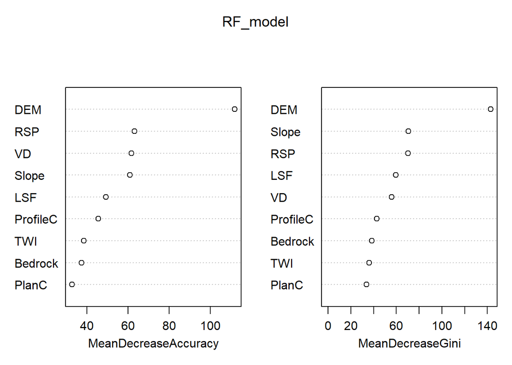

```r
sampleNum_dict[mn]<-nrow(sampData)

sampData$Bedrock<- droplevels(as.factor(sampData$Bedrock))
sampData$soilID<- droplevels(as.factor(sampData$soilID))

RF_model<-randomForest(soilID ~.,data = sampData,
                       importance = TRUE, proximity = FALSE,
                       ntree=1000,type="classification")

varImpPlot(RF_model)
```

```r
print(RF_model)
```

```
##
## Call:
##  randomForest(formula = soilID ~ ., data = sampData, importance = TRUE,      proximity = FALSE, ntree = 1000, type = "classification")
##                Type of random forest: classification
##                      Number of trees: 1000
## No. of variables tried at each split: 3
##
##         OOB estimate of  error rate: 21.73%
## Confusion matrix:
##     1 20 21 23  3 30 31 501 502 503  7 class.error
## 1   1  0  0  0  2  0  0   0   0   0  0   0.6666667
## 20  0 45 10  0  0  0  0   0   0  15 14   0.4642857
## 21  0 14 16  0  0  0  0   0   1   3  0   0.5294118
## 23  0  0  0 43  0  2  4   0   0   6  0   0.2181818
## 3   1  0  0  0 23  0  0  12   0   0  0   0.3611111
## 30  0  0  0  2  0 10  2   0   0   0  0   0.2857143
## 31  0  0  0  3  0  0 24   0   0   0  0   0.1111111
## 501 0  0  0  0 11  0  0 114   0   0  2   0.1023622
## 502 0  2  0  0  0  0  0   1   7   1  3   0.5000000
## 503 0  7  3  6  0  0  0   0   0 135  4   0.1290323
## 7   0  4  0  0  0  1  0   1   1   3 90   0.1000000
```

```r
map_RF <- predict(covStack, RF_model, paste(result_tif_folder,mn,".tif",sep=""),
                  format = "GTiff", datatype = "FLT4S", overwrite = TRUE)

rm("mn","shpPoint","sampData","RF_model","map_RF")
```

RAN PlanC ns5 30

```r
mn="All_pRAN_PlanC_NS5_pen30"

shpPoint<-readOGR(paste(point_shp_folder,mn,".shp",sep = "")) ###
sampData <- extract(covStack, shpPoint, sp = TRUE,method = "simple")

sampData<-sampData@data

sampData<-sampData[sampData$soilID %in% soil_type,]

sampData<-na.omit(sampData)

print(dim(sampData))
```

```
## [1] 650  10
```

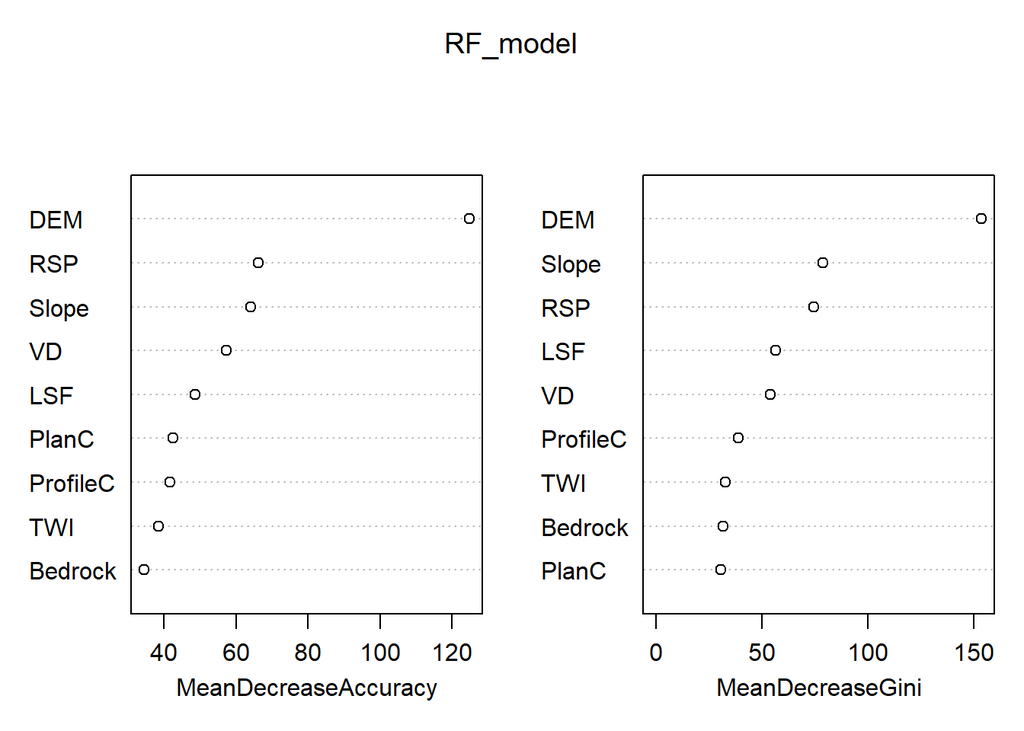

```r
sampleNum_dict[mn]<-nrow(sampData)

sampData$Bedrock<- droplevels(as.factor(sampData$Bedrock))
sampData$soilID<- droplevels(as.factor(sampData$soilID))

RF_model<-randomForest(soilID ~.,data = sampData,
                       importance = TRUE, proximity = FALSE,
                       ntree=1000,type="classification")

varImpPlot(RF_model)
```

```r
print(RF_model)
```

```
##
## Call:
##  randomForest(formula = soilID ~ ., data = sampData, importance = TRUE,      proximity = FALSE, ntree = 1000, type = "classification")
##                Type of random forest: classification
##                      Number of trees: 1000
## No. of variables tried at each split: 3
##
##         OOB estimate of  error rate: 19.54%
## Confusion matrix:
##     1 20 21 23  3 30 31 501 502 503  7 class.error
## 1   2  0  0  0  2  0  0   0   0   0  0  0.50000000
## 20  0 56 10  0  0  0  0   1   0  11  6  0.33333333
## 21  0 17 14  0  0  0  0   0   1   1  1  0.58823529
## 23  0  0  0 43  0  5  1   0   0   4  2  0.21818182
## 3   1  0  0  0 32  0  0   3   0   0  0  0.11111111
## 30  0  0  0  8  0  5  1   0   0   0  0  0.64285714
## 31  0  0  0  4  0  0 23   0   0   0  0  0.14814815
## 501 0  2  0  0  5  0  0 119   0   0  1  0.06299213
## 502 0  2  1  0  0  0  0   2   5   0  4  0.64285714
## 503 0  3  2  1  0  0  0   0   0 141  8  0.09032258
## 7   0  6  0  1  0  0  0   3   1   6 83  0.17000000
```

```r
map_RF <- predict(covStack, RF_model, paste(result_tif_folder,mn,".tif",sep=""),
                  format = "GTiff", datatype = "FLT4S", overwrite = TRUE)

rm("mn","shpPoint","sampData","RF_model","map_RF")
```

SNA PlanC ns5 45

```r
mn="All_pSNA_PlanC_NS5_pen45"

shpPoint<-readOGR(paste(point_shp_folder,mn,".shp",sep = "")) ###
sampData <- extract(covStack, shpPoint, sp = TRUE,method = "simple")

sampData<-sampData@data

sampData<-sampData[sampData$soilID %in% soil_type,]

sampData<-na.omit(sampData)

print(dim(sampData))
```

```
## [1] 953  10
```

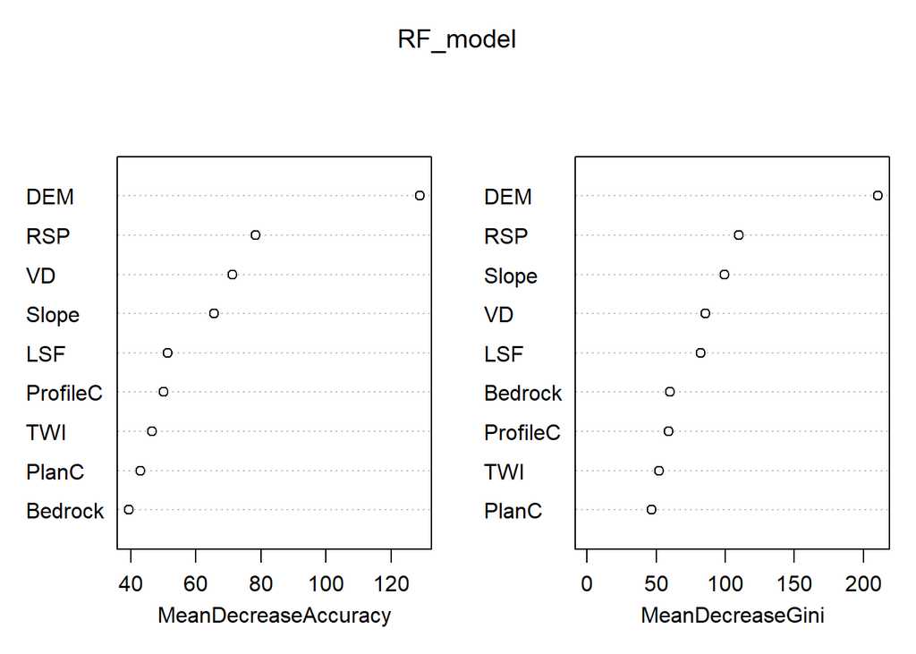

```r
sampleNum_dict[mn]<-nrow(sampData)

sampData$Bedrock<- droplevels(as.factor(sampData$Bedrock))
sampData$soilID<- droplevels(as.factor(sampData$soilID))

RF_model<-randomForest(soilID ~.,data = sampData,
                       importance = TRUE, proximity = FALSE,
                       ntree=1000,type="classification")

varImpPlot(RF_model)
```

```r
print(RF_model)
```

```
##
## Call:
##  randomForest(formula = soilID ~ ., data = sampData, importance = TRUE,      proximity = FALSE, ntree = 1000, type = "classification")
##                Type of random forest: classification
##                      Number of trees: 1000
## No. of variables tried at each split: 3
##
##         OOB estimate of  error rate: 19.52%
## Confusion matrix:
##     1 20 21 23  3 30 31 501 502 503   7 class.error
## 1   2  0  0  0  2  0  0   0   0   0   0  0.50000000
## 20  0 72 12  0  0  0  0   0   0  20  16  0.40000000
## 21  0 18 22  0  0  0  0   0   1   4   0  0.51111111
## 23  0  0  0 65  0  2  4   0   0   9   0  0.18750000
## 3   2  0  0  0 37  0  0  15   0   0   0  0.31481481
## 30  0  0  0  3  0 17  1   0   0   0   0  0.19047619
## 31  0  0  0  4  0  0 36   0   0   0   0  0.10000000
## 501 0  0  0  0 15  0  0 172   0   0   3  0.09473684
## 502 0  3  0  0  0  0  0   2  12   1   2  0.40000000
## 503 0  8  3  7  0  1  0   0   0 204   9  0.12068966
## 7   0  7  0  0  0  1  0   5   1   5 128  0.12925170
```

```r
map_RF <- predict(covStack, RF_model, paste(result_tif_folder,mn,".tif",sep=""),
                  format = "GTiff", datatype = "FLT4S", overwrite = TRUE)

rm("mn","shpPoint","sampData","RF_model","map_RF")
```

RAN PlanC ns5 45

```r
mn="All_pRAN_PlanC_NS5_pen45"

shpPoint<-readOGR(paste(point_shp_folder,mn,".shp",sep = "")) ###
sampData <- extract(covStack, shpPoint, sp = TRUE,method = "simple")

sampData<-sampData@data

sampData<-sampData[sampData$soilID %in% soil_type,]

sampData<-na.omit(sampData)

print(dim(sampData))
```

```
## [1] 954  10
```

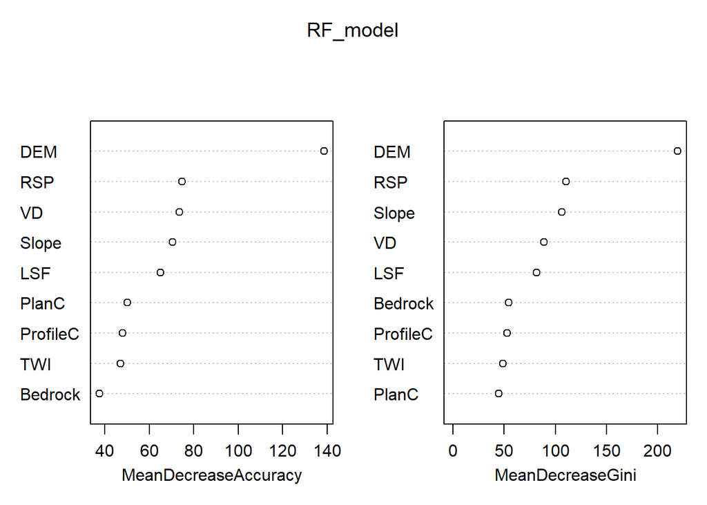

```r
sampleNum_dict[mn]<-nrow(sampData)

sampData$Bedrock<- droplevels(as.factor(sampData$Bedrock))
sampData$soilID<- droplevels(as.factor(sampData$soilID))

RF_model<-randomForest(soilID ~.,data = sampData,
                       importance = TRUE, proximity = FALSE,
                       ntree=1000,type="classification")

varImpPlot(RF_model)
```

```r
print(RF_model)
```

```
##
## Call:
##  randomForest(formula = soilID ~ ., data = sampData, importance = TRUE,      proximity = FALSE, ntree = 1000, type = "classification")
##                Type of random forest: classification
##                      Number of trees: 1000
## No. of variables tried at each split: 3
##
##         OOB estimate of  error rate: 17.71%
## Confusion matrix:
##     1 20 21 23  3 30 31 501 502 503   7 class.error
## 1   4  0  0  0  1  0  0   0   0   0   0  0.20000000
## 20  0 80  9  0  0  0  0   1   0  15  15  0.33333333
## 21  0 17 23  0  0  0  0   0   0   4   1  0.48888889
## 23  0  0  0 54  0  6  4   0   0  12   4  0.32500000
## 3   0  0  0  0 45  0  0   9   0   0   0  0.16666667
## 30  0  0  0  5  0 14  0   0   0   0   2  0.33333333
## 31  0  0  0  4  0  0 36   0   0   0   0  0.10000000
## 501 0  1  0  0  8  0  0 178   0   0   3  0.06315789
## 502 0  1  0  0  0  0  0   3  15   0   1  0.25000000
## 503 0  5  3  7  0  0  0   0   0 211   6  0.09051724
## 7   0  8  0  1  0  0  0   5   0   8 125  0.14965986
```

```r
map_RF <- predict(covStack, RF_model, paste(result_tif_folder,mn,".tif",sep=""),
                  format = "GTiff", datatype = "FLT4S", overwrite = TRUE)

rm("mn","shpPoint","sampData","RF_model","map_RF")
```

SNA PlanC ns5 60

```r
mn="All_pSNA_PlanC_NS5_pen60"

shpPoint<-readOGR(paste(point_shp_folder,mn,".shp",sep = "")) ###
sampData <- extract(covStack, shpPoint, sp = TRUE,method = "simple")

sampData<-sampData@data

sampData<-sampData[sampData$soilID %in% soil_type,]

sampData<-na.omit(sampData)

print(dim(sampData))
```

```
## [1] 1262   10
```

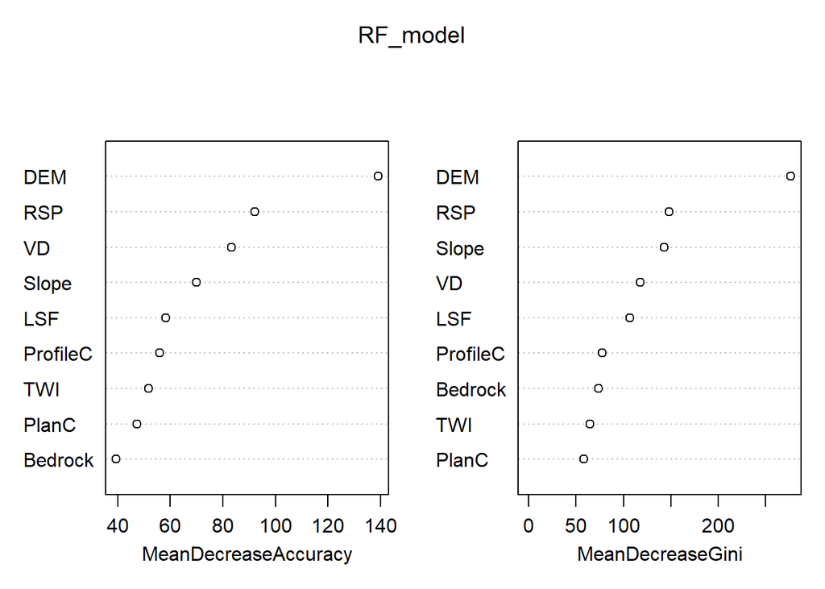

```r
sampleNum_dict[mn]<-nrow(sampData)

sampData$Bedrock<- droplevels(as.factor(sampData$Bedrock))
sampData$soilID<- droplevels(as.factor(sampData$soilID))

RF_model<-randomForest(soilID ~.,data = sampData,
                       importance = TRUE, proximity = FALSE,
                       ntree=1000,type="classification")

varImpPlot(RF_model)
```

```r
print(RF_model)
```

```
##
## Call:
##  randomForest(formula = soilID ~ ., data = sampData, importance = TRUE,      proximity = FALSE, ntree = 1000, type = "classification")
##                Type of random forest: classification
##                      Number of trees: 1000
## No. of variables tried at each split: 3
##
##         OOB estimate of  error rate: 18.62%
## Confusion matrix:
##     1  20 21 23  3 30 31 501 502 503   7 class.error
## 1   3   0  0  0  2  0  0   0   0   0   0  0.40000000
## 20  0 105 12  0  0  0  0   0   0  21  22  0.34375000
## 21  0  22 32  0  0  0  0   0   1   3   0  0.44827586
## 23  0   0  0 84  0  5  5   0   0  12   1  0.21495327
## 3   1   0  0  0 51  0  0  20   0   0   0  0.29166667
## 30  0   0  0  4  0 21  1   0   0   0   1  0.22222222
## 31  0   0  0  3  0  1 49   0   0   0   0  0.07547170
## 501 0   0  0  0 14  0  0 232   1   0   5  0.07936508
## 502 0   3  1  0  0  0  0   2  17   1   3  0.37037037
## 503 0  14  2 11  0  0  0   0   0 270  10  0.12052117
## 7   0  10  0  0  0  2  0   8   1  10 163  0.15979381
```

```r
map_RF <- predict(covStack, RF_model, paste(result_tif_folder,mn,".tif",sep=""),
                  format = "GTiff", datatype = "FLT4S", overwrite = TRUE)

rm("mn","shpPoint","sampData","RF_model","map_RF")
```

RAN PlanC ns5 60

```r
mn="All_pRAN_PlanC_NS5_pen60"

shpPoint<-readOGR(paste(point_shp_folder,mn,".shp",sep = "")) ###
sampData <- extract(covStack, shpPoint, sp = TRUE,method = "simple")

sampData<-sampData@data

sampData<-sampData[sampData$soilID %in% soil_type,]

sampData<-na.omit(sampData)

print(dim(sampData))
```

```
## [1] 1264   10
```

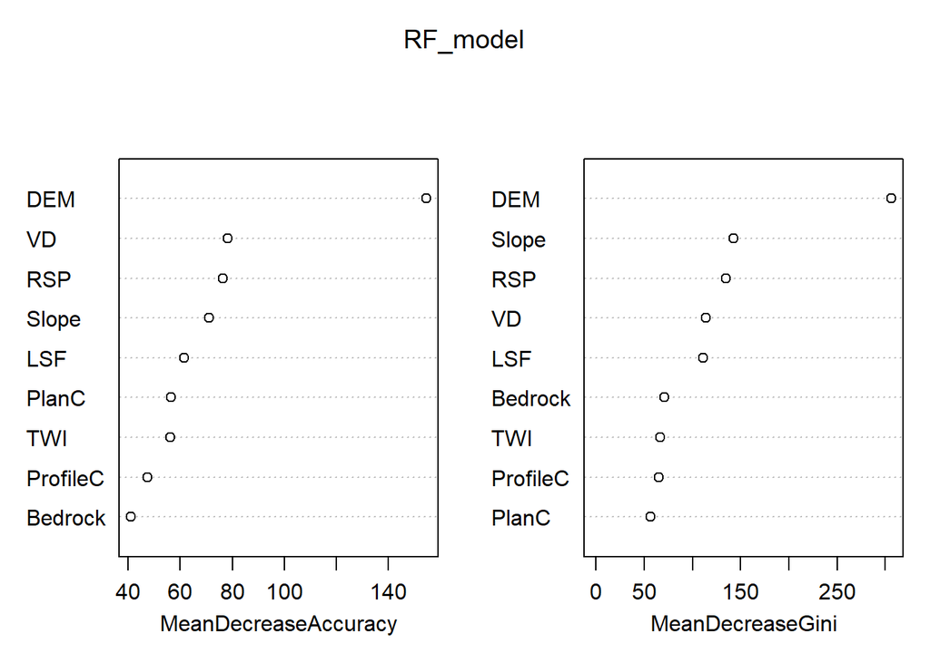

```r
sampleNum_dict[mn]<-nrow(sampData)

sampData$Bedrock<- droplevels(as.factor(sampData$Bedrock))
sampData$soilID<- droplevels(as.factor(sampData$soilID))

RF_model<-randomForest(soilID ~.,data = sampData,
                       importance = TRUE, proximity = FALSE,
                       ntree=1000,type="classification")

varImpPlot(RF_model)
```

```r
print(RF_model)
```

```
##
## Call:
##  randomForest(formula = soilID ~ ., data = sampData, importance = TRUE,      proximity = FALSE, ntree = 1000, type = "classification")
##                Type of random forest: classification
##                      Number of trees: 1000
## No. of variables tried at each split: 3
##
##         OOB estimate of  error rate: 15.82%
## Confusion matrix:
##     1  20 21 23  3 30 31 501 502 503   7 class.error
## 1   5   0  0  0  2  0  0   0   0   0   0  0.28571429
## 20  0 112 11  0  0  0  0   0   3  19  15  0.30000000
## 21  0  19 36  0  0  0  0   0   0   2   1  0.37931034
## 23  0   0  0 79  0  9  2   0   0  15   2  0.26168224
## 3   1   0  0  0 59  0  0  12   0   0   0  0.18055556
## 30  0   0  0  4  0 21  1   0   0   0   1  0.22222222
## 31  0   0  0  5  0  1 47   0   0   0   0  0.11320755
## 501 0   2  0  0  7  0  0 239   1   0   3  0.05158730
## 502 0   5  0  0  0  0  0   4  15   1   2  0.44444444
## 503 0   6  1  9  0  0  0   0   0 281  10  0.08469055
## 7   0  10  0  1  0  1  0   3   1   8 170  0.12371134
```

```r
map_RF <- predict(covStack, RF_model, paste(result_tif_folder,mn,".tif",sep=""),
                  format = "GTiff", datatype = "FLT4S", overwrite = TRUE)

rm("mn","shpPoint","sampData","RF_model","map_RF")
```

SNA PlanC ns5 75

```r
mn="All_pSNA_PlanC_NS5_pen75"

shpPoint<-readOGR(paste(point_shp_folder,mn,".shp",sep = "")) ###
sampData <- extract(covStack, shpPoint, sp = TRUE,method = "simple")

sampData<-sampData@data

sampData<-sampData[sampData$soilID %in% soil_type,]

sampData<-na.omit(sampData)

print(dim(sampData))
```

```
## [1] 1566   10
```

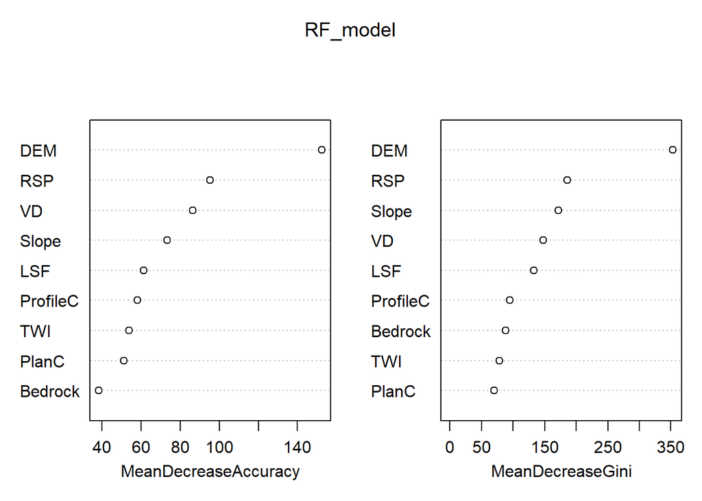

```r
sampleNum_dict[mn]<-nrow(sampData)

sampData$Bedrock<- droplevels(as.factor(sampData$Bedrock))
sampData$soilID<- droplevels(as.factor(sampData$soilID))

RF_model<-randomForest(soilID ~.,data = sampData,
                       importance = TRUE, proximity = FALSE,
                       ntree=1000,type="classification")

varImpPlot(RF_model)
```

```r
print(RF_model)
```

```
##
## Call:
##  randomForest(formula = soilID ~ ., data = sampData, importance = TRUE,      proximity = FALSE, ntree = 1000, type = "classification")
##                Type of random forest: classification
##                      Number of trees: 1000
## No. of variables tried at each split: 3
##
##         OOB estimate of  error rate: 18.39%
## Confusion matrix:
##     1  20 21  23  3 30 31 501 502 503   7 class.error
## 1   3   0  0   0  3  0  0   0   0   0   0  0.50000000
## 20  0 130 13   0  0  0  0   0   0  27  27  0.34010152
## 21  0  22 43   0  0  0  0   0   1   3   0  0.37681159
## 23  0   0  0 102  0  7  4   0   0  16   4  0.23308271
## 3   1   0  0   0 68  0  0  21   0   0   0  0.24444444
## 30  0   0  0   6  0 22  2   0   0   0   3  0.33333333
## 31  0   0  0   6  0  1 60   0   0   0   0  0.10447761
## 501 0   0  0   0 16  0  0 292   1   0   6  0.07301587
## 502 0   5  1   0  0  0  0   1  22   1   3  0.33333333
## 503 0  15  2  14  0  0  0   0   0 337  13  0.11548556
## 7   0  14  0   4  0  2  0  11   0  12 199  0.17768595
```

```r
map_RF <- predict(covStack, RF_model, paste(result_tif_folder,mn,".tif",sep=""),
                  format = "GTiff", datatype = "FLT4S", overwrite = TRUE)

rm("mn","shpPoint","sampData","RF_model","map_RF")
```

RAN PlanC ns5 75

```r
mn="All_pRAN_PlanC_NS5_pen75"

shpPoint<-readOGR(paste(point_shp_folder,mn,".shp",sep = "")) ###
sampData <- extract(covStack, shpPoint, sp = TRUE,method = "simple")

sampData<-sampData@data

sampData<-sampData[sampData$soilID %in% soil_type,]

sampData<-na.omit(sampData)

print(dim(sampData))
```

```
## [1] 1568   10
```

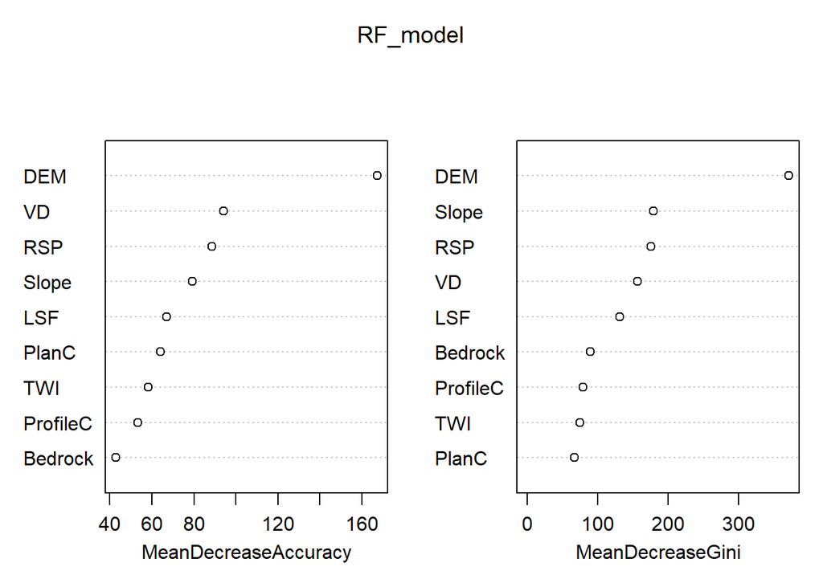

```r
sampleNum_dict[mn]<-nrow(sampData)

sampData$Bedrock<- droplevels(as.factor(sampData$Bedrock))
sampData$soilID<- droplevels(as.factor(sampData$soilID))

RF_model<-randomForest(soilID ~.,data = sampData,
                       importance = TRUE, proximity = FALSE,
                       ntree=1000,type="classification")

varImpPlot(RF_model)
```

```r
print(RF_model)
```

```
##
## Call:
##  randomForest(formula = soilID ~ ., data = sampData, importance = TRUE,      proximity = FALSE, ntree = 1000, type = "classification")
##                Type of random forest: classification
##                      Number of trees: 1000
## No. of variables tried at each split: 3
##
##         OOB estimate of  error rate: 14.29%
## Confusion matrix:
##     1  20 21  23  3 30 31 501 502 503   7 class.error
## 1   5   0  0   0  3  0  0   0   0   0   0  0.37500000
## 20  0 149 11   0  0  0  0   2   2  19  14  0.24365482
## 21  0  25 42   0  0  0  0   0   0   2   0  0.39130435
## 23  0   0  0 104  0  8  2   0   0  15   4  0.21804511
## 3   1   0  0   0 77  0  0  12   0   0   0  0.14444444
## 30  0   0  0   6  0 24  1   0   0   0   2  0.27272727
## 31  0   0  0   6  0  0 61   0   0   0   0  0.08955224
## 501 0   2  0   0 13  0  0 295   0   0   5  0.06349206
## 502 0   3  0   0  0  0  0   2  25   0   3  0.24242424
## 503 0  10  1  10  0  0  0   0   0 351   9  0.07874016
## 7   0  10  0   1  0  0  0   8   0  12 211  0.12809917
```

```r
map_RF <- predict(covStack, RF_model, paste(result_tif_folder,mn,".tif",sep=""),
                  format = "GTiff", datatype = "FLT4S", overwrite = TRUE)

rm("mn","shpPoint","sampData","RF_model","map_RF")
```

# ProfileC

SNA ProfileC ns3 15

```r
mn="All_pSNA_ProfileC_NS3_pen15"

shpPoint<-readOGR(paste(point_shp_folder,mn,".shp",sep = "")) ###
sampData <- extract(covStack, shpPoint, sp = TRUE,method = "simple")

sampData<-sampData@data

sampData<-sampData[sampData$soilID %in% soil_type,]

sampData<-na.omit(sampData)

print(dim(sampData))
```

```
## [1] 996  10
```

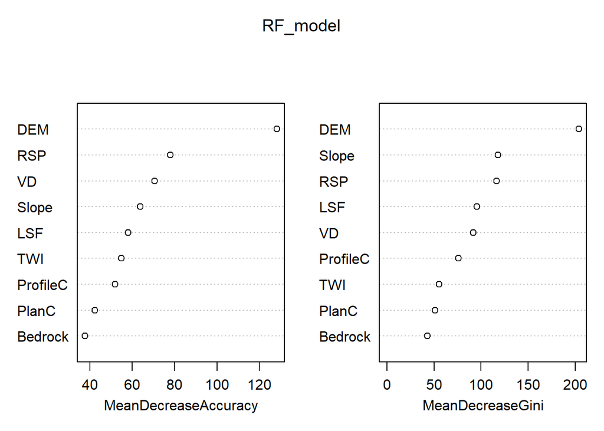

```r
sampleNum_dict[mn]<-nrow(sampData)

sampData$Bedrock<- droplevels(as.factor(sampData$Bedrock))
sampData$soilID<- droplevels(as.factor(sampData$soilID))

RF_model<-randomForest(soilID ~.,data = sampData,
                       importance = TRUE, proximity = FALSE,
                       ntree=1000,type="classification")

varImpPlot(RF_model)
```

```r
print(RF_model)
```

```
##
## Call:
##  randomForest(formula = soilID ~ ., data = sampData, importance = TRUE,      proximity = FALSE, ntree = 1000, type = "classification")
##                Type of random forest: classification
##                      Number of trees: 1000
## No. of variables tried at each split: 3
##
##         OOB estimate of  error rate: 23.9%
## Confusion matrix:
##     1 20 21 23  3 30 31 501 502 503   7 class.error
## 1   2  0  0  0  1  0  0   0   0   0   0  0.33333333
## 20  0 87 19  0  0  0  0   1   2  29  18  0.44230769
## 21  0 24 30  0  0  0  0   0   0   3   0  0.47368421
## 23  0  0  0 68  0  5  2   0   0  17   5  0.29896907
## 3   1  0  0  0 44  0  0   8   0   0   0  0.16981132
## 30  0  0  0  5  0 20  0   0   0   3   5  0.39393939
## 31  0  0  0  2  0  1 36   0   0   0   0  0.07692308
## 501 0  0  0  0  7  0  0 150   0   0   4  0.06832298
## 502 0  6  0  0  0  0  0   2  11   1   1  0.47619048
## 503 0 18  4  9  0  1  0   0   0 197   4  0.15450644
## 7   0  7  0  0  0  3  0  10   0  10 113  0.20979021
```

```r
map_RF <- predict(covStack, RF_model, paste(result_tif_folder,mn,".tif",sep=""),
                  format = "GTiff", datatype = "FLT4S", overwrite = TRUE)

rm("mn","shpPoint","sampData","RF_model","map_RF")
```

RAN ProfileC ns3 15

```r
mn="All_pRAN_ProfileC_NS3_pen15"

shpPoint<-readOGR(paste(point_shp_folder,mn,".shp",sep = "")) ###
sampData <- extract(covStack, shpPoint, sp = TRUE,method = "simple")

sampData<-sampData@data

sampData<-sampData[sampData$soilID %in% soil_type,]

sampData<-na.omit(sampData)

print(dim(sampData))
```

```
## [1] 998  10
```

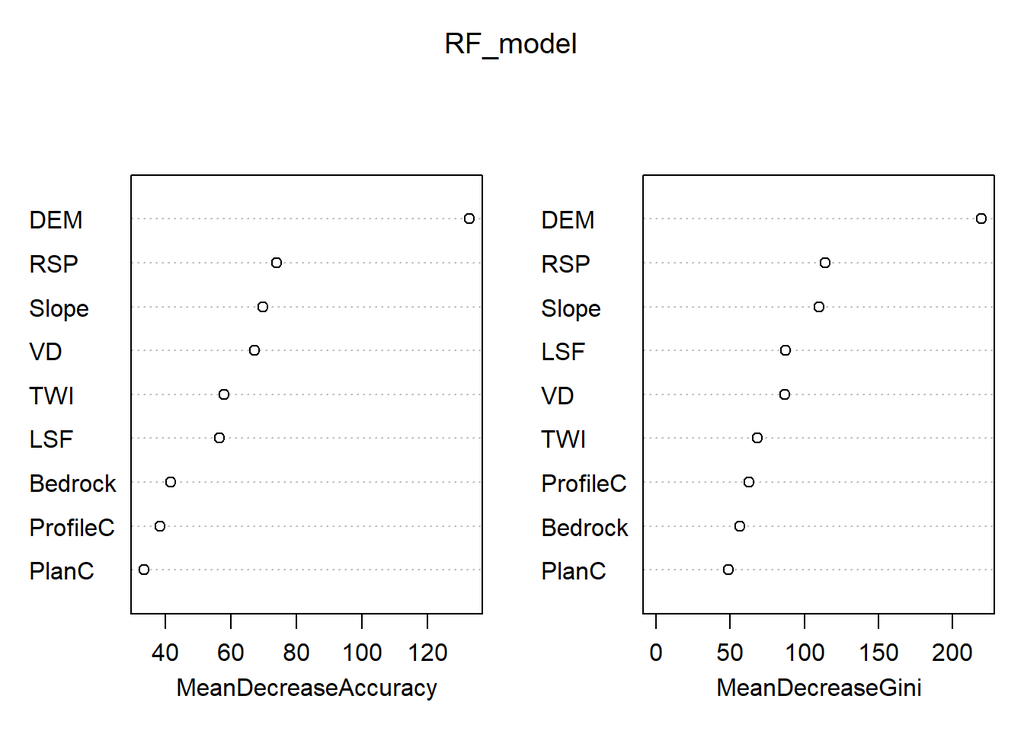

```r
sampleNum_dict[mn]<-nrow(sampData)

sampData$Bedrock<- droplevels(as.factor(sampData$Bedrock))
sampData$soilID<- droplevels(as.factor(sampData$soilID))

RF_model<-randomForest(soilID ~.,data = sampData,
                       importance = TRUE, proximity = FALSE,
                       ntree=1000,type="classification")

varImpPlot(RF_model)
```

```r
print(RF_model)
```

```
##
## Call:
##  randomForest(formula = soilID ~ ., data = sampData, importance = TRUE,      proximity = FALSE, ntree = 1000, type = "classification")
##                Type of random forest: classification
##                      Number of trees: 1000
## No. of variables tried at each split: 3
##
##         OOB estimate of  error rate: 25.85%
## Confusion matrix:
##     1 20 21 23  3 30 31 501 502 503   7 class.error
## 1   4  0  0  0  1  0  0   0   0   0   0   0.2000000
## 20  0 96 20  1  0  0  0   0   1  27  11   0.3846154
## 21  0 32 23  0  0  0  0   0   0   2   0   0.5964912
## 23  0  0  0 64  0 10  4   0   0  16   3   0.3402062
## 3   0  0  0  0 39  0  0  14   0   0   0   0.2641509
## 30  0  0  0  7  0 19  6   0   0   0   1   0.4242424
## 31  0  0  0  6  0  3 30   0   0   0   0   0.2307692
## 501 0  1  0  0  9  0  0 143   1   0   7   0.1118012
## 502 0  3  0  0  0  0  0   3  13   0   2   0.3809524
## 503 0 22  1  9  0  0  0   0   1 196   4   0.1587983
## 7   0 12  0  1  0  1  0   6   1   9 113   0.2097902
```

```r
map_RF <- predict(covStack, RF_model, paste(result_tif_folder,mn,".tif",sep=""),
                  format = "GTiff", datatype = "FLT4S", overwrite = TRUE)

rm("mn","shpPoint","sampData","RF_model","map_RF")
```

SNA ProfileC ns3 30

```r
mn="All_pSNA_ProfileC_NS3_pen30"

shpPoint<-readOGR(paste(point_shp_folder,mn,".shp",sep = "")) ###
sampData <- extract(covStack, shpPoint, sp = TRUE,method = "simple")

sampData<-sampData@data

sampData<-sampData[sampData$soilID %in% soil_type,]

sampData<-na.omit(sampData)

print(dim(sampData))
```

```
## [1] 1946   10
```

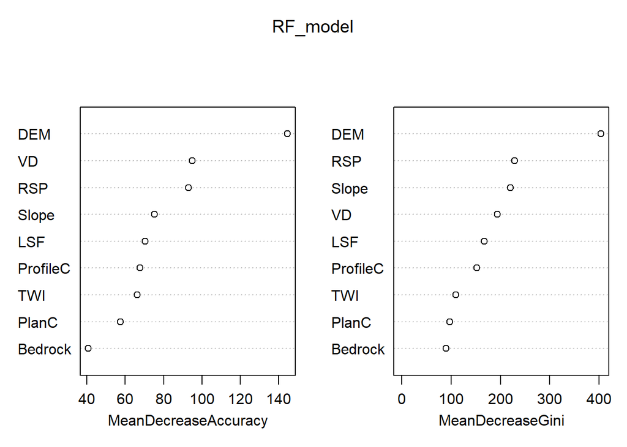

```r
sampleNum_dict[mn]<-nrow(sampData)

sampData$Bedrock<- droplevels(as.factor(sampData$Bedrock))
sampData$soilID<- droplevels(as.factor(sampData$soilID))

RF_model<-randomForest(soilID ~.,data = sampData,
                       importance = TRUE, proximity = FALSE,
                       ntree=1000,type="classification")

varImpPlot(RF_model)
```

```r
print(RF_model)
```

```
##
## Call:
##  randomForest(formula = soilID ~ ., data = sampData, importance = TRUE,      proximity = FALSE, ntree = 1000, type = "classification")
##                Type of random forest: classification
##                      Number of trees: 1000
## No. of variables tried at each split: 3
##
##         OOB estimate of  error rate: 20.86%
## Confusion matrix:
##     1  20 21  23  3 30 31 501 502 503   7 class.error
## 1   4   0  0   0  4  0  0   0   0   0   0  0.50000000
## 20  0 182 33   0  0  0  0   3   0  52  33  0.39933993
## 21  0  46 54   0  0  0  0   0   0   8   0  0.50000000
## 23  0   0  0 143  0 11  3   0   0  25   4  0.23118280
## 3   2   0  0   0 96  0  0   7   0   0   0  0.08571429
## 30  0   0  0   6  0 47  2   0   0   2   5  0.24193548
## 31  0   0  0   4  0  2 71   0   0   1   0  0.08974359
## 501 0   3  0   0 14  0  0 293   0   0  11  0.08722741
## 502 0   2  0   0  0  0  0   3  32   2   1  0.20000000
## 503 0  38  2  14  0  0  0   0   0 396   8  0.13537118
## 7   0  17  0   2  0  1  0  24   1  10 222  0.19855596
```

```r
map_RF <- predict(covStack, RF_model, paste(result_tif_folder,mn,".tif",sep=""),
                  format = "GTiff", datatype = "FLT4S", overwrite = TRUE)

rm("mn","shpPoint","sampData","RF_model","map_RF")
```

RAN ProfileC ns3 30

```r
mn="All_pRAN_ProfileC_NS3_pen30"

shpPoint<-readOGR(paste(point_shp_folder,mn,".shp",sep = "")) ###
sampData <- extract(covStack, shpPoint, sp = TRUE,method = "simple")

sampData<-sampData@data

sampData<-sampData[sampData$soilID %in% soil_type,]

sampData<-na.omit(sampData)

print(dim(sampData))
```

```
## [1] 1946   10
```

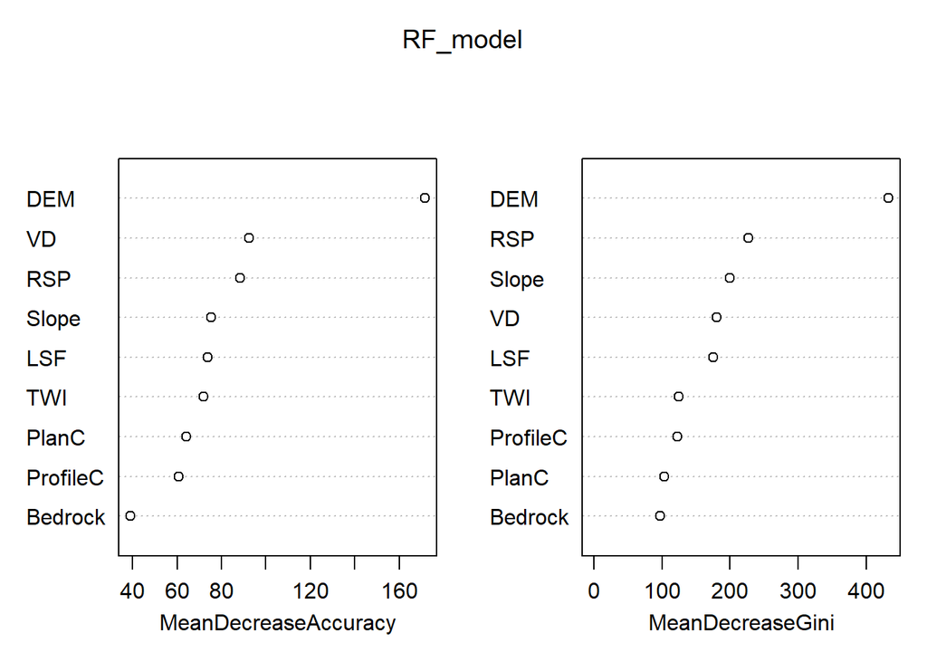

```r
sampleNum_dict[mn]<-nrow(sampData)

sampData$Bedrock<- droplevels(as.factor(sampData$Bedrock))
sampData$soilID<- droplevels(as.factor(sampData$soilID))

RF_model<-randomForest(soilID ~.,data = sampData,
                       importance = TRUE, proximity = FALSE,
                       ntree=1000,type="classification")

varImpPlot(RF_model)
```

```r
print(RF_model)
```

```
##
## Call:
##  randomForest(formula = soilID ~ ., data = sampData, importance = TRUE,      proximity = FALSE, ntree = 1000, type = "classification")
##                Type of random forest: classification
##                      Number of trees: 1000
## No. of variables tried at each split: 3
##
##         OOB estimate of  error rate: 22.46%
## Confusion matrix:
##     1  20 21  23  3 30 31 501 502 503   7 class.error
## 1   7   0  0   0  1  0  0   0   0   0   0  0.12500000
## 20  0 220 22   2  0  1  0   3   1  37  17  0.27392739
## 21  0  47 56   0  0  0  0   0   1   3   1  0.48148148
## 23  0   2  0 131  0 14  5   0   0  26   8  0.29569892
## 3   0   0  0   0 78  0  0  27   0   0   0  0.25714286
## 30  0   0  0  13  0 40  5   0   0   1   3  0.35483871
## 31  0   0  0  11  0  3 64   0   0   0   0  0.17948718
## 501 0   2  0   0 17  0  0 293   1   0   8  0.08722741
## 502 0   5  1   0  0  0  0   2  27   0   5  0.32500000
## 503 0  39  2  23  0  0  0   0   1 379  14  0.17248908
## 7   0  26  0   3  0  3  0  16   3  12 214  0.22743682
```

```r
map_RF <- predict(covStack, RF_model, paste(result_tif_folder,mn,".tif",sep=""),
                  format = "GTiff", datatype = "FLT4S", overwrite = TRUE)

rm("mn","shpPoint","sampData","RF_model","map_RF")
```

SNA ProfileC ns3 45

```r
mn="All_pSNA_ProfileC_NS3_pen45"

shpPoint<-readOGR(paste(point_shp_folder,mn,".shp",sep = "")) ###
sampData <- extract(covStack, shpPoint, sp = TRUE,method = "simple")

sampData<-sampData@data

sampData<-sampData[sampData$soilID %in% soil_type,]

sampData<-na.omit(sampData)

print(dim(sampData))
```

```
## [1] 2895   10
```

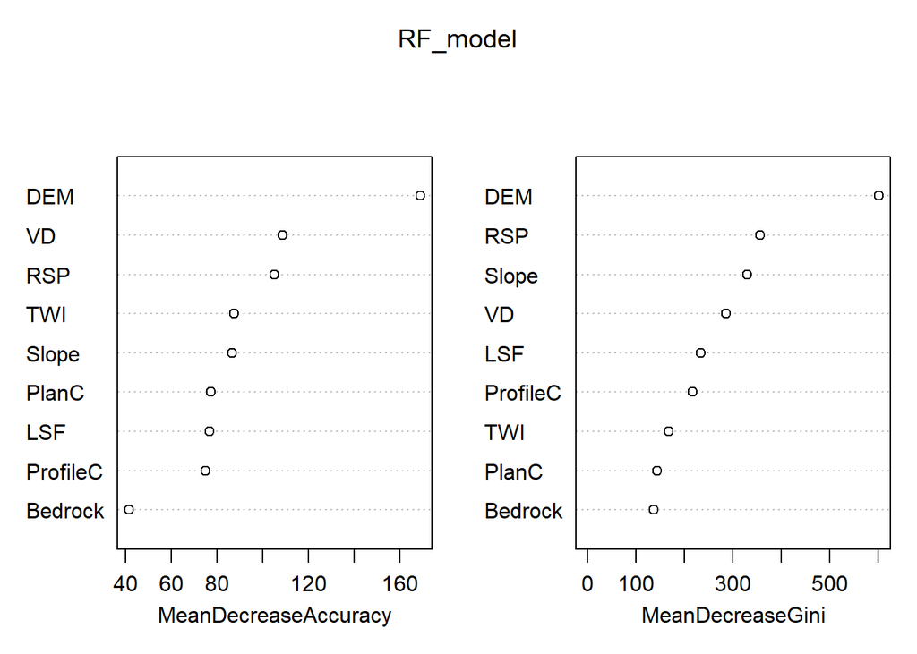

```r
sampleNum_dict[mn]<-nrow(sampData)

sampData$Bedrock<- droplevels(as.factor(sampData$Bedrock))
sampData$soilID<- droplevels(as.factor(sampData$soilID))

RF_model<-randomForest(soilID ~.,data = sampData,
                       importance = TRUE, proximity = FALSE,
                       ntree=1000,type="classification")

varImpPlot(RF_model)
```

```r
print(RF_model)
```

```
##
## Call:
##  randomForest(formula = soilID ~ ., data = sampData, importance = TRUE,      proximity = FALSE, ntree = 1000, type = "classification")
##                Type of random forest: classification
##                      Number of trees: 1000
## No. of variables tried at each split: 3
##
##         OOB estimate of  error rate: 19.38%
## Confusion matrix:
##     1  20 21  23   3 30  31 501 502 503   7 class.error
## 1   9   0  0   0   4  0   0   0   0   0   0  0.30769231
## 20  0 290 48   0   0  0   0   7   1  68  35  0.35412027
## 21  0  55 89   0   0  0   0   0   0  15   1  0.44375000
## 23  0   0  0 228   0 11   3   0   0  27   5  0.16788321
## 3   4   0  0   0 139  0   0  14   0   0   0  0.11464968
## 30  0   0  0   8   0 71   2   0   0   4   6  0.21978022
## 31  0   0  0   6   0  6 104   0   0   1   0  0.11111111
## 501 0   4  0   0  25  0   0 438   0   0  14  0.08939709
## 502 0   2  1   0   0  0   0   4  44   3   3  0.22807018
## 503 0  57  4  16   0  4   0   0   2 588  14  0.14160584
## 7   0  26  1   2   0  2   0  31   1  14 334  0.18734793
```

```r
map_RF <- predict(covStack, RF_model, paste(result_tif_folder,mn,".tif",sep=""),
                  format = "GTiff", datatype = "FLT4S", overwrite = TRUE)

rm("mn","shpPoint","sampData","RF_model","map_RF")
```

RAN ProfileC ns3 45

```r
mn="All_pRAN_ProfileC_NS3_pen45"

shpPoint<-readOGR(paste(point_shp_folder,mn,".shp",sep = "")) ###
sampData <- extract(covStack, shpPoint, sp = TRUE,method = "simple")

sampData<-sampData@data

sampData<-sampData[sampData$soilID %in% soil_type,]

sampData<-na.omit(sampData)

print(dim(sampData))
```

```
## [1] 2894   10
```

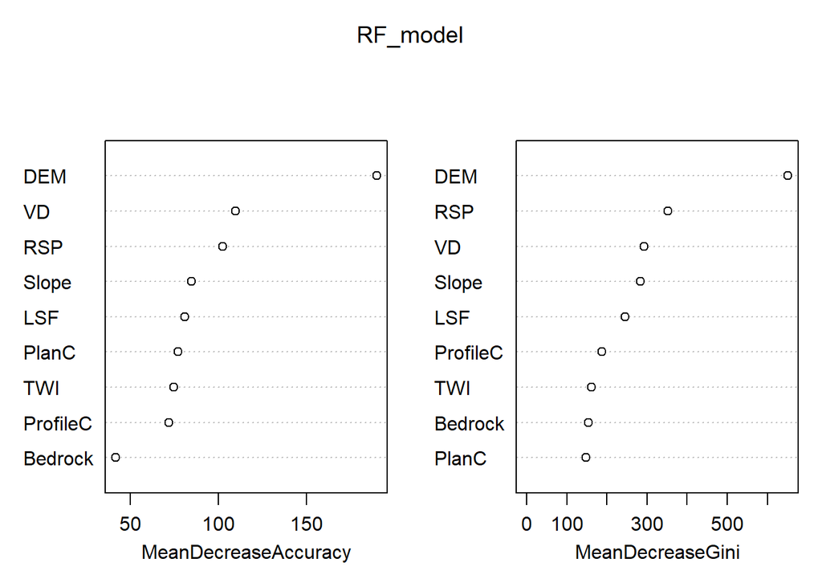

```r
sampleNum_dict[mn]<-nrow(sampData)

sampData$Bedrock<- droplevels(as.factor(sampData$Bedrock))
sampData$soilID<- droplevels(as.factor(sampData$soilID))

RF_model<-randomForest(soilID ~.,data = sampData,
                       importance = TRUE, proximity = FALSE,
                       ntree=1000,type="classification")

varImpPlot(RF_model)
```

```r
print(RF_model)
```

```
##
## Call:
##  randomForest(formula = soilID ~ ., data = sampData, importance = TRUE,      proximity = FALSE, ntree = 1000, type = "classification")
##                Type of random forest: classification
##                      Number of trees: 1000
## No. of variables tried at each split: 3
##
##         OOB estimate of  error rate: 19.32%
## Confusion matrix:
##      1  20 21  23   3 30  31 501 502 503   7 class.error
## 1   11   0  0   0   1  0   0   0   0   0   0  0.08333333
## 20   0 324 23   0   0  0   0   7   2  65  28  0.27839644
## 21   0  53 97   0   0  0   0   1   0   7   2  0.39375000
## 23   0   0  0 204   0 21   4   0   0  38   7  0.25547445
## 3    1   0  0   0 122  0   0  34   0   0   0  0.22292994
## 30   0   0  0  24   0 59   4   0   0   1   3  0.35164835
## 31   0   0  0  12   0  4 100   0   0   1   0  0.14529915
## 501  0   6  1   0  25  0   0 438   1   0  10  0.08939709
## 502  0   3  1   0   0  0   0   2  44   1   6  0.22807018
## 503  0  45  2  23   0  2   0   0   1 594  18  0.13284672
## 7    0  20  0   3   0  4   0  23   2  17 342  0.16788321
```

```r
map_RF <- predict(covStack, RF_model, paste(result_tif_folder,mn,".tif",sep=""),
                  format = "GTiff", datatype = "FLT4S", overwrite = TRUE)

rm("mn","shpPoint","sampData","RF_model","map_RF")
```

SNA ProfileC ns3 60

```r
mn="All_pSNA_ProfileC_NS3_pen60"

shpPoint<-readOGR(paste(point_shp_folder,mn,".shp",sep = "")) ###
sampData <- extract(covStack, shpPoint, sp = TRUE,method = "simple")

sampData<-sampData@data

sampData<-sampData[sampData$soilID %in% soil_type,]

sampData<-na.omit(sampData)

print(dim(sampData))
```

```
## [1] 3850   10
```

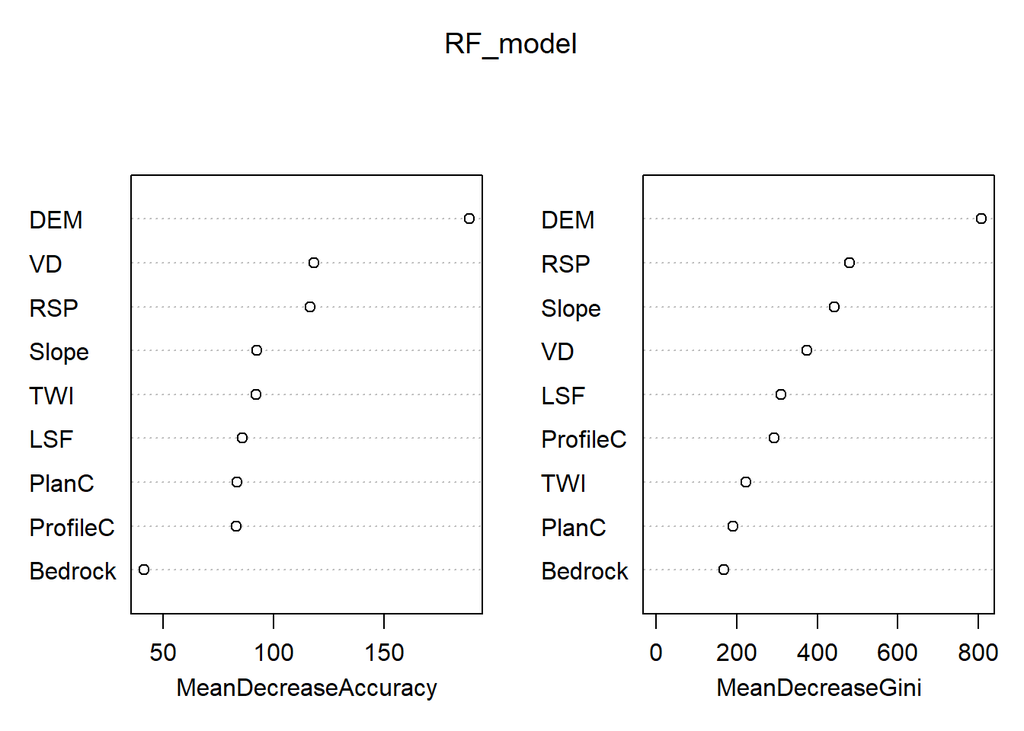

```r
sampleNum_dict[mn]<-nrow(sampData)

sampData$Bedrock<- droplevels(as.factor(sampData$Bedrock))
sampData$soilID<- droplevels(as.factor(sampData$soilID))

RF_model<-randomForest(soilID ~.,data = sampData,
                       importance = TRUE, proximity = FALSE,
                       ntree=1000,type="classification")

varImpPlot(RF_model)
```

```r
print(RF_model)
```

```
##
## Call:
##  randomForest(formula = soilID ~ ., data = sampData, importance = TRUE,      proximity = FALSE, ntree = 1000, type = "classification")
##                Type of random forest: classification
##                      Number of trees: 1000
## No. of variables tried at each split: 3
##
##         OOB estimate of  error rate: 18.42%
## Confusion matrix:
##      1  20  21  23   3 30  31 501 502 503   7 class.error
## 1   13   0   0   0   5  0   0   0   0   0   0  0.27777778
## 20   0 407  46   0   0  0   0   7   2  91  44  0.31825796
## 21   0  65 129   0   0  0   0   0   0  16   2  0.39150943
## 23   0   0   0 294   0 18   3   0   0  39   9  0.19008264
## 3    3   0   0   0 178  0   0  28   0   0   0  0.14832536
## 30   0   0   0  13   0 94   3   0   0   2   9  0.22314050
## 31   0   0   0   7   0  7 141   0   0   1   0  0.09615385
## 501  0   6   0   0  29  0   0 589   1   0  15  0.07968750
## 502  0   1   1   0   0  0   0   1  69   3   1  0.09210526
## 503  0  77   8  27   0  3   0   0   2 773  21  0.15148189
## 7    0  33   2   1   0  2   0  34   1  20 454  0.17001828
```

```r
map_RF <- predict(covStack, RF_model, paste(result_tif_folder,mn,".tif",sep=""),
                  format = "GTiff", datatype = "FLT4S", overwrite = TRUE)

rm("mn","shpPoint","sampData","RF_model","map_RF")
```

RAN ProfileC ns3 60

```r
mn="All_pRAN_ProfileC_NS3_pen60"

shpPoint<-readOGR(paste(point_shp_folder,mn,".shp",sep = "")) ###
sampData <- extract(covStack, shpPoint, sp = TRUE,method = "simple")

sampData<-sampData@data

sampData<-sampData[sampData$soilID %in% soil_type,]

sampData<-na.omit(sampData)

print(dim(sampData))
```

```
## [1] 3849   10
```

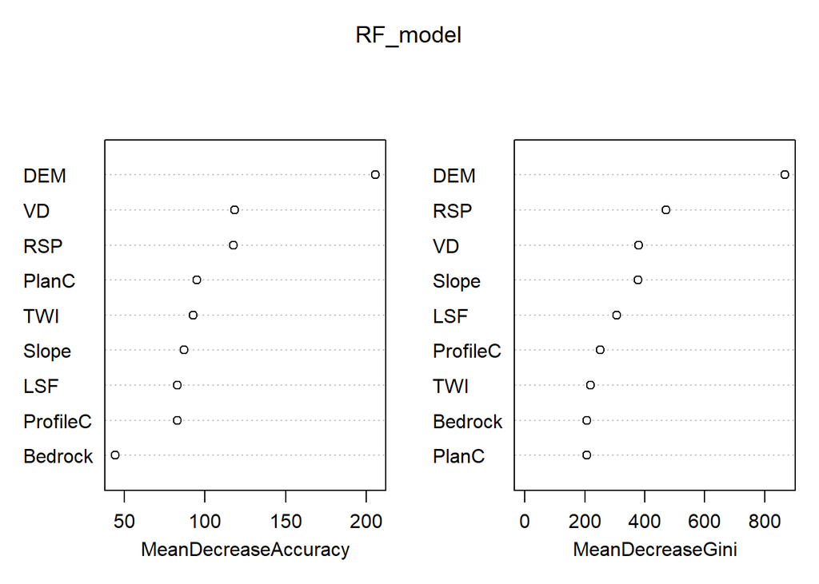

```r
sampleNum_dict[mn]<-nrow(sampData)

sampData$Bedrock<- droplevels(as.factor(sampData$Bedrock))
sampData$soilID<- droplevels(as.factor(sampData$soilID))

RF_model<-randomForest(soilID ~.,data = sampData,
                       importance = TRUE, proximity = FALSE,
                       ntree=1000,type="classification")

varImpPlot(RF_model)
```

```r
print(RF_model)
```

```
##
## Call:
##  randomForest(formula = soilID ~ ., data = sampData, importance = TRUE,      proximity = FALSE, ntree = 1000, type = "classification")
##                Type of random forest: classification
##                      Number of trees: 1000
## No. of variables tried at each split: 3
##
##         OOB estimate of  error rate: 17.98%
## Confusion matrix:
##      1  20  21  23   3 30  31 501 502 503   7 class.error
## 1   15   0   0   0   2  0   0   0   0   0   0   0.1176471
## 20   0 436  34   1   0  0   0   3   2  88  33   0.2696817
## 21   0  60 133   0   0  0   0   2   1  14   2   0.3726415
## 23   0   0   0 280   0 15   8   0   0  47  13   0.2286501
## 3    2   0   0   0 163  0   0  44   0   0   0   0.2200957
## 30   0   0   0  16   0 92   7   0   0   1   5   0.2396694
## 31   0   0   0  14   0  5 137   0   0   0   0   0.1217949
## 501  0   3   0   0  32  0   0 589   0   0  16   0.0796875
## 502  0   5   1   0   0  0   0   1  63   1   5   0.1710526
## 503  0  64   5  24   0  1   1   0   1 794  21   0.1284303
## 7    0  36   0   4   0  5   0  21   5  21 455   0.1681901
```

```r
map_RF <- predict(covStack, RF_model, paste(result_tif_folder,mn,".tif",sep=""),
                  format = "GTiff", datatype = "FLT4S", overwrite = TRUE)

rm("mn","shpPoint","sampData","RF_model","map_RF")
```

SNA ProfileC ns3 75

```r
mn="All_pSNA_ProfileC_NS3_pen75"

shpPoint<-readOGR(paste(point_shp_folder,mn,".shp",sep = "")) ###
sampData <- extract(covStack, shpPoint, sp = TRUE,method = "simple")

sampData<-sampData@data

sampData<-sampData[sampData$soilID %in% soil_type,]

sampData<-na.omit(sampData)

print(dim(sampData))
```

```
## [1] 4805   10
```

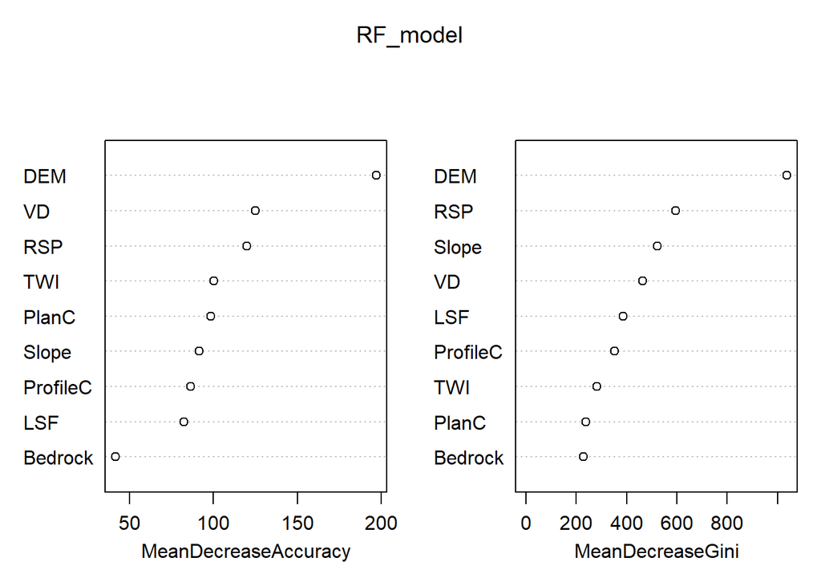

```r
sampleNum_dict[mn]<-nrow(sampData)

sampData$Bedrock<- droplevels(as.factor(sampData$Bedrock))
sampData$soilID<- droplevels(as.factor(sampData$soilID))

RF_model<-randomForest(soilID ~.,data = sampData,
                       importance = TRUE, proximity = FALSE,
                       ntree=1000,type="classification")

varImpPlot(RF_model)
```

```r
print(RF_model)
```

```
##
## Call:
##  randomForest(formula = soilID ~ ., data = sampData, importance = TRUE,      proximity = FALSE, ntree = 1000, type = "classification")
##                Type of random forest: classification
##                      Number of trees: 1000
## No. of variables tried at each split: 3
##
##         OOB estimate of  error rate: 19.13%
## Confusion matrix:
##      1  20  21  23   3  30  31 501 502 503   7 class.error
## 1   19   0   0   0   4   0   0   0   0   0   0  0.17391304
## 20   0 507  56   0   0   0   0   7   4 114  57  0.31946309
## 21   0  95 151   0   0   0   0   0   0  17   2  0.43018868
## 23   0   0   0 351   0  24   4   0   0  56  15  0.22000000
## 3    4   0   0   0 212   0   0  44   0   0   0  0.18461538
## 30   0   0   0  16   0 120   4   0   0   2   8  0.20000000
## 31   0   0   0   9   0   8 176   0   0   2   0  0.09743590
## 501  0   4   0   0  42   0   0 734   2   0  19  0.08364544
## 502  0   2   0   0   0   0   0   2  86   3   2  0.09473684
## 503  0  87   8  31   0   2   1   0   3 978  28  0.14059754
## 7    0  46   2   5   0   6   0  41   1  30 552  0.19180088
```

```r
map_RF <- predict(covStack, RF_model, paste(result_tif_folder,mn,".tif",sep=""),
                  format = "GTiff", datatype = "FLT4S", overwrite = TRUE)

rm("mn","shpPoint","sampData","RF_model","map_RF")
```

RAN ProfileC ns3 75

```r
mn="All_pRAN_ProfileC_NS3_pen75"

shpPoint<-readOGR(paste(point_shp_folder,mn,".shp",sep = "")) ###
sampData <- extract(covStack, shpPoint, sp = TRUE,method = "simple")

sampData<-sampData@data

sampData<-sampData[sampData$soilID %in% soil_type,]

sampData<-na.omit(sampData)

print(dim(sampData))
```

```
## [1] 4804   10
```

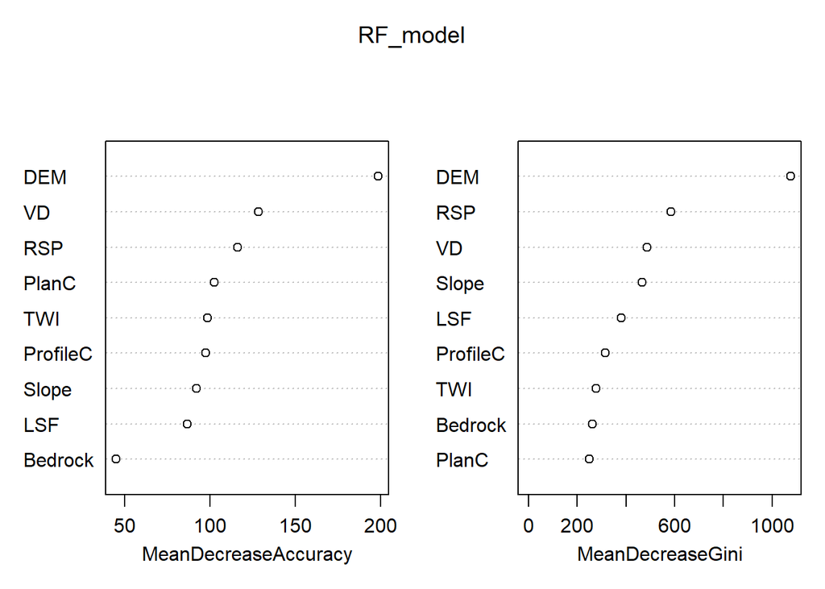

```r
sampleNum_dict[mn]<-nrow(sampData)

sampData$Bedrock<- droplevels(as.factor(sampData$Bedrock))
sampData$soilID<- droplevels(as.factor(sampData$soilID))

RF_model<-randomForest(soilID ~.,data = sampData,
                       importance = TRUE, proximity = FALSE,
                       ntree=1000,type="classification")

varImpPlot(RF_model)
```

```r
print(RF_model)
```

```
##
## Call:
##  randomForest(formula = soilID ~ ., data = sampData, importance = TRUE,      proximity = FALSE, ntree = 1000, type = "classification")
##                Type of random forest: classification
##                      Number of trees: 1000
## No. of variables tried at each split: 3
##
##         OOB estimate of  error rate: 16.72%
## Confusion matrix:
##      1  20  21  23   3  30  31 501 502 503   7 class.error
## 1   19   0   0   0   3   0   0   0   0   0   0  0.13636364
## 20   0 557  42   3   0   0   0   5   3  93  42  0.25234899
## 21   0  76 171   0   0   0   0   0   1  16   1  0.35471698
## 23   0   2   0 360   0  20   3   0   0  51  14  0.20000000
## 3    2   0   0   0 210   0   0  48   0   0   0  0.19230769
## 30   0   0   0  15   0 121   9   0   0   1   4  0.19333333
## 31   0   0   0  17   0   3 174   0   0   1   0  0.10769231
## 501  0   5   0   0  30   0   0 746   2   0  18  0.06866417
## 502  0   1   1   0   0   0   0   1  82   2   8  0.13684211
## 503  0  79   4  36   0   0   1   0   3 990  25  0.13005272
## 7    0  40   0   6   0   4   0  24   6  32 571  0.16398243
```

```r
map_RF <- predict(covStack, RF_model, paste(result_tif_folder,mn,".tif",sep=""),
                  format = "GTiff", datatype = "FLT4S", overwrite = TRUE)

rm("mn","shpPoint","sampData","RF_model","map_RF")
```

SNA ProfileC ns5 15

```r
mn="All_pSNA_ProfileC_NS5_pen15"

shpPoint<-readOGR(paste(point_shp_folder,mn,".shp",sep = "")) ###
sampData <- extract(covStack, shpPoint, sp = TRUE,method = "simple")

sampData<-sampData@data

sampData<-sampData[sampData$soilID %in% soil_type,]

sampData<-na.omit(sampData)

print(dim(sampData))
```

```
## [1] 338  10
```

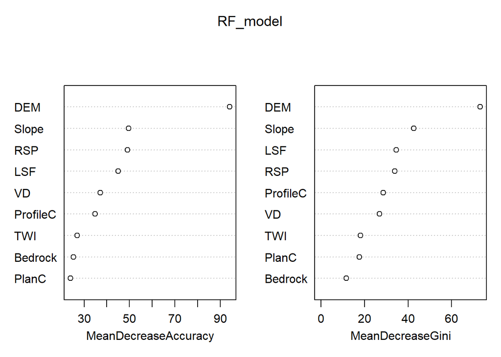

```r
sampleNum_dict[mn]<-nrow(sampData)

sampData$Bedrock<- droplevels(as.factor(sampData$Bedrock))
sampData$soilID<- droplevels(as.factor(sampData$soilID))

RF_model<-randomForest(soilID ~.,data = sampData,
                       importance = TRUE, proximity = FALSE,
                       ntree=1000,type="classification")

varImpPlot(RF_model)
```

```r
print(RF_model)
```

```
##
## Call:
##  randomForest(formula = soilID ~ ., data = sampData, importance = TRUE,      proximity = FALSE, ntree = 1000, type = "classification")
##                Type of random forest: classification
##                      Number of trees: 1000
## No. of variables tried at each split: 3
##
##         OOB estimate of  error rate: 23.96%
## Confusion matrix:
##     20 21 23  3 30 31 501 502 503  7 class.error
## 20  28  4  0  0  0  0   0   0   7  7  0.39130435
## 21  13  7  0  0  0  0   0   0   3  0  0.69565217
## 23   0  0 21  0  1  0   0   0   5  1  0.25000000
## 3    0  0  0 16  0  0   2   0   0  0  0.11111111
## 30   0  0  3  0  4  0   0   0   0  2  0.55555556
## 31   0  0  0  0  0 14   0   0   0  0  0.00000000
## 501  0  0  0  4  0  0  54   0   0  1  0.08474576
## 502  0  0  0  0  0  0   1   4   0  2  0.42857143
## 503  5  4  2  0  0  0   0   0  68  3  0.17073171
## 7    2  0  1  0  0  0   3   0   5 41  0.21153846
```

```r
map_RF <- predict(covStack, RF_model, paste(result_tif_folder,mn,".tif",sep=""),
                  format = "GTiff", datatype = "FLT4S", overwrite = TRUE)

rm("mn","shpPoint","sampData","RF_model","map_RF")
```

RAN ProfileC ns5 15

```r
mn="All_pRAN_ProfileC_NS5_pen15"

shpPoint<-readOGR(paste(point_shp_folder,mn,".shp",sep = "")) ###
sampData <- extract(covStack, shpPoint, sp = TRUE,method = "simple")

sampData<-sampData@data

sampData<-sampData[sampData$soilID %in% soil_type,]

sampData<-na.omit(sampData)

print(dim(sampData))
```

```
## [1] 340  10
```

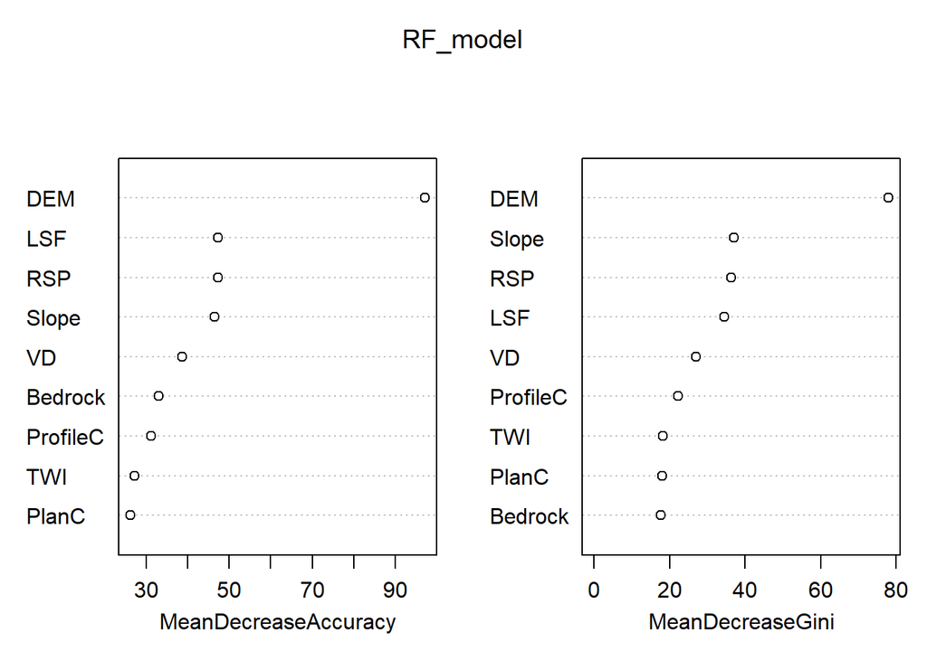

```r
sampleNum_dict[mn]<-nrow(sampData)

sampData$Bedrock<- droplevels(as.factor(sampData$Bedrock))
sampData$soilID<- droplevels(as.factor(sampData$soilID))

RF_model<-randomForest(soilID ~.,data = sampData,
                       importance = TRUE, proximity = FALSE,
                       ntree=1000,type="classification")

varImpPlot(RF_model)
```

```r
print(RF_model)
```

```
##
## Call:
##  randomForest(formula = soilID ~ ., data = sampData, importance = TRUE,      proximity = FALSE, ntree = 1000, type = "classification")
##                Type of random forest: classification
##                      Number of trees: 1000
## No. of variables tried at each split: 3
##
##         OOB estimate of  error rate: 22.35%
## Confusion matrix:
##     1 20 21 23  3 30 31 501 502 503  7 class.error
## 1   0  0  0  0  2  0  0   0   0   0  0  1.00000000
## 20  0 26  6  0  0  0  0   0   1   8  5  0.43478261
## 21  0  7 15  0  0  0  0   0   0   1  0  0.34782609
## 23  0  0  0 20  0  3  1   0   0   3  1  0.28571429
## 3   0  0  0  0 15  0  0   3   0   0  0  0.16666667
## 30  0  0  0  3  0  5  0   0   0   0  1  0.44444444
## 31  0  0  0  3  0  0 11   0   0   0  0  0.21428571
## 501 0  0  0  0  5  0  0  52   1   0  1  0.11864407
## 502 0  2  0  0  0  0  0   2   2   0  1  0.71428571
## 503 0  4  0  3  0  0  0   0   0  74  1  0.09756098
## 7   0  3  0  0  0  0  0   1   0   4 44  0.15384615
```

```r
map_RF <- predict(covStack, RF_model, paste(result_tif_folder,mn,".tif",sep=""),
                  format = "GTiff", datatype = "FLT4S", overwrite = TRUE)

rm("mn","shpPoint","sampData","RF_model","map_RF")
```

SNA ProfileC ns5 30

```r
mn="All_pSNA_ProfileC_NS5_pen30"

shpPoint<-readOGR(paste(point_shp_folder,mn,".shp",sep = "")) ###
sampData <- extract(covStack, shpPoint, sp = TRUE,method = "simple")

sampData<-sampData@data

sampData<-sampData[sampData$soilID %in% soil_type,]

sampData<-na.omit(sampData)

print(dim(sampData))
```

```
## [1] 636  10
```

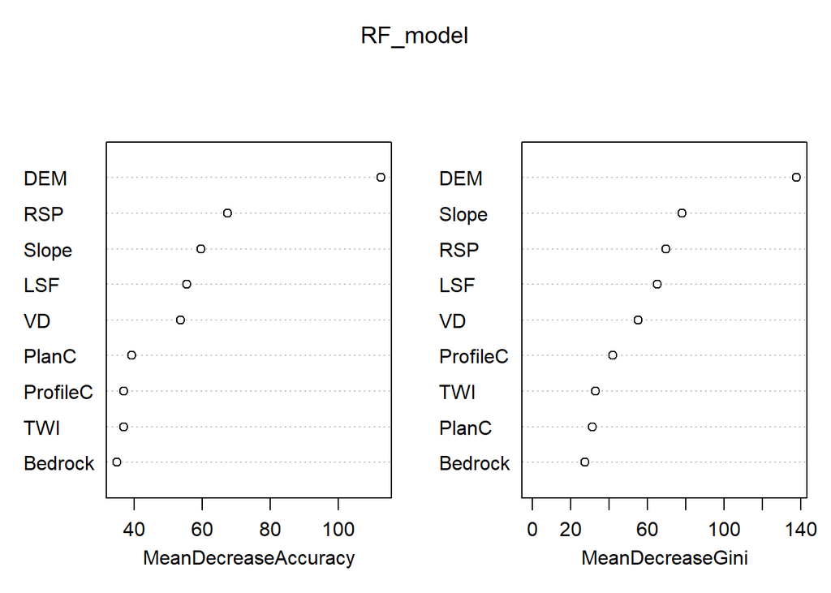

```r
sampleNum_dict[mn]<-nrow(sampData)

sampData$Bedrock<- droplevels(as.factor(sampData$Bedrock))
sampData$soilID<- droplevels(as.factor(sampData$soilID))

RF_model<-randomForest(soilID ~.,data = sampData,
                       importance = TRUE, proximity = FALSE,
                       ntree=1000,type="classification")

varImpPlot(RF_model)
```

```r
print(RF_model)
```

```
##
## Call:
##  randomForest(formula = soilID ~ ., data = sampData, importance = TRUE,      proximity = FALSE, ntree = 1000, type = "classification")
##                Type of random forest: classification
##                      Number of trees: 1000
## No. of variables tried at each split: 3
##
##         OOB estimate of  error rate: 20.91%
## Confusion matrix:
##     1 20 21 23  3 30 31 501 502 503  7 class.error
## 1   1  0  0  0  1  0  0   0   0   0  0  0.50000000
## 20  0 50  9  0  0  0  0   0   0  14 11  0.40476190
## 21  0 12 21  0  0  0  0   0   0   2  0  0.40000000
## 23  0  0  0 40  0  2  2   0   0   8  1  0.24528302
## 3   1  0  0  0 31  0  0   3   0   0  0  0.11428571
## 30  0  0  0  3  0 12  0   0   0   0  0  0.20000000
## 31  0  0  0  0  0  0 27   0   0   0  0  0.00000000
## 501 0  0  0  0  6  0  0 109   0   0  2  0.06837607
## 502 0  3  0  0  0  0  0   3   6   0  2  0.57142857
## 503 0 13  2  5  0  0  0   0   0 132  6  0.16455696
## 7   0  3  0  0  0  2  0   8   0   9 74  0.22916667
```

```r
map_RF <- predict(covStack, RF_model, paste(result_tif_folder,mn,".tif",sep=""),
                  format = "GTiff", datatype = "FLT4S", overwrite = TRUE)

rm("mn","shpPoint","sampData","RF_model","map_RF")
```

RAN ProfileC ns5 30

```r
mn="All_pRAN_ProfileC_NS5_pen30"

shpPoint<-readOGR(paste(point_shp_folder,mn,".shp",sep = "")) ###
sampData <- extract(covStack, shpPoint, sp = TRUE,method = "simple")

sampData<-sampData@data

sampData<-sampData[sampData$soilID %in% soil_type,]

sampData<-na.omit(sampData)

print(dim(sampData))
```

```
## [1] 638  10
```

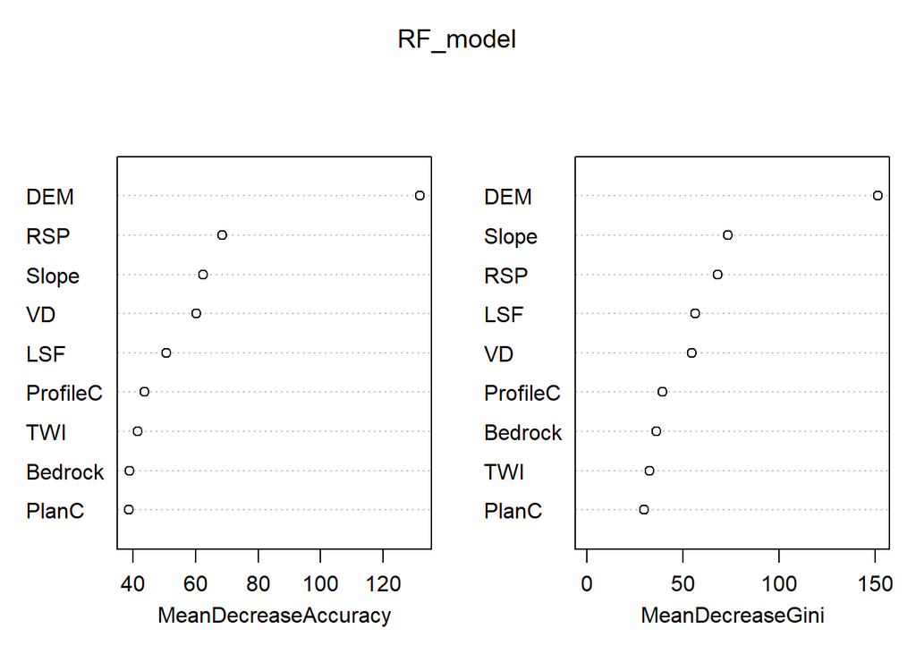

```r
sampleNum_dict[mn]<-nrow(sampData)

sampData$Bedrock<- droplevels(as.factor(sampData$Bedrock))
sampData$soilID<- droplevels(as.factor(sampData$soilID))

RF_model<-randomForest(soilID ~.,data = sampData,
                       importance = TRUE, proximity = FALSE,
                       ntree=1000,type="classification")

varImpPlot(RF_model)
```

```r
print(RF_model)
```

```
##
## Call:
##  randomForest(formula = soilID ~ ., data = sampData, importance = TRUE,      proximity = FALSE, ntree = 1000, type = "classification")
##                Type of random forest: classification
##                      Number of trees: 1000
## No. of variables tried at each split: 3
##
##         OOB estimate of  error rate: 18.34%
## Confusion matrix:
##     1 20 21 23  3 30 31 501 502 503  7 class.error
## 1   3  0  0  0  1  0  0   0   0   0  0  0.25000000
## 20  0 57  6  0  0  0  0   2   0   9 10  0.32142857
## 21  0 15 19  0  0  0  0   0   0   1  0  0.45714286
## 23  0  0  0 40  0  2  1   0   0   9  1  0.24528302
## 3   0  0  0  0 29  0  0   6   0   0  0  0.17142857
## 30  0  0  0  1  0 12  1   0   0   0  1  0.20000000
## 31  0  0  0  3  0  0 24   0   0   0  0  0.11111111
## 501 0  0  0  0  6  0  0 109   0   0  2  0.06837607
## 502 0  3  0  0  0  0  0   0   9   0  2  0.35714286
## 503 0  6  1  7  0  0  0   0   0 138  6  0.12658228
## 7   0  8  0  0  0  1  0   3   0   3 81  0.15625000
```

```r
map_RF <- predict(covStack, RF_model, paste(result_tif_folder,mn,".tif",sep=""),
                  format = "GTiff", datatype = "FLT4S", overwrite = TRUE)

rm("mn","shpPoint","sampData","RF_model","map_RF")
```

SNA ProfileC ns5 45

```r
mn="All_pSNA_ProfileC_NS5_pen45"

shpPoint<-readOGR(paste(point_shp_folder,mn,".shp",sep = "")) ###
sampData <- extract(covStack, shpPoint, sp = TRUE,method = "simple")

sampData<-sampData@data

sampData<-sampData[sampData$soilID %in% soil_type,]

sampData<-na.omit(sampData)

print(dim(sampData))
```

```
## [1] 934  10
```

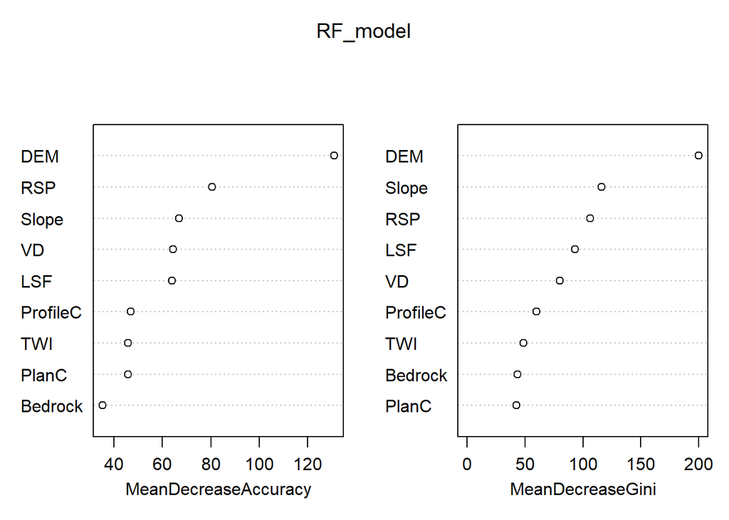

```r
sampleNum_dict[mn]<-nrow(sampData)

sampData$Bedrock<- droplevels(as.factor(sampData$Bedrock))
sampData$soilID<- droplevels(as.factor(sampData$soilID))

RF_model<-randomForest(soilID ~.,data = sampData,
                       importance = TRUE, proximity = FALSE,
                       ntree=1000,type="classification")

varImpPlot(RF_model)
```

```r
print(RF_model)
```

```
##
## Call:
##  randomForest(formula = soilID ~ ., data = sampData, importance = TRUE,      proximity = FALSE, ntree = 1000, type = "classification")
##                Type of random forest: classification
##                      Number of trees: 1000
## No. of variables tried at each split: 3
##
##         OOB estimate of  error rate: 19.7%
## Confusion matrix:
##     1 20 21 23  3 30 31 501 502 503   7 class.error
## 1   3  0  0  0  0  0  0   0   0   0   0  0.00000000
## 20  0 70 12  0  0  0  0   0   0  23  16  0.42148760
## 21  0 16 30  0  0  0  0   0   0   2   0  0.37500000
## 23  0  0  0 61  0  3  3   0   0   9   2  0.21794872
## 3   0  0  0  0 46  0  0   6   0   0   0  0.11538462
## 30  0  0  0  4  0 17  1   0   0   0   0  0.22727273
## 31  0  0  0  3  0  0 38   0   0   0   0  0.07317073
## 501 0  2  0  0  9  0  0 162   0   0   2  0.07428571
## 502 0  3  0  0  1  0  0   3  10   1   2  0.50000000
## 503 0 18  2  5  0  0  0   0   0 203   7  0.13617021
## 7   0  7  0  1  0  1  0  11   1   8 110  0.20863309
```

```r
map_RF <- predict(covStack, RF_model, paste(result_tif_folder,mn,".tif",sep=""),
                  format = "GTiff", datatype = "FLT4S", overwrite = TRUE)

rm("mn","shpPoint","sampData","RF_model","map_RF")
```

RAN ProfileC ns5 45

```r
mn="All_pRAN_ProfileC_NS5_pen45"

shpPoint<-readOGR(paste(point_shp_folder,mn,".shp",sep = "")) ###
sampData <- extract(covStack, shpPoint, sp = TRUE,method = "simple")

sampData<-sampData@data

sampData<-sampData[sampData$soilID %in% soil_type,]

sampData<-na.omit(sampData)

print(dim(sampData))
```

```
## [1] 936  10
```

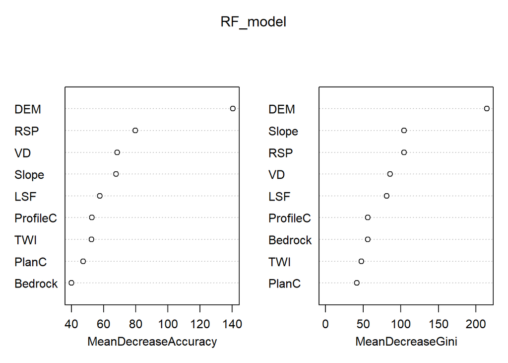

```r
sampleNum_dict[mn]<-nrow(sampData)

sampData$Bedrock<- droplevels(as.factor(sampData$Bedrock))
sampData$soilID<- droplevels(as.factor(sampData$soilID))

RF_model<-randomForest(soilID ~.,data = sampData,
                       importance = TRUE, proximity = FALSE,
                       ntree=1000,type="classification")

varImpPlot(RF_model)
```

```r
print(RF_model)
```

```
##
## Call:
##  randomForest(formula = soilID ~ ., data = sampData, importance = TRUE,      proximity = FALSE, ntree = 1000, type = "classification")
##                Type of random forest: classification
##                      Number of trees: 1000
## No. of variables tried at each split: 3
##
##         OOB estimate of  error rate: 18.48%
## Confusion matrix:
##     1 20 21 23  3 30 31 501 502 503   7 class.error
## 1   3  0  0  0  2  0  0   0   0   0   0  0.40000000
## 20  0 85  8  0  0  0  0   1   0  13  14  0.29752066
## 21  0 14 30  0  0  0  0   0   1   3   0  0.37500000
## 23  0  0  0 52  0  7  2   0   0  15   2  0.33333333
## 3   1  0  0  0 43  0  0   8   0   0   0  0.17307692
## 30  0  0  0  5  0 14  0   0   0   0   3  0.36363636
## 31  0  0  0  4  0  0 37   0   0   0   0  0.09756098
## 501 0  0  0  0  8  0  0 165   1   0   1  0.05714286
## 502 0  3  2  0  0  0  0   2  13   0   0  0.35000000
## 503 0  9  2  6  0  0  0   0   0 212   6  0.09787234
## 7   0 10  0  2  0  3  0   6   0   9 109  0.21582734
```

```r
map_RF <- predict(covStack, RF_model, paste(result_tif_folder,mn,".tif",sep=""),
                  format = "GTiff", datatype = "FLT4S", overwrite = TRUE)

rm("mn","shpPoint","sampData","RF_model","map_RF")
```

SNA ProfileC ns5 60

```r
mn="All_pSNA_ProfileC_NS5_pen60"

shpPoint<-readOGR(paste(point_shp_folder,mn,".shp",sep = "")) ###
sampData <- extract(covStack, shpPoint, sp = TRUE,method = "simple")

sampData<-sampData@data

sampData<-sampData[sampData$soilID %in% soil_type,]

sampData<-na.omit(sampData)

print(dim(sampData))
```

```
## [1] 1242   10
```

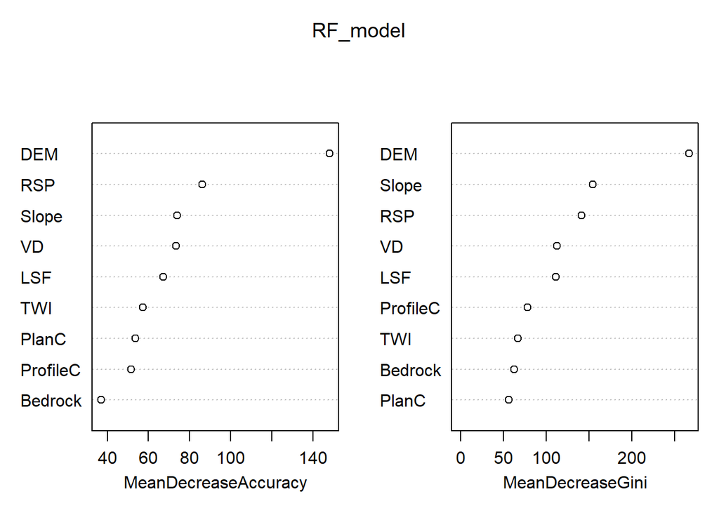

```r
sampleNum_dict[mn]<-nrow(sampData)

sampData$Bedrock<- droplevels(as.factor(sampData$Bedrock))
sampData$soilID<- droplevels(as.factor(sampData$soilID))

RF_model<-randomForest(soilID ~.,data = sampData,
                       importance = TRUE, proximity = FALSE,
                       ntree=1000,type="classification")

varImpPlot(RF_model)
```

```r
print(RF_model)
```

```
##
## Call:
##  randomForest(formula = soilID ~ ., data = sampData, importance = TRUE,      proximity = FALSE, ntree = 1000, type = "classification")
##                Type of random forest: classification
##                      Number of trees: 1000
## No. of variables tried at each split: 3
##
##         OOB estimate of  error rate: 17.95%
## Confusion matrix:
##     1  20 21 23  3 30 31 501 502 503   7 class.error
## 1   3   0  0  0  2  0  0   0   0   0   0  0.40000000
## 20  0 105 12  0  0  0  0   2   0  25  16  0.34375000
## 21  0  20 40  0  0  0  0   0   0   2   0  0.35483871
## 23  0   0  0 81  0  6  2   0   0  11   4  0.22115385
## 3   1   0  0  0 62  0  0   7   0   0   0  0.11428571
## 30  0   0  0  7  0 21  0   0   0   0   0  0.25000000
## 31  0   0  0  2  0  0 52   0   0   0   0  0.03703704
## 501 0   2  0  0 14  0  0 214   0   0   4  0.08547009
## 502 0   2  0  0  1  0  0   4  16   1   3  0.40740741
## 503 0  20  2  8  0  0  0   0   0 274   8  0.12179487
## 7   0   9  0  0  0  1  0  12   1  12 151  0.18817204
```

```r
map_RF <- predict(covStack, RF_model, paste(result_tif_folder,mn,".tif",sep=""),
                  format = "GTiff", datatype = "FLT4S", overwrite = TRUE)

rm("mn","shpPoint","sampData","RF_model","map_RF")
```

RAN ProfileC ns5 60

```r
mn="All_pRAN_ProfileC_NS5_pen60"

shpPoint<-readOGR(paste(point_shp_folder,mn,".shp",sep = "")) ###
sampData <- extract(covStack, shpPoint, sp = TRUE,method = "simple")

sampData<-sampData@data

sampData<-sampData[sampData$soilID %in% soil_type,]

sampData<-na.omit(sampData)

print(dim(sampData))
```

```
## [1] 1244   10
```

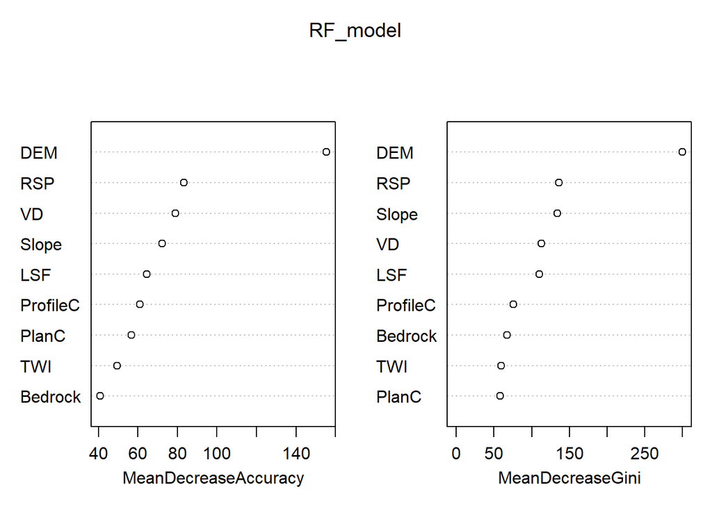

```r
sampleNum_dict[mn]<-nrow(sampData)

sampData$Bedrock<- droplevels(as.factor(sampData$Bedrock))
sampData$soilID<- droplevels(as.factor(sampData$soilID))

RF_model<-randomForest(soilID ~.,data = sampData,
                       importance = TRUE, proximity = FALSE,
                       ntree=1000,type="classification")

varImpPlot(RF_model)
```

```r
print(RF_model)
```

```
##
## Call:
##  randomForest(formula = soilID ~ ., data = sampData, importance = TRUE,      proximity = FALSE, ntree = 1000, type = "classification")
##                Type of random forest: classification
##                      Number of trees: 1000
## No. of variables tried at each split: 3
##
##         OOB estimate of  error rate: 17.12%
## Confusion matrix:
##     1  20 21 23  3 30 31 501 502 503   7 class.error
## 1   7   0  0  0  0  0  0   0   0   0   0  0.00000000
## 20  0 112 10  0  0  0  0   1   0  18  19  0.30000000
## 21  0  16 44  0  0  0  0   0   1   1   0  0.29032258
## 23  0   0  0 72  0  8  5   0   0  16   3  0.30769231
## 3   1   0  0  0 54  0  0  15   0   0   0  0.22857143
## 30  0   0  0  7  0 18  1   0   0   0   2  0.35714286
## 31  0   0  0  5  0  2 47   0   0   0   0  0.12962963
## 501 0   0  0  0 11  0  0 219   0   0   4  0.06410256
## 502 0   4  3  0  0  0  0   3  17   0   0  0.37037037
## 503 0  14  3  8  0  0  0   0   0 281   6  0.09935897
## 7   0  12  0  2  0  1  0   3   1   7 160  0.13978495
```

```r
map_RF <- predict(covStack, RF_model, paste(result_tif_folder,mn,".tif",sep=""),
                  format = "GTiff", datatype = "FLT4S", overwrite = TRUE)

rm("mn","shpPoint","sampData","RF_model","map_RF")
```

SNA ProfileC ns5 75

```r
mn="All_pSNA_ProfileC_NS5_pen75"

shpPoint<-readOGR(paste(point_shp_folder,mn,".shp",sep = "")) ###
sampData <- extract(covStack, shpPoint, sp = TRUE,method = "simple")

sampData<-sampData@data

sampData<-sampData[sampData$soilID %in% soil_type,]

sampData<-na.omit(sampData)

print(dim(sampData))
```

```
## [1] 1540   10
```

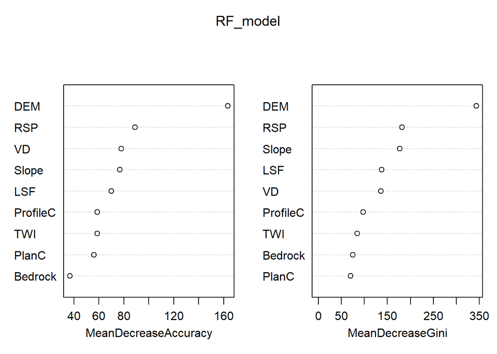

```r
sampleNum_dict[mn]<-nrow(sampData)

sampData$Bedrock<- droplevels(as.factor(sampData$Bedrock))
sampData$soilID<- droplevels(as.factor(sampData$soilID))

RF_model<-randomForest(soilID ~.,data = sampData,
                       importance = TRUE, proximity = FALSE,
                       ntree=1000,type="classification")

varImpPlot(RF_model)
```

```r
print(RF_model)
```

```
##
## Call:
##  randomForest(formula = soilID ~ ., data = sampData, importance = TRUE,      proximity = FALSE, ntree = 1000, type = "classification")
##                Type of random forest: classification
##                      Number of trees: 1000
## No. of variables tried at each split: 3
##
##         OOB estimate of  error rate: 18.12%
## Confusion matrix:
##     1  20 21 23  3 30 31 501 502 503   7 class.error
## 1   4   0  0  0  2  0  0   0   0   0   0  0.33333333
## 20  0 137 14  0  0  0  0   3   0  26  19  0.31155779
## 21  0  21 51  0  0  0  0   0   0   2   0  0.31081081
## 23  0   0  0 93  0  6  6   0   0  19   5  0.27906977
## 3   1   0  0  0 75  0  0  11   0   0   0  0.13793103
## 30  0   0  0  8  0 25  0   0   0   0   2  0.28571429
## 31  0   0  0  2  0  1 64   0   0   0   0  0.04477612
## 501 0   3  0  0 16  0  0 268   1   0   4  0.08219178
## 502 0   4  1  0  0  0  0   6  16   1   4  0.50000000
## 503 0  22  2 13  0  0  0   0   0 341  10  0.12113402
## 7   0  15  0  4  0  1  0  11   1  12 187  0.19047619
```

```r
map_RF <- predict(covStack, RF_model, paste(result_tif_folder,mn,".tif",sep=""),
                  format = "GTiff", datatype = "FLT4S", overwrite = TRUE)

rm("mn","shpPoint","sampData","RF_model","map_RF")
```

RAN ProfileC ns5 75

```r
mn="All_pRAN_ProfileC_NS5_pen75"

shpPoint<-readOGR(paste(point_shp_folder,mn,".shp",sep = "")) ###
sampData <- extract(covStack, shpPoint, sp = TRUE,method = "simple")

sampData<-sampData@data

sampData<-sampData[sampData$soilID %in% soil_type,]

sampData<-na.omit(sampData)

print(dim(sampData))
```

```
## [1] 1542   10
```

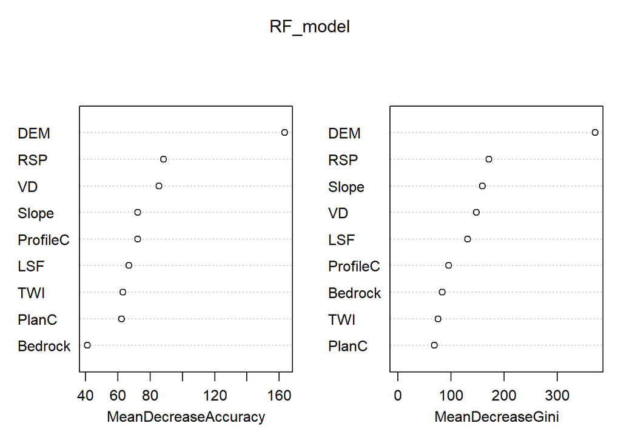

```r
sampleNum_dict[mn]<-nrow(sampData)

sampData$Bedrock<- droplevels(as.factor(sampData$Bedrock))
sampData$soilID<- droplevels(as.factor(sampData$soilID))

RF_model<-randomForest(soilID ~.,data = sampData,
                       importance = TRUE, proximity = FALSE,
                       ntree=1000,type="classification")

varImpPlot(RF_model)
```

```r
print(RF_model)
```

```
##
## Call:
##  randomForest(formula = soilID ~ ., data = sampData, importance = TRUE,      proximity = FALSE, ntree = 1000, type = "classification")
##                Type of random forest: classification
##                      Number of trees: 1000
## No. of variables tried at each split: 3
##
##         OOB estimate of  error rate: 14.2%
## Confusion matrix:
##     1  20 21 23  3 30 31 501 502 503   7 class.error
## 1   7   0  0  0  1  0  0   0   0   0   0  0.12500000
## 20  0 151  9  0  0  0  0   1   2  21  15  0.24120603
## 21  0  15 55  0  0  0  0   0   1   3   0  0.25675676
## 23  0   0  0 96  0  6  3   0   0  20   4  0.25581395
## 3   1   0  0  0 74  0  0  12   0   0   0  0.14942529
## 30  0   0  0  9  0 24  1   0   0   0   1  0.31428571
## 31  0   0  0  4  0  1 62   0   0   0   0  0.07462687
## 501 0   2  0  0 12  0  0 277   0   0   1  0.05136986
## 502 0   6  1  0  0  0  0   2  23   0   0  0.28125000
## 503 0  10  3 12  0  0  0   0   0 355   8  0.08505155
## 7   0  13  0  3  0  0  0   4   1  11 199  0.13852814
```

```r
map_RF <- predict(covStack, RF_model, paste(result_tif_folder,mn,".tif",sep=""),
                  format = "GTiff", datatype = "FLT4S", overwrite = TRUE)

rm("mn","shpPoint","sampData","RF_model","map_RF")
```

# TWI

SNA TWI ns3 15

```r
mn="All_pSNA_TWI_NS3_pen15"

shpPoint<-readOGR(paste(point_shp_folder,mn,".shp",sep = "")) ###
sampData <- extract(covStack, shpPoint, sp = TRUE,method = "simple")

sampData<-sampData@data

sampData<-sampData[sampData$soilID %in% soil_type,]

sampData<-na.omit(sampData)

print(dim(sampData))
```

```
## [1] 983  10
```

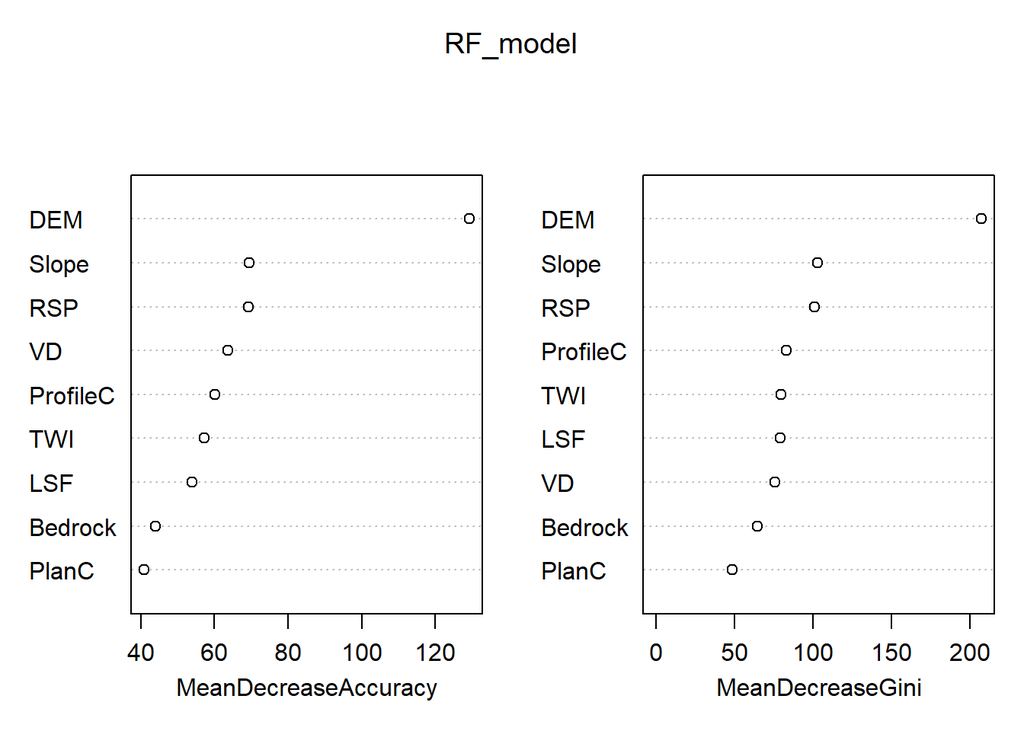

```r
sampleNum_dict[mn]<-nrow(sampData)

sampData$Bedrock<- droplevels(as.factor(sampData$Bedrock))
sampData$soilID<- droplevels(as.factor(sampData$soilID))

RF_model<-randomForest(soilID ~.,data = sampData,
                       importance = TRUE, proximity = FALSE,
                       ntree=1000,type="classification")

varImpPlot(RF_model)
```

```r
print(RF_model)
```

```
##
## Call:
##  randomForest(formula = soilID ~ ., data = sampData, importance = TRUE,      proximity = FALSE, ntree = 1000, type = "classification")
##                Type of random forest: classification
##                      Number of trees: 1000
## No. of variables tried at each split: 3
##
##         OOB estimate of  error rate: 22.48%
## Confusion matrix:
##     1 20 21 23  3 30 31 501 502 503   7 class.error
## 1   6  0  0  0  0  0  0   0   0   0   0  0.00000000
## 20  0 86 17  1  0  0  0   1   0  32  14  0.43046358
## 21  0 25 22  0  0  0  0   0   0   7   1  0.60000000
## 23  0  0  0 89  0  3  1   0   0   7   1  0.11881188
## 3   0  0  0  0 37  0  0  13   0   0   0  0.26000000
## 30  0  0  0  5  0 23  3   0   0   0   2  0.30303030
## 31  0  0  0  0  0  1 41   0   0   0   0  0.02380952
## 501 0  1  0  0 11  0  0 140   2   0   3  0.10828025
## 502 0  0  0  0  0  0  0   3  14   0   3  0.30000000
## 503 0 21  4  9  0  0  0   0   0 191   3  0.16228070
## 7   0 14  1  1  0  1  0   4   1   5 113  0.19285714
```

```r
map_RF <- predict(covStack, RF_model, paste(result_tif_folder,mn,".tif",sep=""),
                  format = "GTiff", datatype = "FLT4S", overwrite = TRUE)

rm("mn","shpPoint","sampData","RF_model","map_RF")
```

RAN TWI ns3 15

```r
mn="All_pRAN_TWI_NS3_pen15"

shpPoint<-readOGR(paste(point_shp_folder,mn,".shp",sep = "")) ###
sampData <- extract(covStack, shpPoint, sp = TRUE,method = "simple")

sampData<-sampData@data

sampData<-sampData[sampData$soilID %in% soil_type,]

sampData<-na.omit(sampData)

print(dim(sampData))
```

```
## [1] 983  10
```

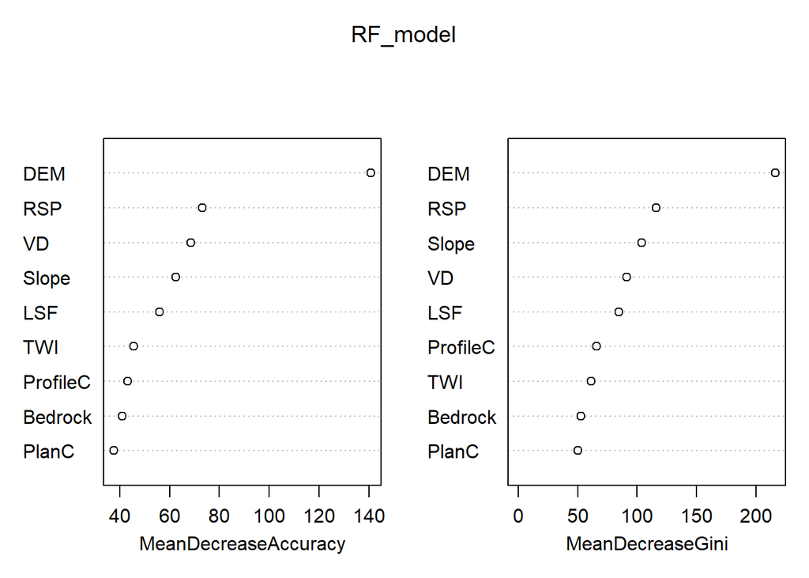

```r
sampleNum_dict[mn]<-nrow(sampData)

sampData$Bedrock<- droplevels(as.factor(sampData$Bedrock))
sampData$soilID<- droplevels(as.factor(sampData$soilID))

RF_model<-randomForest(soilID ~.,data = sampData,
                       importance = TRUE, proximity = FALSE,
                       ntree=1000,type="classification")

varImpPlot(RF_model)
```

```r
print(RF_model)
```

```
##
## Call:
##  randomForest(formula = soilID ~ ., data = sampData, importance = TRUE,      proximity = FALSE, ntree = 1000, type = "classification")
##                Type of random forest: classification
##                      Number of trees: 1000
## No. of variables tried at each split: 3
##
##         OOB estimate of  error rate: 27.67%
## Confusion matrix:
##     1 20 21 23  3 30 31 501 502 503   7 class.error
## 1   4  0  0  0  2  0  0   0   0   0   0   0.3333333
## 20  0 88 18  1  0  0  0   3   0  26  15   0.4172185
## 21  0 25 26  0  0  0  0   1   1   2   0   0.5272727
## 23  0  0  0 63  0 10  3   0   0  20   5   0.3762376
## 3   0  0  0  0 38  0  0  12   0   0   0   0.2400000
## 30  0  0  0  9  0 18  4   0   0   0   2   0.4545455
## 31  0  0  0  8  0  2 32   0   0   0   0   0.2380952
## 501 0  0  0  0 11  0  0 138   1   0   7   0.1210191
## 502 0  6  0  0  0  0  0   3   8   1   2   0.6000000
## 503 0 15  0 11  0  1  0   0   1 193   7   0.1535088
## 7   0 13  0  1  0  3  0   9   2   9 103   0.2642857
```

```r
map_RF <- predict(covStack, RF_model, paste(result_tif_folder,mn,".tif",sep=""),
                  format = "GTiff", datatype = "FLT4S", overwrite = TRUE)

rm("mn","shpPoint","sampData","RF_model","map_RF")
```

SNA TWI ns3 30

```r
mn="All_pSNA_TWI_NS3_pen30"

shpPoint<-readOGR(paste(point_shp_folder,mn,".shp",sep = "")) ###
sampData <- extract(covStack, shpPoint, sp = TRUE,method = "simple")

sampData<-sampData@data

sampData<-sampData[sampData$soilID %in% soil_type,]

sampData<-na.omit(sampData)

print(dim(sampData))
```

```
## [1] 1919   10
```

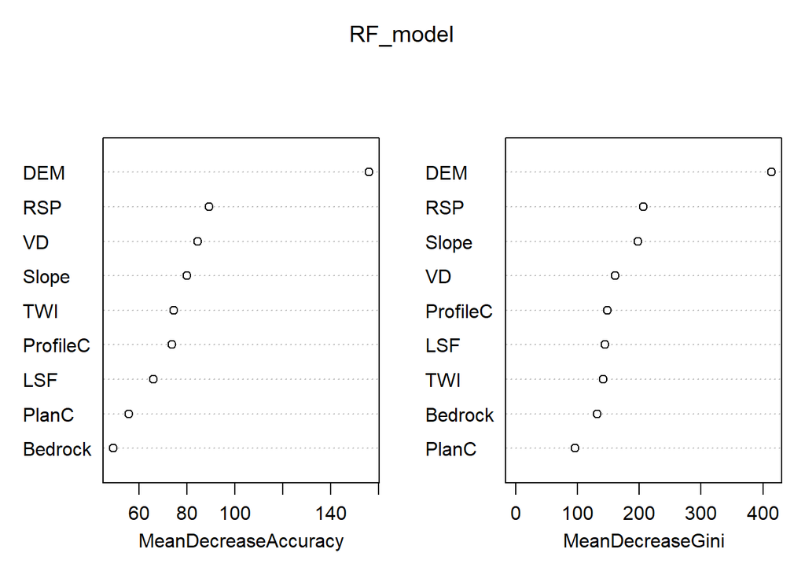

```r
sampleNum_dict[mn]<-nrow(sampData)

sampData$Bedrock<- droplevels(as.factor(sampData$Bedrock))
sampData$soilID<- droplevels(as.factor(sampData$soilID))

RF_model<-randomForest(soilID ~.,data = sampData,
                       importance = TRUE, proximity = FALSE,
                       ntree=1000,type="classification")

varImpPlot(RF_model)
```

```r
print(RF_model)
```

```
##
## Call:
##  randomForest(formula = soilID ~ ., data = sampData, importance = TRUE,      proximity = FALSE, ntree = 1000, type = "classification")
##                Type of random forest: classification
##                      Number of trees: 1000
## No. of variables tried at each split: 3
##
##         OOB estimate of  error rate: 21.05%
## Confusion matrix:
##     1  20 21  23  3 30 31 501 502 503   7 class.error
## 1   9   0  0   0  2  0  0   0   0   0   0  0.18181818
## 20  0 185 23   2  0  0  0   1   0  53  30  0.37074830
## 21  0  38 53   0  0  0  0   0   1  11   1  0.49038462
## 23  0   0  0 163  0  8  5   0   0  17   0  0.15544041
## 3   3   0  0   0 66  0  0  30   0   0   0  0.33333333
## 30  0   0  0  11  0 43  3   0   0   0   6  0.31746032
## 31  0   0  0   5  0  1 75   0   0   2   0  0.09638554
## 501 0   1  0   0 26  0  0 276   2   0   8  0.11821086
## 502 0   1  0   0  0  0  0   1  30   0   6  0.21052632
## 503 0  31  6  22  0  0  0   0   0 386   4  0.14031180
## 7   0  15  1   1  0  3  0  11   4   8 229  0.15808824
```

```r
map_RF <- predict(covStack, RF_model, paste(result_tif_folder,mn,".tif",sep=""),
                  format = "GTiff", datatype = "FLT4S", overwrite = TRUE)

rm("mn","shpPoint","sampData","RF_model","map_RF")
```

RAN TWI ns3 30

```r
mn="All_pRAN_TWI_NS3_pen30"

shpPoint<-readOGR(paste(point_shp_folder,mn,".shp",sep = "")) ###
sampData <- extract(covStack, shpPoint, sp = TRUE,method = "simple")

sampData<-sampData@data

sampData<-sampData[sampData$soilID %in% soil_type,]

sampData<-na.omit(sampData)

print(dim(sampData))
```

```
## [1] 1918   10
```

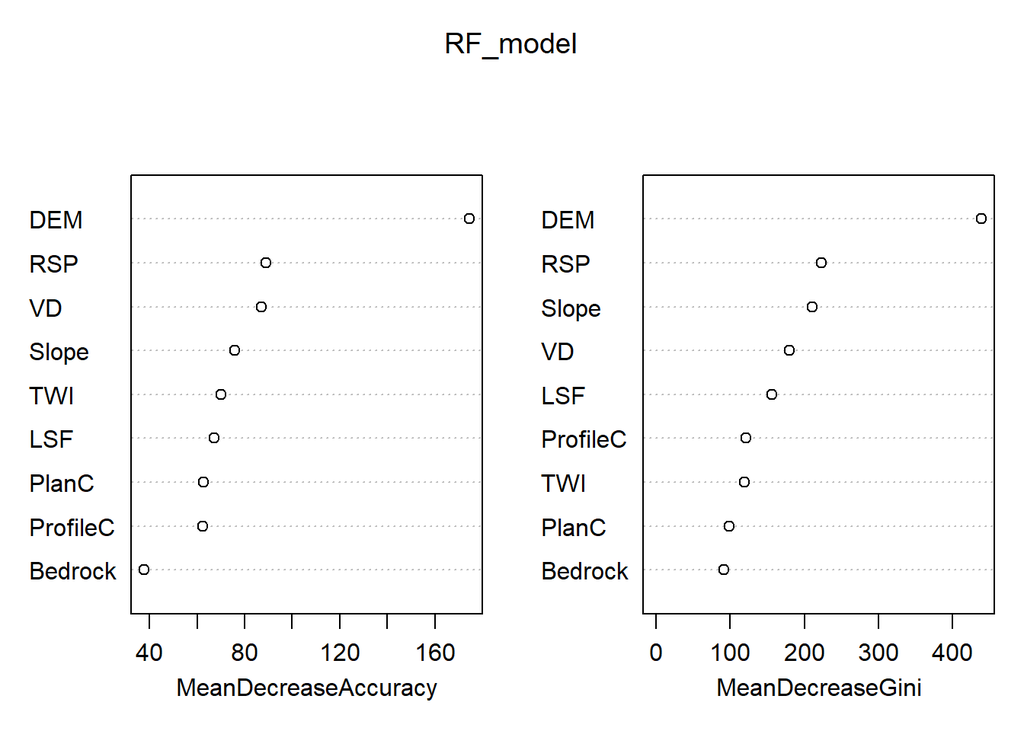

```r
sampleNum_dict[mn]<-nrow(sampData)

sampData$Bedrock<- droplevels(as.factor(sampData$Bedrock))
sampData$soilID<- droplevels(as.factor(sampData$soilID))

RF_model<-randomForest(soilID ~.,data = sampData,
                       importance = TRUE, proximity = FALSE,
                       ntree=1000,type="classification")

varImpPlot(RF_model)
```

```r
print(RF_model)
```

```
##
## Call:
##  randomForest(formula = soilID ~ ., data = sampData, importance = TRUE,      proximity = FALSE, ntree = 1000, type = "classification")
##                Type of random forest: classification
##                      Number of trees: 1000
## No. of variables tried at each split: 3
##
##         OOB estimate of  error rate: 21.79%
## Confusion matrix:
##     1  20 21  23  3 30 31 501 502 503   7 class.error
## 1   8   0  0   0  2  0  0   0   0   0   0  0.20000000
## 20  0 203 22   0  0  0  0   2   0  39  28  0.30952381
## 21  0  44 51   0  0  0  0   1   2   5   1  0.50961538
## 23  0   0  0 140  0 13  6   0   0  25   9  0.27461140
## 3   2   0  0   0 77  0  0  20   0   0   0  0.22222222
## 30  0   0  0  13  0 45  4   0   0   0   1  0.28571429
## 31  0   0  0  11  0  3 69   0   0   0   0  0.16867470
## 501 0   3  0   0 14  0  0 289   1   0   6  0.07667732
## 502 0   5  1   0  1  0  0   1  27   0   3  0.28947368
## 503 0  36  4  15  0  0  0   0   0 384  10  0.14476615
## 7   0  22  1   5  0  3  0  15   2  17 207  0.23897059
```

```r
map_RF <- predict(covStack, RF_model, paste(result_tif_folder,mn,".tif",sep=""),
                  format = "GTiff", datatype = "FLT4S", overwrite = TRUE)

rm("mn","shpPoint","sampData","RF_model","map_RF")
```

SNA TWI ns3 45

```r
mn="All_pSNA_TWI_NS3_pen45"

shpPoint<-readOGR(paste(point_shp_folder,mn,".shp",sep = "")) ###
sampData <- extract(covStack, shpPoint, sp = TRUE,method = "simple")

sampData<-sampData@data

sampData<-sampData[sampData$soilID %in% soil_type,]

sampData<-na.omit(sampData)

print(dim(sampData))
```

```
## [1] 2857   10
```

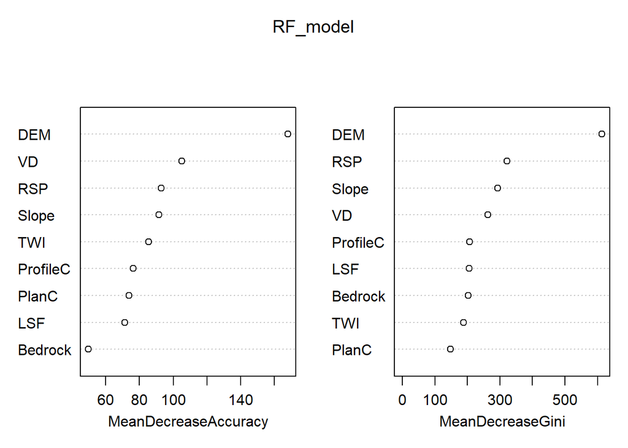

```r
sampleNum_dict[mn]<-nrow(sampData)

sampData$Bedrock<- droplevels(as.factor(sampData$Bedrock))
sampData$soilID<- droplevels(as.factor(sampData$soilID))

RF_model<-randomForest(soilID ~.,data = sampData,
                       importance = TRUE, proximity = FALSE,
                       ntree=1000,type="classification")

varImpPlot(RF_model)
```

```r
print(RF_model)
```

```
##
## Call:
##  randomForest(formula = soilID ~ ., data = sampData, importance = TRUE,      proximity = FALSE, ntree = 1000, type = "classification")
##                Type of random forest: classification
##                      Number of trees: 1000
## No. of variables tried at each split: 3
##
##         OOB estimate of  error rate: 20.41%
## Confusion matrix:
##      1  20 21  23   3 30  31 501 502 503   7 class.error
## 1   13   0  0   0   3  0   0   0   0   0   0   0.1875000
## 20   0 278 32   2   0  0   0   3   3  72  46   0.3623853
## 21   0  51 90   0   0  0   0   0   3  11   1   0.4230769
## 23   0   0  0 239   0 10  10   0   0  23   4   0.1643357
## 3    3   0  0   0 104  0   0  40   0   0   0   0.2925170
## 30   0   0  0  13   0 69   3   0   0   0   6   0.2417582
## 31   0   0  0  12   0  4 108   0   0   0   0   0.1290323
## 501  0   3  0   0  31  0   0 413   1   0  21   0.1194030
## 502  0   1  0   0   0  0   0   2  43   1   7   0.2037037
## 503  0  53  7  27   0  2   0   0   0 574   9   0.1458333
## 7    0  21  1   1   0  3   0  18   3  16 343   0.1551724
```

```r
map_RF <- predict(covStack, RF_model, paste(result_tif_folder,mn,".tif",sep=""),
                  format = "GTiff", datatype = "FLT4S", overwrite = TRUE)

rm("mn","shpPoint","sampData","RF_model","map_RF")
```

RAN TWI ns3 45

```r
mn="All_pRAN_TWI_NS3_pen45"

shpPoint<-readOGR(paste(point_shp_folder,mn,".shp",sep = "")) ###
sampData <- extract(covStack, shpPoint, sp = TRUE,method = "simple")

sampData<-sampData@data

sampData<-sampData[sampData$soilID %in% soil_type,]

sampData<-na.omit(sampData)

print(dim(sampData))
```

```
## [1] 2855   10
```

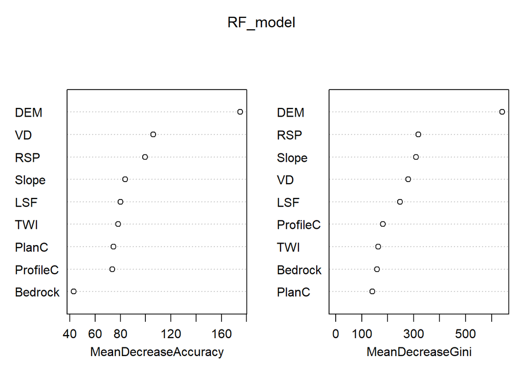

```r
sampleNum_dict[mn]<-nrow(sampData)

sampData$Bedrock<- droplevels(as.factor(sampData$Bedrock))
sampData$soilID<- droplevels(as.factor(sampData$soilID))

RF_model<-randomForest(soilID ~.,data = sampData,
                       importance = TRUE, proximity = FALSE,
                       ntree=1000,type="classification")

varImpPlot(RF_model)
```

```r
print(RF_model)
```

```
##
## Call:
##  randomForest(formula = soilID ~ ., data = sampData, importance = TRUE,      proximity = FALSE, ntree = 1000, type = "classification")
##                Type of random forest: classification
##                      Number of trees: 1000
## No. of variables tried at each split: 3
##
##         OOB estimate of  error rate: 19.33%
## Confusion matrix:
##      1  20 21  23   3 30  31 501 502 503   7 class.error
## 1   13   0  0   0   1  0   0   0   0   0   0  0.07142857
## 20   0 303 35   1   0  0   0   3   2  65  27  0.30504587
## 21   0  51 97   0   0  0   0   0   1   6   1  0.37820513
## 23   0   0  0 210   0 19  10   0   0  37  10  0.26573427
## 3    1   0  0   0 119  0   0  27   0   0   0  0.19047619
## 30   0   0  0  20   0 63   4   0   0   0   4  0.30769231
## 31   0   0  0  15   0  5 104   0   0   0   0  0.16129032
## 501  0   3  0   0  15  0   0 440   0   0  11  0.06183369
## 502  0   1  0   0   0  0   0   0  50   2   1  0.07407407
## 503  0  56  3  29   0  1   0   0   1 570  12  0.15178571
## 7    0  27  0   8   0  3   0  11   3  20 334  0.17733990
```

```r
map_RF <- predict(covStack, RF_model, paste(result_tif_folder,mn,".tif",sep=""),
                  format = "GTiff", datatype = "FLT4S", overwrite = TRUE)

rm("mn","shpPoint","sampData","RF_model","map_RF")
```

SNA TWI ns3 60

```r
mn="All_pSNA_TWI_NS3_pen60"

shpPoint<-readOGR(paste(point_shp_folder,mn,".shp",sep = "")) ###
sampData <- extract(covStack, shpPoint, sp = TRUE,method = "simple")

sampData<-sampData@data

sampData<-sampData[sampData$soilID %in% soil_type,]

sampData<-na.omit(sampData)

print(dim(sampData))
```

```
## [1] 3799   10
```

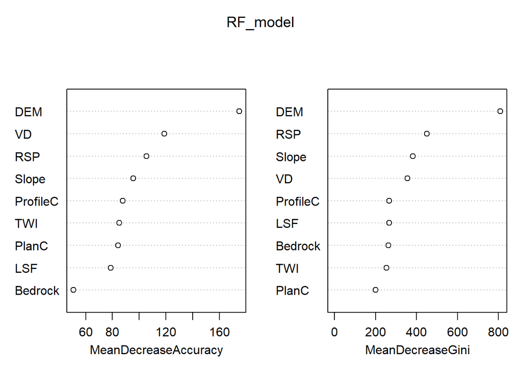

```r
sampleNum_dict[mn]<-nrow(sampData)

sampData$Bedrock<- droplevels(as.factor(sampData$Bedrock))
sampData$soilID<- droplevels(as.factor(sampData$soilID))

RF_model<-randomForest(soilID ~.,data = sampData,
                       importance = TRUE, proximity = FALSE,
                       ntree=1000,type="classification")

varImpPlot(RF_model)
```

```r
print(RF_model)
```

```
##
## Call:
##  randomForest(formula = soilID ~ ., data = sampData, importance = TRUE,      proximity = FALSE, ntree = 1000, type = "classification")
##                Type of random forest: classification
##                      Number of trees: 1000
## No. of variables tried at each split: 3
##
##         OOB estimate of  error rate: 19.64%
## Confusion matrix:
##      1  20  21  23   3 30  31 501 502 503   7 class.error
## 1   16   0   0   0   5  0   0   0   0   0   0   0.2380952
## 20   0 383  40   2   0  0   0   5   4  93  53   0.3396552
## 21   0  69 119   0   0  0   0   1   1  15   1   0.4223301
## 23   0   1   0 310   0 16   9   0   0  36   7   0.1820580
## 3    4   0   0   0 140  0   0  52   0   0   0   0.2857143
## 30   0   2   0  15   0 95   5   0   0   2   3   0.2213115
## 31   0   0   0  11   0  6 147   0   0   1   0   0.1090909
## 501  0   1   0   0  34  0   0 559   1   0  30   0.1056000
## 502  0   1   1   0   0  0   0   2  57   2   9   0.2083333
## 503  0  63   6  35   0  2   0   0   1 771  15   0.1366181
## 7    0  27   2   1   0  5   0  24   6  19 456   0.1555556
```

```r
map_RF <- predict(covStack, RF_model, paste(result_tif_folder,mn,".tif",sep=""),
                  format = "GTiff", datatype = "FLT4S", overwrite = TRUE)

rm("mn","shpPoint","sampData","RF_model","map_RF")
```

RAN TWI ns3 60

```r
mn="All_pRAN_TWI_NS3_pen60"

shpPoint<-readOGR(paste(point_shp_folder,mn,".shp",sep = "")) ###
sampData <- extract(covStack, shpPoint, sp = TRUE,method = "simple")

sampData<-sampData@data

sampData<-sampData[sampData$soilID %in% soil_type,]

sampData<-na.omit(sampData)

print(dim(sampData))
```

```
## [1] 3796   10
```

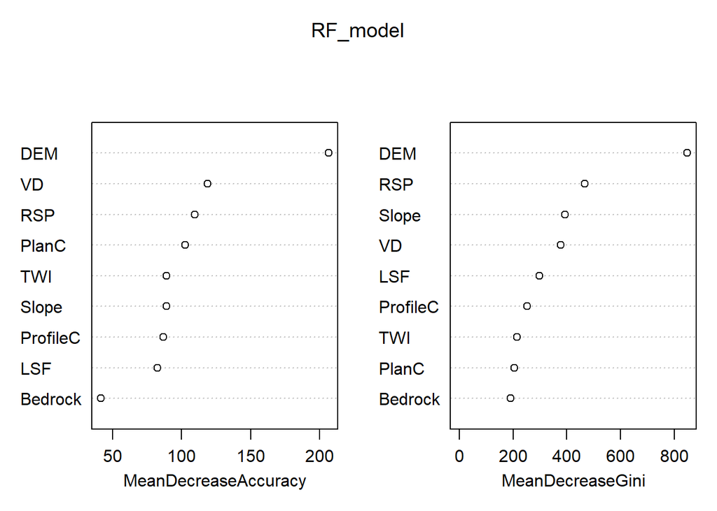

```r
sampleNum_dict[mn]<-nrow(sampData)

sampData$Bedrock<- droplevels(as.factor(sampData$Bedrock))
sampData$soilID<- droplevels(as.factor(sampData$soilID))

RF_model<-randomForest(soilID ~.,data = sampData,
                       importance = TRUE, proximity = FALSE,
                       ntree=1000,type="classification")

varImpPlot(RF_model)
```

```r
print(RF_model)
```

```
##
## Call:
##  randomForest(formula = soilID ~ ., data = sampData, importance = TRUE,      proximity = FALSE, ntree = 1000, type = "classification")
##                Type of random forest: classification
##                      Number of trees: 1000
## No. of variables tried at each split: 3
##
##         OOB estimate of  error rate: 17.1%
## Confusion matrix:
##      1  20  21  23   3 30  31 501 502 503   7 class.error
## 1   15   0   0   0   3  0   0   0   0   0   0   0.1666667
## 20   0 425  27   0   0  0   0   5   1  84  38   0.2672414
## 21   0  67 129   0   0  0   0   0   1   7   2   0.3737864
## 23   0   0   0 303   0 17  10   0   0  35  14   0.2005277
## 3    2   0   0   0 155  0   0  39   0   0   0   0.2091837
## 30   0   0   0  18   0 97   5   0   0   0   2   0.2049180
## 31   0   0   0  16   0  4 145   0   0   0   0   0.1212121
## 501  0   5   0   0  26  0   0 581   2   0  11   0.0704000
## 502  0   7   0   0   0  0   0   0  61   0   4   0.1527778
## 503  0  62   5  27   0  0   0   0   0 780  19   0.1265398
## 7    0  29   0   4   0  2   0  21   6  22 456   0.1555556
```

```r
map_RF <- predict(covStack, RF_model, paste(result_tif_folder,mn,".tif",sep=""),
                  format = "GTiff", datatype = "FLT4S", overwrite = TRUE)

rm("mn","shpPoint","sampData","RF_model","map_RF")
```

SNA TWI ns3 75

```r
mn="All_pSNA_TWI_NS3_pen75"

shpPoint<-readOGR(paste(point_shp_folder,mn,".shp",sep = "")) ###
sampData <- extract(covStack, shpPoint, sp = TRUE,method = "simple")

sampData<-sampData@data

sampData<-sampData[sampData$soilID %in% soil_type,]

sampData<-na.omit(sampData)

print(dim(sampData))
```

```
## [1] 4743   10
```

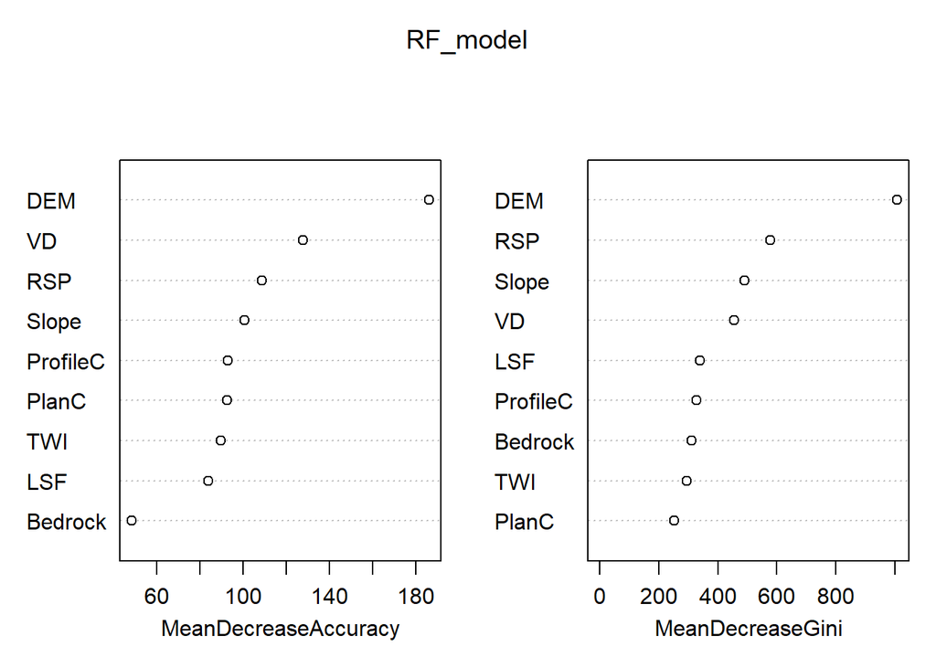

```r
sampleNum_dict[mn]<-nrow(sampData)

sampData$Bedrock<- droplevels(as.factor(sampData$Bedrock))
sampData$soilID<- droplevels(as.factor(sampData$soilID))

RF_model<-randomForest(soilID ~.,data = sampData,
                       importance = TRUE, proximity = FALSE,
                       ntree=1000,type="classification")

varImpPlot(RF_model)
```

```r
print(RF_model)
```

```
##
## Call:
##  randomForest(formula = soilID ~ ., data = sampData, importance = TRUE,      proximity = FALSE, ntree = 1000, type = "classification")
##                Type of random forest: classification
##                      Number of trees: 1000
## No. of variables tried at each split: 3
##
##         OOB estimate of  error rate: 19.95%
## Confusion matrix:
##      1  20  21  23   3  30  31 501 502 503   7 class.error
## 1   21   0   0   0   5   0   0   0   0   0   0  0.19230769
## 20   0 482  45   1   0   0   0   8   2 124  62  0.33425414
## 21   0  85 153   0   0   0   0   1   1  17   1  0.40697674
## 23   0   1   0 377   0  23   8   0   0  52  11  0.20127119
## 3    3   0   0   0 176   0   0  66   0   0   0  0.28163265
## 30   0   1   0  21   0 113   9   0   0   2   5  0.25165563
## 31   0   0   0  20   0   7 179   0   0   0   0  0.13106796
## 501  0   4   0   0  45   0   0 706   1   0  25  0.09603073
## 502  0   3   3   0   0   0   0   2  71   1  10  0.21111111
## 503  0  94   6  40   0   4   0   0   1 954  18  0.14592659
## 7    0  38   1   1   0   7   0  32   5  24 565  0.16047548
```

```r
map_RF <- predict(covStack, RF_model, paste(result_tif_folder,mn,".tif",sep=""),
                  format = "GTiff", datatype = "FLT4S", overwrite = TRUE)

rm("mn","shpPoint","sampData","RF_model","map_RF")
```

RAN TWI ns3 75

```r
mn="All_pRAN_TWI_NS3_pen75"

shpPoint<-readOGR(paste(point_shp_folder,mn,".shp",sep = "")) ###
sampData <- extract(covStack, shpPoint, sp = TRUE,method = "simple")

sampData<-sampData@data

sampData<-sampData[sampData$soilID %in% soil_type,]

sampData<-na.omit(sampData)

print(dim(sampData))
```

```
## [1] 4740   10
```

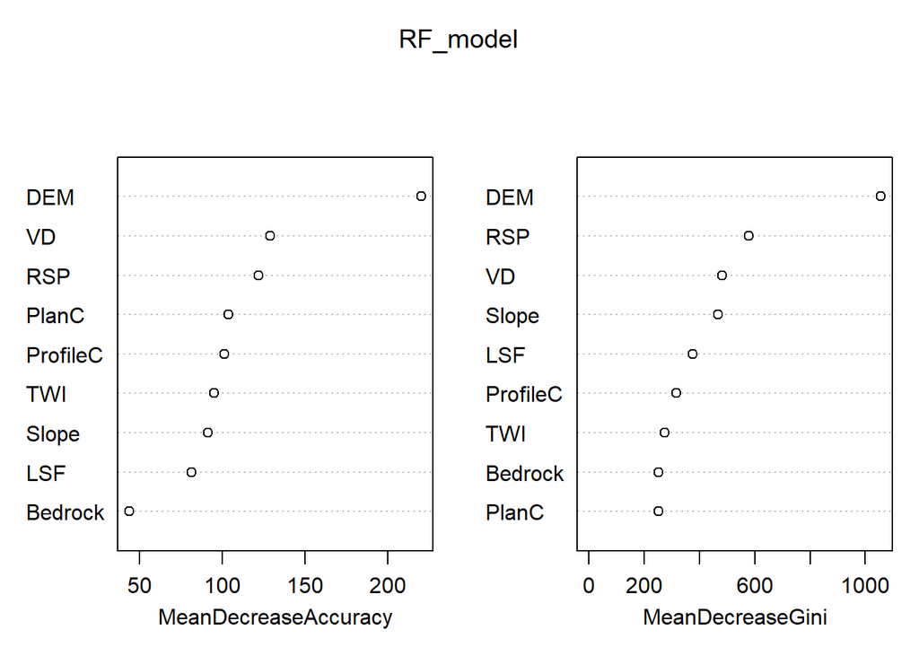

```r
sampleNum_dict[mn]<-nrow(sampData)

sampData$Bedrock<- droplevels(as.factor(sampData$Bedrock))
sampData$soilID<- droplevels(as.factor(sampData$soilID))

RF_model<-randomForest(soilID ~.,data = sampData,
                       importance = TRUE, proximity = FALSE,
                       ntree=1000,type="classification")

varImpPlot(RF_model)
```

```r
print(RF_model)
```

```
##
## Call:
##  randomForest(formula = soilID ~ ., data = sampData, importance = TRUE,      proximity = FALSE, ntree = 1000, type = "classification")
##                Type of random forest: classification
##                      Number of trees: 1000
## No. of variables tried at each split: 3
##
##         OOB estimate of  error rate: 16.6%
## Confusion matrix:
##      1  20  21  23   3  30  31 501 502 503   7 class.error
## 1   19   0   0   0   4   0   0   0   0   0   0  0.17391304
## 20   0 536  43   1   0   0   0   6   2  98  38  0.25966851
## 21   0  84 162   0   0   0   0   1   1  10   0  0.37209302
## 23   0   1   0 385   0  18   8   0   0  46  14  0.18432203
## 3    2   0   0   0 194   0   0  49   0   0   0  0.20816327
## 30   0   0   0  28   0 114   5   0   0   0   4  0.24503311
## 31   0   0   0  21   0   4 180   0   0   1   0  0.12621359
## 501  0   8   0   0  33   0   0 726   1   0  13  0.07042254
## 502  0   6   0   0   0   0   0   2  76   1   5  0.15555556
## 503  0  62   3  34   0   2   0   0   0 984  32  0.11906893
## 7    0  32   0   4   0   1   0  30   4  25 577  0.14264487
```

```r
map_RF <- predict(covStack, RF_model, paste(result_tif_folder,mn,".tif",sep=""),
                  format = "GTiff", datatype = "FLT4S", overwrite = TRUE)

rm("mn","shpPoint","sampData","RF_model","map_RF")
```

SNA TWI ns5 15

```r
mn="All_pSNA_TWI_NS5_pen15"

shpPoint<-readOGR(paste(point_shp_folder,mn,".shp",sep = "")) ###
sampData <- extract(covStack, shpPoint, sp = TRUE,method = "simple")

sampData<-sampData@data

sampData<-sampData[sampData$soilID %in% soil_type,]

sampData<-na.omit(sampData)

print(dim(sampData))
```

```
## [1] 337  10
```

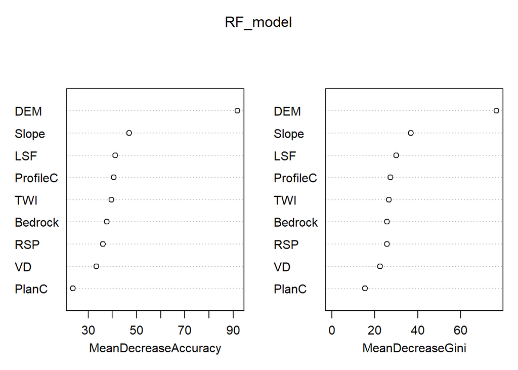

```r
sampleNum_dict[mn]<-nrow(sampData)

sampData$Bedrock<- droplevels(as.factor(sampData$Bedrock))
sampData$soilID<- droplevels(as.factor(sampData$soilID))

RF_model<-randomForest(soilID ~.,data = sampData,
                       importance = TRUE, proximity = FALSE,
                       ntree=1000,type="classification")

varImpPlot(RF_model)
```

```r
print(RF_model)
```

```
##
## Call:
##  randomForest(formula = soilID ~ ., data = sampData, importance = TRUE,      proximity = FALSE, ntree = 1000, type = "classification")
##                Type of random forest: classification
##                      Number of trees: 1000
## No. of variables tried at each split: 3
##
##         OOB estimate of  error rate: 20.77%
## Confusion matrix:
##     1 20 21 23  3 30 31 501 502 503  7 class.error
## 1   2  0  0  0  0  0  0   0   0   0  0  0.00000000
## 20  0 24  4  0  0  0  0   0   0  11  5  0.45454545
## 21  0  5 15  1  0  0  0   0   0   1  0  0.31818182
## 23  0  0  0 23  0  3  0   0   0   3  0  0.20689655
## 3   0  0  0  0 11  0  0   6   0   0  0  0.35294118
## 30  0  0  0  3  0  3  2   0   0   0  1  0.66666667
## 31  0  0  0  0  0  1 13   0   0   0  0  0.07142857
## 501 0  0  0  0  4  0  0  54   0   0  1  0.08474576
## 502 0  1  0  0  0  0  0   2   4   0  0  0.42857143
## 503 0  3  1  2  0  0  0   0   0  74  1  0.08641975
## 7   0  4  1  1  0  0  0   1   0   2 44  0.16981132
```

```r
map_RF <- predict(covStack, RF_model, paste(result_tif_folder,mn,".tif",sep=""),
                  format = "GTiff", datatype = "FLT4S", overwrite = TRUE)

rm("mn","shpPoint","sampData","RF_model","map_RF")
```

RAN TWI ns5 15

```r
mn="All_pRAN_TWI_NS5_pen15"

shpPoint<-readOGR(paste(point_shp_folder,mn,".shp",sep = "")) ###
sampData <- extract(covStack, shpPoint, sp = TRUE,method = "simple")

sampData<-sampData@data

sampData<-sampData[sampData$soilID %in% soil_type,]

sampData<-na.omit(sampData)

print(dim(sampData))
```

```
## [1] 337  10
```

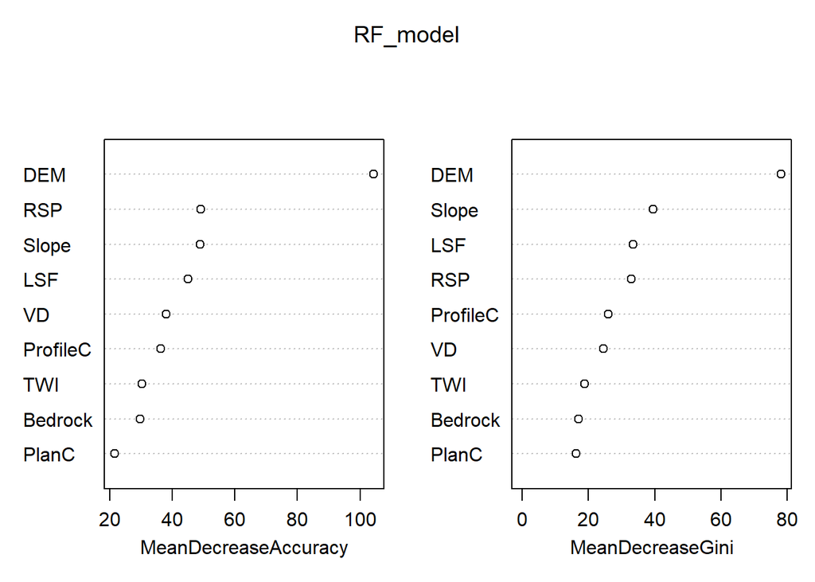

```r
sampleNum_dict[mn]<-nrow(sampData)

sampData$Bedrock<- droplevels(as.factor(sampData$Bedrock))
sampData$soilID<- droplevels(as.factor(sampData$soilID))

RF_model<-randomForest(soilID ~.,data = sampData,
                       importance = TRUE, proximity = FALSE,
                       ntree=1000,type="classification")

varImpPlot(RF_model)
```

```r
print(RF_model)
```

```
##
## Call:
##  randomForest(formula = soilID ~ ., data = sampData, importance = TRUE,      proximity = FALSE, ntree = 1000, type = "classification")
##                Type of random forest: classification
##                      Number of trees: 1000
## No. of variables tried at each split: 3
##
##         OOB estimate of  error rate: 23.44%
## Confusion matrix:
##     1 20 21 23  3 30 31 501 502 503  7 class.error
## 1   1  0  0  0  1  0  0   0   0   0  0  0.50000000
## 20  0 26  6  0  0  0  0   1   1   2  8  0.40909091
## 21  0  8 13  0  0  0  0   0   0   1  0  0.40909091
## 23  0  0  0 22  0  2  1   0   0   3  1  0.24137931
## 3   0  0  0  0 11  0  0   5   1   0  0  0.35294118
## 30  0  0  0  3  0  4  1   0   0   0  1  0.55555556
## 31  0  0  0  1  0  0 13   0   0   0  0  0.07142857
## 501 0  0  0  0  5  0  0  53   0   0  1  0.10169492
## 502 0  2  1  0  1  0  0   1   2   0  0  0.71428571
## 503 0  2  1  6  0  0  0   0   0  69  3  0.14814815
## 7   0  7  0  0  0  0  0   0   0   2 44  0.16981132
```

```r
map_RF <- predict(covStack, RF_model, paste(result_tif_folder,mn,".tif",sep=""),
                  format = "GTiff", datatype = "FLT4S", overwrite = TRUE)

rm("mn","shpPoint","sampData","RF_model","map_RF")
```

SNA TWI ns5 30

```r
mn="All_pSNA_TWI_NS5_pen30"

shpPoint<-readOGR(paste(point_shp_folder,mn,".shp",sep = "")) ###
sampData <- extract(covStack, shpPoint, sp = TRUE,method = "simple")

sampData<-sampData@data

sampData<-sampData[sampData$soilID %in% soil_type,]

sampData<-na.omit(sampData)

print(dim(sampData))
```

```
## [1] 634  10
```

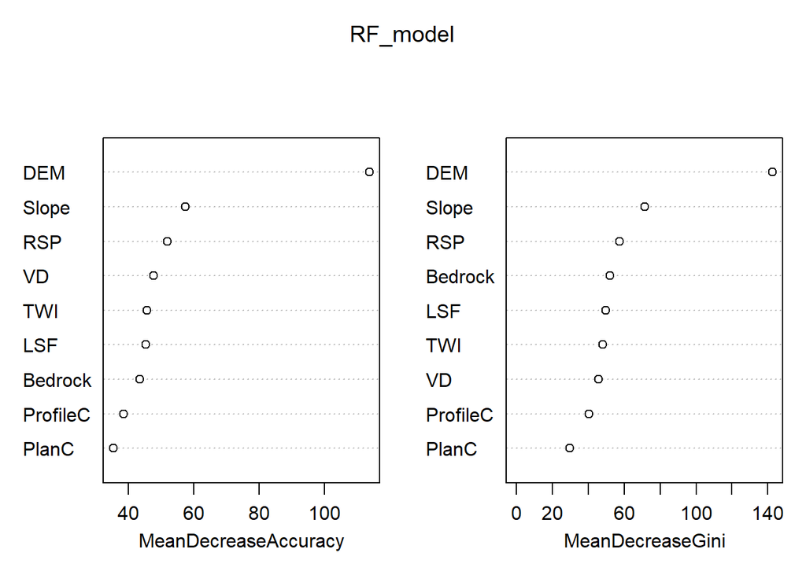

```r
sampleNum_dict[mn]<-nrow(sampData)

sampData$Bedrock<- droplevels(as.factor(sampData$Bedrock))
sampData$soilID<- droplevels(as.factor(sampData$soilID))

RF_model<-randomForest(soilID ~.,data = sampData,
                       importance = TRUE, proximity = FALSE,
                       ntree=1000,type="classification")

varImpPlot(RF_model)
```

```r
print(RF_model)
```

```
##
## Call:
##  randomForest(formula = soilID ~ ., data = sampData, importance = TRUE,      proximity = FALSE, ntree = 1000, type = "classification")
##                Type of random forest: classification
##                      Number of trees: 1000
## No. of variables tried at each split: 3
##
##         OOB estimate of  error rate: 22.24%
## Confusion matrix:
##     1 20 21 23  3 30 31 501 502 503  7 class.error
## 1   3  0  0  0  1  0  0   0   0   0  0   0.2500000
## 20  0 43 10  0  0  0  0   0   0  16 13   0.4756098
## 21  0 10 19  0  0  0  0   0   1   2  0   0.4062500
## 23  0  0  0 44  0  3  1   0   0   6  0   0.1851852
## 3   1  0  0  0 18  0  0  15   0   0  0   0.4705882
## 30  0  0  0  3  0  7  3   0   0   0  2   0.5333333
## 31  0  0  0  2  0  3 22   0   0   1  0   0.2142857
## 501 0  0  0  0 10  0  0 105   0   0  2   0.1025641
## 502 0  0  0  0  0  0  0   2  10   0  2   0.2857143
## 503 0  7  2  7  0  0  0   0   0 136  3   0.1225806
## 7   0  7  1  0  0  0  0   3   0   2 86   0.1313131
```

```r
map_RF <- predict(covStack, RF_model, paste(result_tif_folder,mn,".tif",sep=""),
                  format = "GTiff", datatype = "FLT4S", overwrite = TRUE)

rm("mn","shpPoint","sampData","RF_model","map_RF")
```

RAN TWI ns5 30

```r
mn="All_pRAN_TWI_NS5_pen30"

shpPoint<-readOGR(paste(point_shp_folder,mn,".shp",sep = "")) ###
sampData <- extract(covStack, shpPoint, sp = TRUE,method = "simple")

sampData<-sampData@data

sampData<-sampData[sampData$soilID %in% soil_type,]

sampData<-na.omit(sampData)

print(dim(sampData))
```

```
## [1] 634  10
```

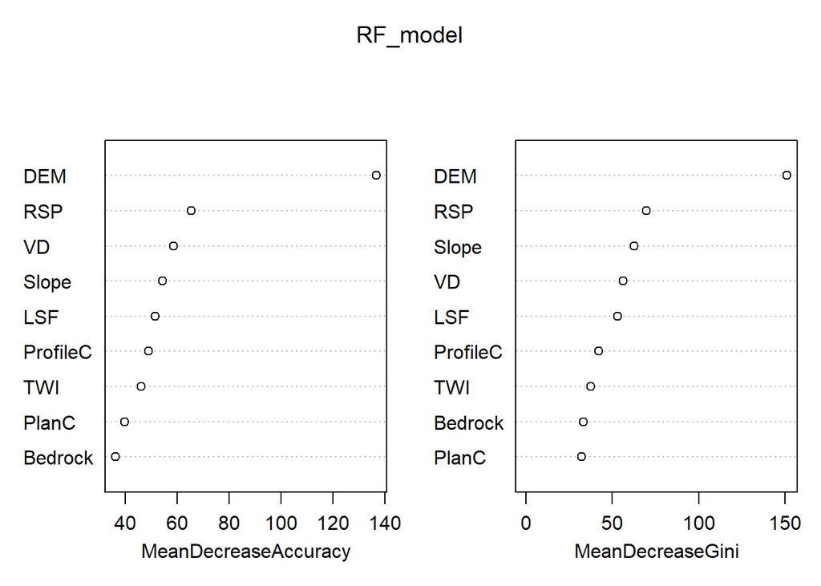

```r
sampleNum_dict[mn]<-nrow(sampData)

sampData$Bedrock<- droplevels(as.factor(sampData$Bedrock))
sampData$soilID<- droplevels(as.factor(sampData$soilID))

RF_model<-randomForest(soilID ~.,data = sampData,
                       importance = TRUE, proximity = FALSE,
                       ntree=1000,type="classification")

varImpPlot(RF_model)
```

```r
print(RF_model)
```

```
##
## Call:
##  randomForest(formula = soilID ~ ., data = sampData, importance = TRUE,      proximity = FALSE, ntree = 1000, type = "classification")
##                Type of random forest: classification
##                      Number of trees: 1000
## No. of variables tried at each split: 3
##
##         OOB estimate of  error rate: 18.61%
## Confusion matrix:
##     1 20 21 23  3 30 31 501 502 503  7 class.error
## 1   2  0  0  0  2  0  0   0   0   0  0  0.50000000
## 20  0 58  5  0  0  0  0   2   0  11  6  0.29268293
## 21  0 15 16  0  0  0  0   0   0   1  0  0.50000000
## 23  0  0  0 39  0  3  3   0   0   7  2  0.27777778
## 3   1  0  0  0 28  0  0   5   0   0  0  0.17647059
## 30  0  0  0  4  0  9  1   0   0   0  1  0.40000000
## 31  0  0  0  5  0  0 22   0   0   1  0  0.21428571
## 501 0  2  0  0  8  0  0 105   1   0  1  0.10256410
## 502 0  2  0  0  0  0  0   1  10   0  1  0.28571429
## 503 0  6  1  4  0  0  0   0   0 142  2  0.08387097
## 7   0  6  0  0  0  1  0   1   0   6 85  0.14141414
```

```r
map_RF <- predict(covStack, RF_model, paste(result_tif_folder,mn,".tif",sep=""),
                  format = "GTiff", datatype = "FLT4S", overwrite = TRUE)

rm("mn","shpPoint","sampData","RF_model","map_RF")
```

SNA TWI ns5 45

```r
mn="All_pSNA_TWI_NS5_pen45"

shpPoint<-readOGR(paste(point_shp_folder,mn,".shp",sep = "")) ###
sampData <- extract(covStack, shpPoint, sp = TRUE,method = "simple")

sampData<-sampData@data

sampData<-sampData[sampData$soilID %in% soil_type,]

sampData<-na.omit(sampData)

print(dim(sampData))
```

```
## [1] 934  10
```

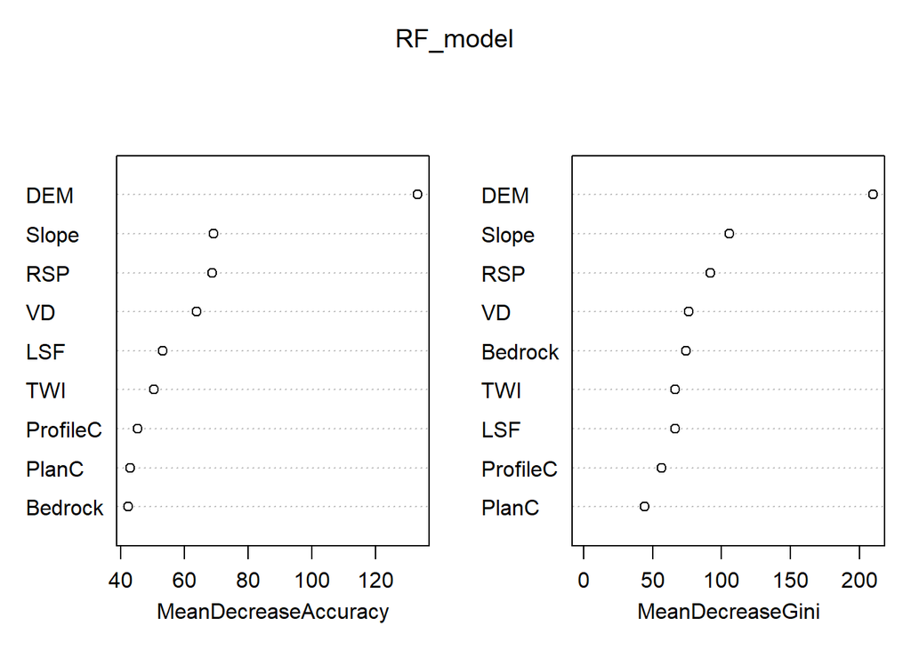

```r
sampleNum_dict[mn]<-nrow(sampData)

sampData$Bedrock<- droplevels(as.factor(sampData$Bedrock))
sampData$soilID<- droplevels(as.factor(sampData$soilID))

RF_model<-randomForest(soilID ~.,data = sampData,
                       importance = TRUE, proximity = FALSE,
                       ntree=1000,type="classification")

varImpPlot(RF_model)
```

```r
print(RF_model)
```

```
##
## Call:
##  randomForest(formula = soilID ~ ., data = sampData, importance = TRUE,      proximity = FALSE, ntree = 1000, type = "classification")
##                Type of random forest: classification
##                      Number of trees: 1000
## No. of variables tried at each split: 3
##
##         OOB estimate of  error rate: 20.02%
## Confusion matrix:
##     1 20 21 23  3 30 31 501 502 503   7 class.error
## 1   5  0  0  0  1  0  0   0   0   0   0   0.1666667
## 20  0 64 14  0  0  0  0   1   1  20  18   0.4576271
## 21  0 18 26  0  0  0  0   0   0   1   0   0.4222222
## 23  0  0  0 65  0  2  5   0   0   9   0   0.1975309
## 3   1  0  0  0 34  0  0  15   0   0   0   0.3200000
## 30  0  0  0  3  0 14  4   0   0   0   1   0.3636364
## 31  0  0  0  3  0  3 35   0   0   1   0   0.1666667
## 501 0  0  0  0 19  0  0 152   0   0   4   0.1314286
## 502 0  0  0  0  0  0  0   2  14   0   3   0.2631579
## 503 0  9  2  8  0  0  0   0   0 209   3   0.0952381
## 7   0  8  1  0  0  0  0   3   0   4 129   0.1103448
```

```r
map_RF <- predict(covStack, RF_model, paste(result_tif_folder,mn,".tif",sep=""),
                  format = "GTiff", datatype = "FLT4S", overwrite = TRUE)

rm("mn","shpPoint","sampData","RF_model","map_RF")
```

RAN TWI ns5 45

```r
mn="All_pRAN_TWI_NS5_pen45"

shpPoint<-readOGR(paste(point_shp_folder,mn,".shp",sep = "")) ###
sampData <- extract(covStack, shpPoint, sp = TRUE,method = "simple")

sampData<-sampData@data

sampData<-sampData[sampData$soilID %in% soil_type,]

sampData<-na.omit(sampData)

print(dim(sampData))
```

```
## [1] 934  10
```

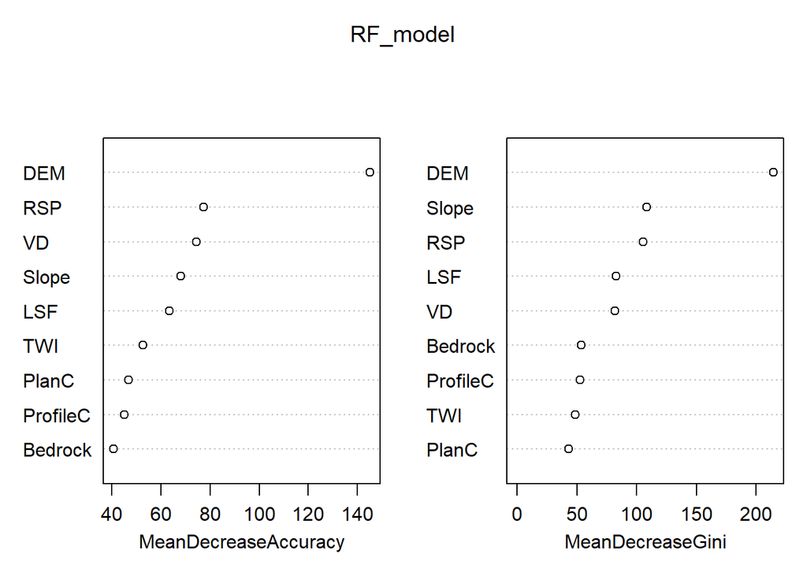

```r
sampleNum_dict[mn]<-nrow(sampData)

sampData$Bedrock<- droplevels(as.factor(sampData$Bedrock))
sampData$soilID<- droplevels(as.factor(sampData$soilID))

RF_model<-randomForest(soilID ~.,data = sampData,
                       importance = TRUE, proximity = FALSE,
                       ntree=1000,type="classification")

varImpPlot(RF_model)
```

```r
print(RF_model)
```

```
##
## Call:
##  randomForest(formula = soilID ~ ., data = sampData, importance = TRUE,      proximity = FALSE, ntree = 1000, type = "classification")
##                Type of random forest: classification
##                      Number of trees: 1000
## No. of variables tried at each split: 3
##
##         OOB estimate of  error rate: 16.49%
## Confusion matrix:
##     1 20 21 23  3 30 31 501 502 503   7 class.error
## 1   5  0  0  0  1  0  0   0   0   0   0  0.16666667
## 20  0 79 10  0  0  0  0   1   1  13  14  0.33050847
## 21  0 16 28  0  0  0  0   0   0   1   0  0.37777778
## 23  0  0  0 62  0  5  2   0   0   9   3  0.23456790
## 3   0  0  0  0 41  0  0   9   0   0   0  0.18000000
## 30  0  0  0  7  0 12  1   0   0   0   2  0.45454545
## 31  0  0  0  0  0  1 41   0   0   0   0  0.02380952
## 501 0  1  0  0  5  0  0 165   0   0   4  0.05714286
## 502 0  2  0  0  0  0  0   3  13   0   1  0.31578947
## 503 0  6  0  7  0  0  0   0   0 215   3  0.06926407
## 7   0  8  0  1  0  1  0   6   1   9 119  0.17931034
```